# Hubungan Faktor Risiko Klinis dan Indeks Kardiometabolik terhadap Kerentanan Plak dan Beban Kalsifikasi Koroner pada Pasien Diabetes Mellitus Tipe 2

Penulis

Afiliasi

Kadek Adit Wiryadana; Made Ratna Saraswati

RSUP Ngoerah

Diterbitkan

25 September 2026, 11:46

Abstrak

**Latar Belakang:** Penyakit kardiovaskular adalah komplikasi utama *Diabetes Mellitus* (DM). Penelitian ini bertujuan mengevaluasi asosiasi faktor risiko konvensional dan indeks kardiometabolik turunan dengan kerentanan *High-Risk Plaque* (HRP) dan keparahan kalsifikasi arteri koroner (CAC) pada pasien DM.

**Metode:** Studi potong lintang mengevaluasi pasien DM yang menjalani *Computed Tomography Coronary Angiography* (CTCA) di RSUP Ngoerah pada tahun 2025. Profil klinis (usia, jenis kelamin, pengobatan, kreatinin, profil lipid, HbA1c) dan indeks kardiometabolik turunan (Indeks TyHbA1c, Rasio TG/HDL, Kolesterol Non-HDL, Rasio SUA/HDL) dianalisis menggunakan komparasi bivariat untuk status HRP dan korelasi linear untuk skor CAC.

**Hasil:** Sampel penelitian berjumlah 52 pasien, 30,8% merupakan pasien baru terdiagnosis DM. Pada kasus DM lama (69,2%), terapi yang diterima meliputi antidiabetik oral (32,7%), regimen insulin (32,7%), dan tanpa pengobatan (3,8%). Sebagian besar pasien (71,2%) menerima terapi statin dan dirujuk karena riwayat kejadian kardiovaskular sebelumnya. HRP teridentifikasi pada 71,2% pasien. Kelompok HRP-positif secara signifikan lebih tua (63,16 vs 55,8 tahun, p<0,01) dengan beban CAC yang lebih tinggi (median 556,7 vs 11,6 Agatston, p<0,001). Indeks kardiometabolik turunan tidak menunjukkan diskriminasi yang bermakna terhadap HRP. Sebaliknya, analisis korelasi mengungkapkan asosiasi negatif yang paradoksikal antara indeks turunan lipid dan keparahan CAC. Evaluasi stratifikasi mengindikasikan bahwa anomali ini terutama disetir oleh durasi DM yang panjang dan terapi statin.

**Simpulan:** Usia merupakan determinan utama aterosklerosis koroner pada pasien DM. Hubungan terbalik yang paradoksikal antara indeks kardiometabolik dengan CAC menyoroti efek perancu dari terapi statin, yang menjadikan kadar lipid tampak optimal secara semu pada kasus yang parah sehingga membatasi nilai prediktif klinis mandirinya.

**Abstract**

**Background:** Cardiovascular disease is a major complication of Diabetes Mellitus (DM). This study aims to evaluate the association of conventional risk factors and derivative cardiometabolic indices with High-Risk Plaque (HRP) vulnerability and coronary artery calcification (CAC) severity in DM patients.

**Methods:** A cross-sectional study evaluated DM patients undergoing Computed Tomography Coronary Angiography (CTCA) at RSUP Ngoerah in 2025. Clinical profiles (age, gender, medication, creatinine, lipid profile, HbA1c) and derivative cardiometabolic indices (TyHbA1c Index, TG/HDL Ratio, Non-HDL Cholesterol, SUA/HDL Ratio) were analyzed using bivariate comparisons for HRP status and linear correlations for CAC scores.

**Results:** Among 52 patients, 30.8% were newly diagnosed DM. For known DM cases (69.2%), treatments included oral antidiabetics (32.7%), insulin regimens (32.7%), and no medication (3.8%). Most patients (71.2%) were receiving statin therapy and were referred due to a prior history of cardiac events. HRP was identified in 71.2% of patients. The HRP-positive group was significantly older (63.16 vs. 55.8 years, p<0.01) with higher CAC burdens (median 556.7 vs. 11.6 Agatston, p<0.001). Derivative cardiometabolic indices showed no significant discrimination for HRP. Conversely, correlation analysis revealed a paradoxical negative association between lipid-derived indices and CAC severity. Stratified evaluations indicated this anomaly was primarily driven by prolonged DM duration and statin therapy (statin paradox).

**Conclusion:** Age is the primary determinant of coronary atherosclerosis in DM. The paradoxical inverse relationship of cardiometabolic indices with CAC highlights confounding effects from statin therapy, rendering lipid levels deceptively optimal in severe cases and limiting their standalone predictive clinical value.

Kata kunci

Cardiometabolic Index, Coronary Artery Calcification, Diabetes Mellitus, High-Risk Plaque, Statin Paradox

## 1 Pendahuluan

Penyakit kardiovaskular aterosklerotik (ASCVD) tetap menjadi penyebab utama morbiditas dan mortalitas pada pasien dengan Diabetes Mellitus (DM). Patogenesis aterosklerosis pada populasi DM kompleks dan multifaktorial. Resistensi insulin kronis dan glukolipotoksisitas diakui sebagai faktor utama pemicu disfungsi endotel.<sup>1</sup> Hal ini memicu ketertarikan terhadap berbagai indeks kardiometabolik turunan seperti Indeks TyHbA1c, Rasio Trigliserida terhadap HDL (TG/HDL), Kolesterol Non-HDL, hingga Rasio Asam Urat terhadap HDL (SUA/HDL) sebagai penanda biologis alternatif yang dihipotesiskan mampu merepresentasikan beban patofisiologis secara lebih presisi dibandingkan parameter lipid konvensional.<sup>2,3</sup>

Di sisi lain, proses aterosklerosis tidak hanya dikendalikan oleh fluktuasi faktor metabolik, melainkan juga sangat bergantung pada faktor degeneratif (usia) dan durasi paparan stresor terhadap dinding vaskular.<sup>4</sup> Lebih lanjut, literatur menegaskan bahwa komplikasi fungsi ginjal (Penyakit Ginjal Kronis/PGK) seringkali bertindak sebagai katalisator yang mempercepat progresi kalsifikasi. Kehadiran PGK mampu meningkatkan kerentanan jaringan vaskular melampaui efek parameter lipid atau glikemik saja.<sup>5</sup>

Seiring perkembangan alat diagnostik modern, evaluasi anatomi koroner non-invasif menggunakan *Computed Tomography Coronary Angiography* (CTCA) memungkinkan identifikasi *High-Risk Plaque* (HRP) sebagai prekursor sindrom koroner akut, sekaligus mengkuantifikasi beban kalsifikasi arteri koroner dengan *coronary artery calcification score* (*CAC Score*).<sup>6,7</sup> Kendati berbagai penelitian indeks kardiometabolik turunan terus bermunculan, keunggulan prediktif aktualnya bila disandingkan langsung (*head-to-head*) dengan faktor risiko tradisional pada konteks praktik klinik sehari-hari masih belum konklusif. Oleh karena itu, penelitian ini bertujuan untuk mengeksplorasi hubungan faktor risiko tradisional dan indeks kardiometabolik turunan dengan adanya HRP dan beban kalsifikasi koroner pada kohort DM untuk memfasilitasi stratifikasi risiko yang lebih rasional pada praktek klinis.

## 2 Metode

**Desain dan Populasi Penelitian**

Penelitian ini merupakan studi analitik observasional dengan pendekatan potong lintang (*cross-sectional*). Populasi target adalah pasien DM yang menjalani pemeriksaan CTCA di RSUP Prof. dr. I.G.N.G. Ngoerah pada periode 1 Januari 2025 hingga 31 Desember 2025. Teknik pengambilan sampel menggunakan *consecutive sampling*. Kriteria inklusi meliputi: (1) Usia $\ge$ 18 tahun; (2) Data rekam medis lengkap (usia, jenis kelamin, antropometri, durasi DM, terapi); (3) Hasil laboratorium lengkap dalam kurun 30 hari sebelum CTCA (HbA1c, profil lipid, asam urat, serum kreatinin). Pasien dengan riwayat *Coronary Artery Bypass Grafting* (CABG) atau *End-Stage Renal Disease* dieksklusi.

**Pengumpulan Data dan Definisi Operasional**

Data diekstraksi dari Sistem Informasi Manajemen Rumah Sakit (SIMRS). Guna memfasilitasi analisis komparatif klinis, variabel kontinu dikategorikan berdasarkan nilai pemisah (*cut-off*) pedoman standar. Usia dikelompokkan menjadi < 60 tahun dan $\ge$ 60 tahun (lansia).<sup>8</sup> Indeks Massa Tubuh (IMT) diklasifikasikan berdasarkan kriteria Asia-Pasifik menjadi normal/*overweight* (< 25 kg/m$^2$) dan obesitas ($\ge$ 25 kg/m$^2$).<sup>9</sup> Status hipertensi diklasifikasikan menjadi tiga kategori: tidak ada riwayat, terkontrol, dan tidak terkontrol (mencakup stadium I dan II) merujuk pada pedoman klinis *American College of Cardiology/American Heart Association* (ACC/AHA).<sup>10</sup>

Pada parameter laboratorium dikategorikan dikotom, target glikemik (HbA1c) dikelompokkan menjadi terkontrol (< 7,0%) dan tidak terkontrol ($\ge$ 7,0%).<sup>11</sup> Profil lipid dikategorikan menurut kriteria NCEP ATP III: Kolesterol Total tinggi ($\ge$ 200 mg/dL), Trigliserida tinggi ($\ge$ 150 mg/dL), LDL tidak optimal ($\ge$ 100 mg/dL), serta HDL rendah (< 40 mg/dL pada laki-laki dan < 50 mg/dL pada perempuan).<sup>12</sup> Hiperurisemia didefinisikan sebagai kadar asam urat serum > 7,0 mg/dL pada laki-laki dan > 6,0 mg/dL pada perempuan,<sup>13</sup> sedangkan anemia jika hemoglobin < 13,0 g/dL (laki-laki) dan < 12,0 g/dL (perempuan).<sup>14</sup>

Terdapat empat indeks kardiometabolik turunan yang dihitung secara spesifik: 1. **Indeks TyHbA1c** = $\ln(\text{Trigliserida [mg/dL]} \times \text{HbA1c [\%]})$;<sup>2</sup> 2. **Rasio TG/HDL** = $\text{Trigliserida} / \text{HDL}$;<sup>15</sup> 3. **Kolesterol Non-HDL** = $\text{Kolesterol Total} - \text{HDL}$;<sup>12</sup> dan 4. **Rasio SUA/HDL** = $\text{Asam Urat} / \text{HDL}$.<sup>16</sup> Pemotongan (*cut-off*) diagnostik untuk Kolesterol Non-HDL ditetapkan pada batas $\ge$ 130 mg/dL sesuai pedoman NCEP ATP III<sup>12</sup>, dan Rasio TG/HDL ditetapkan pada $\ge$ 3,0 sebagai penanda resistensi insulin<sup>15</sup>. Mengingat ketiadaan konsensus baku untuk Indeks TyHbA1c dan Rasio SUA/HDL, kedua variabel novel ini dikotomisasi berdasarkan nilai median kohort penelitian (rendah dan tinggi) untuk keperluan komparasi analitik.Status fungsi ginjal dihitung menggunakan kriteria CKD-EPI, di mana PGK didefinisikan sebagai Stadium $\ge$ 3 (eGFR < 60).<sup>17</sup> Luaran dependen utama pada studi ini meliputi: **Keberadaan High-Risk Plaque (HRP):** Positif bila pada CTCA ditemukan fitur *positive remodeling*, *low-attenuation plaque*, *spotty calcification*, atau *napkin-ring sign*.<sup>6</sup> Luaran kedua adalah **Beban Kalsifikasi Koroner (Skor CAC)** Dikuantifikasi menggunakan Skor Agatston absolut sesuai laporan interpretasi dokter spesialis radiologi.<sup>7,18</sup>

**Analisis Statistik**

Analisis dilakukan menggunakan perangkat lunak R.<sup>19</sup> Normalitas distribusi data numerik dievaluasi terlebih dahulu menggunakan uji Shapiro-Wilk. Data numerik dirangkum dalam rerata $\pm$ standar deviasi (bila berdistribusi normal) atau median (Q1-Q3) (bila tidak berdistribusi normal). Berdasarkan hasil tersebut, analisis komparasi bivariat untuk data numerik dilakukan menggunakan *Independent T-test* apabila data berdistribusi normal, sedangkan uji *Mann-Whitney U* digunakan sebagai alternatif non-parametrik apabila distribusi data tidak normal. Untuk data kategorik, komparasi dilakukan dengan uji *Chi-Square*, atau *Fisher’s Exact test* jika asumsi *Chi-Square* tidak terpenuhi. Analisis korelasi (uji Pearson untuk data berdistribusi normal atau Spearman rank untuk data tidak normal) dan grafik *scatter plot* digunakan untuk mengevaluasi hubungan antara dua variabel numerik. Pemodelan regresi logistik multivariat dilakukan dengan menyeleksi variabel yang bermakna secara statistik pada uji bivariat guna mencegah *overfitting*.

**Kode**

```r
library(readxl)        # Untuk membaca data dari Excel lokal
library(dplyr)         # Untuk manipulasi data
library(pROC)          # Untuk analisis kurva ROC dan AUC
library(rms)           # Untuk regresi logistik dan validasi bootstrap
library(ggplot2)       # Untuk visualisasi data
library(gtsummary)     # Untuk membuat tabel hasil klinis yang rapi
library(tidyverse)
library(googlesheets4)
library(flextable)
library(haven)
library(tibble)
library(patchwork)
```

**Kode**

```r
# Otorisasi Google Sheets (Pilih '0' atau login sesuai petunjuk di console R)
#gs4_auth(email = TRUE)

gs4_deauth()

# Tautan Google Sheets
sheet_url <- "[https://docs.google.com/spreadsheets/d/18yyL48LTB-njD6iGNwiuYiiG4uCG1edVn6d3TYQnpE8/edit?gid=288598852#gid=288598852](https://docs.google.com/spreadsheets/d/18yyL48LTB-njD6iGNwiuYiiG4uCG1edVn6d3TYQnpE8/edit?gid=288598852#gid=288598852)"

# Membaca data
df_raw <- read_sheet(sheet_url, sheet = 1)

df_clean <- df_raw %>%
  filter(!is.na(`No. RM`)) %>%
  mutate(across(c(Usia, IMT, HbA1C, Trigliserida, Kreatinin, `Kolesterol-Total`, LDL, HDL, `Asam-Urat`, Hemoglobin),
                ~ as.numeric(gsub(",", ".", as.character(.x))))) %>%
  mutate(
    Global_CAC_score = as.numeric(gsub(",", ".", gsub("[^0-9,.-]", "", as.character(Global_CAC_score)))),
    HRP_Status = ifelse(grepl("HRP", `Global_CAD-RADS`, ignore.case = TRUE), "HRP (+)", "HRP (-)"),
    HRP_Status = factor(HRP_Status, levels = c("HRP (-)", "HRP (+)")),
    CAC_100_plus = ifelse(Global_CAC_score >= 100, 1, 0),

    TyHbA1c_Index = log(Trigliserida * HbA1C),
    TG_HDL_Ratio = Trigliserida / HDL,
    Non_HDL = `Kolesterol-Total` - HDL,
    SUA_HDL_Ratio = `Asam-Urat` / HDL,

    Terapi_DM = factor(`OAD-INSULIN`, levels = c("Tanpa-obat", "OAD", "Insulin"), labels = c("Tanpa Terapi/Diet", "OAD", "Insulin")),
    Durasi_DM_Bulan = as.numeric(Durasi_DM),
    Riwayat_DM = ifelse(is.na(Durasi_DM_Bulan), NA, ifelse(Durasi_DM_Bulan == 0, "Baru Terdiagnosis", "Sudah Lama")),

    # Pengelompokan Hipertensi
    Hipertensi_Kat = case_when(
      grepl("st I|st II|stI|stII|tidak terkontrol", Hipertensi, ignore.case = TRUE) ~ "Hipertensi Tidak Terkontrol",
      grepl("terkontrol", Hipertensi, ignore.case = TRUE) ~ "Hipertensi Terkontrol",
      TRUE ~ "Tidak ada riwayat hipertensi" # <--- Perhatikan huruf kecilnya
    ),
    # Ubah menjadi factor agar urutannya rapi di tabel
    Hipertensi_Kat = factor(Hipertensi_Kat, levels = c("Tidak ada riwayat hipertensi", "Hipertensi Terkontrol", "Hipertensi Tidak Terkontrol")), # <--- Harus SAMA PERSIS dengan di atas

    Kappa = ifelse(Gender == "P", 0.7, 0.9),
    Alpha = ifelse(Gender == "P", -0.241, -0.302),
    Sex_Mult = ifelse(Gender == "P", 1.012, 1),
    eGFR = 142 * (pmin(Kreatinin / Kappa, 1)^Alpha) * (pmax(Kreatinin / Kappa, 1)^-1.200) * (0.9938^Usia) * Sex_Mult,
    CKD_Status = ifelse(eGFR < 60, 1, ifelse(eGFR >= 60, 0, NA))
  ) %>%
  filter(!is.na(Usia), !is.na(CKD_Status), !is.na(HRP_Status), !is.na(Global_CAC_score))

n_total <- nrow(df_clean)
pct_hrp_pos <- round((sum(df_clean$HRP_Status == "HRP (+)") / n_total) * 100, 1)
```

## 3 HASIL

**Karakteristik Subjek, Profil Klinis, dan Analisis Bivariat**

Penelitian ini menganalisis total 52 subjek pasien DM. Mayoritas pasien memiliki riwayat rujukan dari kardiolog akibat riwayat *cardiac events* sebelumnya, sehingga 37 pasien (71,2%) tercatat telah menerima terapi statin. Dari segi durasi penyakit, 16 pasien (30,8%) merupakan pasien yang baru terdiagnosis DM sebelum prosedur CTCA. Sementara itu, pada profil pengobatan antidiabetik, pasien terbagi merata antara pengguna obat oral (32,7%) dan insulin (32,7%), sedangkan sisanya (34,6%) belum atau tidak menerima terapi medikamentosa (terdiri atas 3,8% pasien DM lama yang mengandalkan modifikasi diet dan 30,8% pasien baru terdiagnosis). Berdasarkan uji normalitas Shapiro-Wilk, sebagian besar variabel numerik, termasuk skor kalsifikasi koroner (CAC), menunjukkan distribusi data yang tidak normal (p < 0,05) (lampiran). Oleh karena itu, data kontinu pada penelitian ini disajikan dalam bentuk median dengan rentang interkuartil (Q1–Q3), uji non-parametrik (Mann-Whitney U), dan seluruh analisis korelasi lanjutan menggunakan uji non-parametrik Spearman’s rank ($\rho$).

Berdasarkan pencitraan CTCA, proporsi penemuan *High-Risk Plaque* (HRP) yakni sebesar 71,2%. Seluruh karakteristik dasar, parameter laboratorium, dan profil pengobatan dievaluasi sekaligus terhadap dua luaran utama yakni status HRP (Tabel 1) dan skor kalsifikasi absolut (Tabel 2). Analisis bivariat menunjukkan bahwa kelompok dengan HRP positif memiliki rerata usia yang secara signifikan lebih tua dibandingkan kelompok HRP negatif (63,2 vs 55,8 tahun, $p = 0,010$). Skor kalsifikasi absolut juga menunjukkan perbedaan bermakna antar kelompok (median 556,7 vs 11,6 Agatston, $p < 0,001$).

Melihat tingginya persentase pasien yang telah menerima terapi medis spesifik, evaluasi komparatif tambahan terkait penggunaan statin menampilkan tren median skor CAC yang lebih tinggi dibandingkan pasien tanpa statin (302,3 vs 209,8 Agatston). Begitu pula pada durasi penyakit, pasien dengan DM yang sudah lama menampilkan skor kalsifikasi yang jauh lebih tinggi dibandingkan pasien yang baru terdiagnosis. Di sisi lain, proporsi kerentanan plak (HRP) tertinggi secara persentase justru ditemukan pada kelompok yang belum menerima intervensi obat anti-diabetik (hanya mengandalkan diet).

Seluruh kandidat indeks kardiometabolik turunan (Indeks TyHbA1c, Rasio TG/HDL, Non-HDL, dan Rasio SUA/HDL) secara konsisten tidak menunjukkan perbedaan yang bermakna secara statistik antar-kelompok pada kohort terbatas ini. Mengingat hanya faktor penuaan (usia) yang memenuhi kriteria seleksi awal ($p < 0,05$), tahapan pemodelan regresi multivariat tidak dilanjutkan untuk menghindari *overfitting* pada data.

**Kode**

```r
library(flextable)

df_table <- df_clean %>%
  mutate(
    CKD_Status = ifelse(CKD_Status == 1, "PGK stadium \u2265 3", "Normal/PGK \u2264 2"),
    Statin = factor(Statin, levels = c("No-Statin", "On-Statin"), labels = c("Tidak", "Ya")),
    Gender = factor(Gender, levels = c("L", "P"), labels = c("Laki-laki", "Perempuan")),
    # Membuat kategori baru untuk Tabel 2 nanti
    Usia_Kat = factor(ifelse(Usia >= 60, "\u2265 60 Tahun", "< 60 Tahun"), levels = c("< 60 Tahun", "\u2265 60 Tahun")),
    IMT_Kat = factor(ifelse(IMT >= 25, "Obesitas", "Normal/Overweight"), levels = c("Normal/Overweight", "Obesitas"))
  )

label_variabel_1 <- list(
  Usia ~ "Usia (Tahun)",
  Gender ~ "Jenis Kelamin",
  IMT ~ "Indeks Massa Tubuh (kg/m\u00b2)",
  Hipertensi_Kat ~ "Riwayat Hipertensi",
  Merokok ~ "Riwayat Merokok",
  Statin ~ "Penggunaan Statin",
  Terapi_DM ~ "Modalitas Terapi DM",
  Riwayat_DM ~ "Durasi Diagnosis DM",
  CKD_Status ~ "Status Fungsi Ginjal",
  Hemoglobin ~ "Hemoglobin (g/dL)",
  HbA1C ~ "HbA1c (%)",
  `Kolesterol-Total` ~ "Kolesterol Total (mg/dL)",
  LDL ~ "Kolesterol LDL (mg/dL)",
  HDL ~ "Kolesterol HDL (mg/dL)",
  Trigliserida ~ "Trigliserida (mg/dL)",
  Kreatinin ~ "Serum Kreatinin (mg/dL)",
  `Asam-Urat` ~ "Asam Urat Serum (mg/dL)",
  Global_CAC_score ~ "Skor CAC Aktual (Agatston)",
  TyHbA1c_Index ~ "Indeks TyHbA1c",
  TG_HDL_Ratio ~ "Rasio TG / HDL-C",
  Non_HDL ~ "Kolesterol Non-HDL (mg/dL)",
  SUA_HDL_Ratio ~ "Rasio Asam Urat / HDL-C"
)

df_table %>%
  select(HRP_Status, Usia, Gender, IMT, Hipertensi_Kat, Merokok, Statin, Terapi_DM, Riwayat_DM,
         CKD_Status, Hemoglobin, HbA1C, `Kolesterol-Total`, LDL, HDL, Trigliserida, Kreatinin, `Asam-Urat`,
         Global_CAC_score, TyHbA1c_Index, TG_HDL_Ratio, Non_HDL, SUA_HDL_Ratio) %>%
  tbl_summary(
    by = HRP_Status,
    statistic = list(all_continuous() ~ "{median} ({p25}, {p75})"),
    label = label_variabel_1,
    missing = "no"
  ) %>%
  add_overall() %>%
  add_p() %>%
  bold_p(t = 0.05) %>%
  modify_header(label = "**Karakteristik**") %>%
  as_flex_table()
```

Tabel 1. **Karakteristik Dasar, Profil Klinis, dan Komparasi Indeks Kardiometabolik Berdasarkan Status High-Risk Plaque (HRP)**

| Karakteristik | Overall N = 521 | HRP (-) N = 151 | HRP (+) N = 371 | p-value2 |
| --- | --- | --- | --- | --- |
| Usia (Tahun) | 63 (54, 67) | 57 (48, 63) | 64 (58, 69) | 0.010 |
| Jenis Kelamin |  |  |  | 0.6 |
| Laki-laki | 34 (65%) | 9 (60%) | 25 (68%) |  |
| Perempuan | 18 (35%) | 6 (40%) | 12 (32%) |  |
| Indeks Massa Tubuh (kg/m²) | 28.2 (24.4, 29.7) | 28.7 (25.6, 31.8) | 28.1 (24.0, 29.4) | 0.3 |
| Riwayat Hipertensi |  |  |  | 0.6 |
| Tidak ada riwayat hipertensi | 22 (42%) | 5 (33%) | 17 (46%) |  |
| Hipertensi Terkontrol | 21 (40%) | 8 (53%) | 13 (35%) |  |
| Hipertensi Tidak Terkontrol | 9 (17%) | 2 (13%) | 7 (19%) |  |
| Riwayat Merokok |  |  |  | 0.3 |
| Merokok | 20 (38%) | 4 (27%) | 16 (43%) |  |
| Tidak-merokok | 32 (62%) | 11 (73%) | 21 (57%) |  |
| Penggunaan Statin |  |  |  | 0.3 |
| Tidak | 15 (29%) | 6 (40%) | 9 (24%) |  |
| Ya | 37 (71%) | 9 (60%) | 28 (76%) |  |
| Modalitas Terapi DM |  |  |  | 0.7 |
| Tanpa Terapi/Diet | 18 (35%) | 4 (27%) | 14 (38%) |  |
| OAD | 17 (33%) | 6 (40%) | 11 (30%) |  |
| Insulin | 17 (33%) | 5 (33%) | 12 (32%) |  |
| Durasi Diagnosis DM |  |  |  | >0.9 |
| Baru Terdiagnosis | 16 (31%) | 5 (33%) | 11 (30%) |  |
| Sudah Lama | 36 (69%) | 10 (67%) | 26 (70%) |  |
| Status Fungsi Ginjal |  |  |  | 0.3 |
| Normal/PGK ≤ 2 | 38 (73%) | 13 (87%) | 25 (68%) |  |
| PGK stadium ≥ 3 | 14 (27%) | 2 (13%) | 12 (32%) |  |
| Hemoglobin (g/dL) | 12.95 (11.55, 13.95) | 13.20 (12.20, 14.00) | 12.90 (11.30, 13.90) | 0.5 |
| HbA1c (%) | 6.65 (5.90, 8.50) | 6.00 (5.80, 8.60) | 7.00 (5.90, 8.30) | 0.4 |
| Kolesterol Total (mg/dL) | 167 (149, 190) | 173 (155, 217) | 159 (129, 187) | 0.060 |
| Kolesterol LDL (mg/dL) | 105 (85, 133) | 114 (80, 142) | 102 (87, 123) | 0.4 |
| Kolesterol HDL (mg/dL) | 39 (34, 46) | 37 (32, 48) | 39 (34, 43) | 0.9 |
| Trigliserida (mg/dL) | 128 (94, 197) | 113 (93, 257) | 131 (95, 193) | 0.8 |
| Serum Kreatinin (mg/dL) | 1.06 (0.87, 1.29) | 0.98 (0.80, 1.20) | 1.07 (0.88, 1.30) | 0.2 |
| Asam Urat Serum (mg/dL) | 6.65 (6.00, 7.90) | 6.90 (5.30, 9.40) | 6.60 (6.00, 7.40) | 0.6 |
| Skor CAC Aktual (Agatston) | 300 (16, 911) | 12 (0, 18) | 557 (219, 1,014) | <0.001 |
| Indeks TyHbA1c | 6.86 (6.37, 7.33) | 6.84 (6.29, 8.09) | 6.88 (6.50, 7.32) | >0.9 |
| Rasio TG / HDL-C | 3.5 (2.2, 5.1) | 2.9 (2.0, 7.6) | 3.6 (2.4, 5.0) | >0.9 |
| Kolesterol Non-HDL (mg/dL) | 127 (103, 154) | 135 (116, 185) | 119 (97, 150) | 0.065 |
| Rasio Asam Urat / HDL-C | 0.18 (0.13, 0.23) | 0.19 (0.13, 0.31) | 0.17 (0.14, 0.20) | 0.6 |

1Median (Q1, Q3); n (%)  
2Wilcoxon rank sum exact test; Pearson's Chi-squared test; Fisher's exact test

**Kode**

```r
library(gtsummary)
library(flextable)
library(dplyr)
library(tibble)

# 1. Membuat Kategori Lab Dasar & Menambahkan Jumlah (n)
df_cac <- df_table %>%
  mutate(
    HbA1C_Kat = factor(ifelse(HbA1C >= 7.0, "\u2265 7.0% (Tidak Terkontrol)", "< 7.0% (Terkontrol)"),
                       levels = c("< 7.0% (Terkontrol)", "\u2265 7.0% (Tidak Terkontrol)")),
    Kolesterol_Kat = factor(ifelse(`Kolesterol-Total` >= 200, "\u2265 200 mg/dL (Tinggi)", "< 200 mg/dL (Normal)"),
                            levels = c("< 200 mg/dL (Normal)", "\u2265 200 mg/dL (Tinggi)")),
    LDL_Kat = factor(ifelse(LDL >= 100, "\u2265 100 mg/dL (Tidak Optimal)", "< 100 mg/dL (Optimal)"),
                     levels = c("< 100 mg/dL (Optimal)", "\u2265 100 mg/dL (Tidak Optimal)")),
    HDL_Kat = factor(case_when(
      Gender == "Laki-laki" & HDL < 40 ~ "Rendah",
      Gender == "Perempuan" & HDL < 50 ~ "Rendah",
      TRUE ~ "Normal"
    ), levels = c("Normal", "Rendah")),
    TG_Kat = factor(ifelse(Trigliserida >= 150, "\u2265 150 mg/dL (Tinggi)", "< 150 mg/dL (Normal)"),
                    levels = c("< 150 mg/dL (Normal)", "\u2265 150 mg/dL (Tinggi)")),
    AsamUrat_Kat = factor(case_when(
      Gender == "Laki-laki" & `Asam-Urat` > 7.0 ~ "Hiperurisemia",
      Gender == "Perempuan" & `Asam-Urat` > 6.0 ~ "Hiperurisemia",
      TRUE ~ "Normal"
    ), levels = c("Normal", "Hiperurisemia")),
    HGB_Kat = factor(case_when(
      Gender == "Laki-laki" & Hemoglobin < 13.0 ~ "Anemia",
      Gender == "Perempuan" & Hemoglobin < 12.0 ~ "Anemia",
      TRUE ~ "Normal"
    ), levels = c("Normal", "Anemia"))
  ) %>%
  mutate(across(
    c(HRP_Status, Usia_Kat, Gender, IMT_Kat, Hipertensi_Kat, Merokok,
      Statin, Terapi_DM, Riwayat_DM, CKD_Status,
      HGB_Kat, HbA1C_Kat, Kolesterol_Kat, LDL_Kat, HDL_Kat, TG_Kat, AsamUrat_Kat),
    ~ {
      fac <- as.factor(.x)
      lvls <- levels(fac)
      counts <- table(fac)
      new_labels <- paste0(lvls, " (n=", as.numeric(counts[lvls]), ")")
      factor(fac, levels = lvls, labels = new_labels)
    }
  ))

label_variabel_2 <- list(
  HRP_Status ~ "Status High-Risk Plaque (HRP)",
  Usia_Kat ~ "Kategori Usia",
  Gender ~ "Jenis Kelamin",
  IMT_Kat ~ "Kategori IMT",
  Hipertensi_Kat ~ "Riwayat Hipertensi",
  Merokok ~ "Riwayat Merokok",
  Statin ~ "Penggunaan Statin",
  Terapi_DM ~ "Modalitas Terapi DM",
  Riwayat_DM ~ "Durasi Diagnosis DM",
  CKD_Status ~ "Status Fungsi Ginjal",
  HGB_Kat ~ "Hemoglobin",
  HbA1C_Kat ~ "HbA1c",
  Kolesterol_Kat ~ "Kolesterol Total",
  LDL_Kat ~ "Kolesterol LDL",
  HDL_Kat ~ "Kolesterol HDL",
  TG_Kat ~ "Trigliserida",
  AsamUrat_Kat ~ "Asam Urat Serum"
)

# 3. FUNGSI KUSTOM (Revisi: SPEARMAN CORRELATION)
korelasi_kontinu <- function(data, variable, ...) {
  kamus_var <- c(
    "Usia_Kat" = "Usia",
    "IMT_Kat" = "IMT",
    "HbA1C_Kat" = "HbA1C",
    "Kolesterol_Kat" = "Kolesterol-Total",
    "LDL_Kat" = "LDL",
    "HDL_Kat" = "HDL",
    "TG_Kat" = "Trigliserida",
    "AsamUrat_Kat" = "Asam-Urat",
    "HGB_Kat" = "Hemoglobin"
  )

  var_kontinu <- kamus_var[[variable]]
  if (is.null(var_kontinu) || !var_kontinu %in% names(data)) {
    return(tibble(cor_stat = NA_character_, is_sig = FALSE))
  }

  data$log_CAC <- log(data$Global_CAC_score + 1)
  valid <- !is.na(data[[var_kontinu]]) & !is.na(data$log_CAC)
  if (sum(valid) < 3) return(tibble(cor_stat = NA_character_, is_sig = FALSE))

  # MENGGUNAKAN SPEARMAN
  res <- suppressWarnings(cor.test(data[[var_kontinu]][valid], data$log_CAC[valid],
                                   method = "spearman", exact = FALSE))

  r_str <- format(round(res$estimate, 3), decimal.mark=",")
  p_str <- ifelse(res$p.value < 0.001, "< 0,001", format(round(res$p.value, 3), decimal.mark=","))
  sig_flag <- res$p.value < 0.05
  stat_str <- paste0(r_str, " (p=", p_str, ")")

  tibble(cor_stat = stat_str, is_sig = sig_flag)
}

# 4. Membuat Tabel Final
df_cac %>%
  tbl_continuous(
    variable = Global_CAC_score,
    include = c(HRP_Status, Usia_Kat, Gender, IMT_Kat, Hipertensi_Kat, Merokok,
                Statin, Terapi_DM, Riwayat_DM, CKD_Status,
                HGB_Kat, HbA1C_Kat, Kolesterol_Kat, LDL_Kat, HDL_Kat, TG_Kat, AsamUrat_Kat),
    statistic = ~ "{median} ({p25}, {p75})",
    label = label_variabel_2
  ) %>%
  add_p() %>%
  add_stat(fns = everything() ~ korelasi_kontinu) %>%
  modify_header(
    label ~ "**Karakteristik / Variabel**",
    stat_0 ~ "**Median (Q1–Q3)**",
    p.value ~ "**Nilai p**",
    cor_stat ~ "**Korelasi Spearman**\n*(rho, p-value)*" # Diubah ke Spearman
  ) %>%
  modify_table_styling(columns = cor_stat, rows = is_sig == TRUE, text_format = "bold") %>%
  modify_column_hide(columns = any_of(c("add_stat_1", "addstat1", "is_sig"))) %>%
  bold_p(t = 0.05) %>%
  as_flex_table() %>%
  flextable::align(align = "center", part = "header") %>%
  flextable::autofit()
```

Tabel 2. **Evaluasi Karakteristik Klinis dan Laboratorium Dasar terhadap Distribusi Beban Kalsifikasi Koroner (Skor CAC)**

| Karakteristik / Variabel | Median (Q1–Q3)1 | Nilai p2 | Korelasi Spearman *(rho, p-value)* |
| --- | --- | --- | --- |
| Status High-Risk Plaque (HRP) |  | <0.001 |  |
| HRP (-) (n=15) | 12 (0, 18) |  |  |
| HRP (+) (n=37) | 557 (219, 1,014) |  |  |
| Kategori Usia |  | 0.005 | 0,41 (p=0,003) |
| < 60 Tahun (n=19) | 18 (6, 302) |  |  |
| ≥ 60 Tahun (n=33) | 486 (210, 1,011) |  |  |
| Jenis Kelamin |  | 0.7 |  |
| Laki-laki (n=34) | 241 (23, 861) |  |  |
| Perempuan (n=18) | 449 (15, 1,161) |  |  |
| Kategori IMT |  | 0.12 | -0,191 (p=0,174) |
| Normal/Overweight (n=17) | 304 (40, 1,302) |  |  |
| Obesitas (n=35) | 263 (12, 594) |  |  |
| Riwayat Hipertensi |  | 0.6 |  |
| Tidak ada riwayat hipertensi (n=22) | 214 (12, 557) |  |  |
| Hipertensi Terkontrol (n=21) | 420 (18, 1,161) |  |  |
| Hipertensi Tidak Terkontrol (n=9) | 298 (220, 923) |  |  |
| Riwayat Merokok |  | 0.5 |  |
| Merokok (n=20) | 453 (31, 911) |  |  |
| Tidak-merokok (n=32) | 241 (14, 760) |  |  |
| Penggunaan Statin |  | 0.5 |  |
| Tidak (n=15) | 210 (12, 557) |  |  |
| Ya (n=37) | 302 (40, 923) |  |  |
| Modalitas Terapi DM |  | 0.4 |  |
| Tanpa Terapi/Diet (n=18) | 215 (21, 853) |  |  |
| OAD (n=17) | 861 (12, 1,161) |  |  |
| Insulin (n=17) | 219 (18, 476) |  |  |
| Durasi Diagnosis DM |  | 0.2 |  |
| Baru Terdiagnosis (n=16) | 148 (9, 540) |  |  |
| Sudah Lama (n=36) | 398 (20, 926) |  |  |
| Status Fungsi Ginjal |  | 0.11 |  |
| Normal/PGK ≤ 2 (n=38) | 219 (12, 899) |  |  |
| PGK stadium ≥ 3 (n=14) | 574 (138, 1,014) |  |  |
| Hemoglobin |  | 0.7 | -0,033 (p=0,816) |
| Normal (n=32) | 303 (12, 876) |  |  |
| Anemia (n=20) | 254 (19, 1,088) |  |  |
| HbA1c |  | 0.5 | 0,165 (p=0,243) |
| < 7.0% (Terkontrol) (n=27) | 219 (12, 1,011) |  |  |
| ≥ 7.0% (Tidak Terkontrol) (n=25) | 304 (23, 899) |  |  |
| Kolesterol Total |  | 0.10 | -0,215 (p=0,126) |
| < 200 mg/dL (Normal) (n=41) | 376 (100, 899) |  |  |
| ≥ 200 mg/dL (Tinggi) (n=11) | 21 (0, 930) |  |  |
| Kolesterol LDL |  | 0.9 | -0,105 (p=0,458) |
| < 100 mg/dL (Optimal) (n=22) | 301 (23, 861) |  |  |
| ≥ 100 mg/dL (Tidak Optimal) (n=30) | 282 (15, 930) |  |  |
| Kolesterol HDL |  | 0.5 | 0,118 (p=0,407) |
| Normal (n=20) | 303 (164, 937) |  |  |
| Rendah (n=32) | 258 (12, 911) |  |  |
| Trigliserida |  | 0.2 | -0,211 (p=0,134) |
| < 150 mg/dL (Normal) (n=29) | 376 (189, 923) |  |  |
| ≥ 150 mg/dL (Tinggi) (n=23) | 100 (9, 899) |  |  |
| Asam Urat Serum |  | 0.8 | -0,032 (p=0,822) |
| Normal (n=24) | 303 (80, 857) |  |  |
| Hiperurisemia (n=28) | 280 (10, 1,086) |  |  |

1Global_CAC_score: Median (Q1, Q3)  
2Wilcoxon rank sum exact test; Kruskal-Wallis rank sum test

**Evaluasi Independen Indeks Kardiometabolik Turunan**

Evaluasi secara spesifik hubungan indeks kardiometabolik turunan (sebagai penanda resistensi insulin dan disfungsi endotel) dengan arteriosklerosis dilakukan analisis bivariat (**Tabel 3**). Pada evaluasi beban kalsifikasi, kolesterol Non-HDL menunjukkan asosiasi terbalik yang signifikan secara statistik ($p = 0,037$), di mana kelompok dengan Non-HDL optimal (< 130 mg/dL) memiliki median kalsifikasi yang lebih tinggi (398 Agatston) dibandingkan kelompok Non-HDL tinggi (70 Agatston). Sementara itu, indeks lainnya (Indeks TyHbA1c, Rasio TG/HDL, dan Rasio SUA/HDL) secara konsisten tidak memiliki hubungan yang bermakna secara statistik terhadap derajat kalsifikasi. Terkait status kerentanan plak (HRP), tidak ada indeks kardiometabolik yang menunjukkan diskriminasi bermakna ($p > 0,05$).

**Kode**

```r
library(gtsummary)
library(flextable)
library(dplyr)
library(tibble)

# 1. Hitung median untuk TyHbA1c dan SUA/HDL
med_ty <- median(df_clean$TyHbA1c_Index, na.rm = TRUE)
med_sua <- median(df_clean$SUA_HDL_Ratio, na.rm = TRUE)

df_metab <- df_clean %>%
  mutate(
    Non_HDL_Kat = factor(ifelse(Non_HDL >= 130, "\u2265 130 mg/dL (Tinggi)", "< 130 mg/dL (Optimal)"),
                         levels = c("< 130 mg/dL (Optimal)", "\u2265 130 mg/dL (Tinggi)")),
    TG_HDL_Kat = factor(ifelse(TG_HDL_Ratio >= 3.0, "\u2265 3.0 (Tinggi)", "< 3.0 (Normal)"),
                        levels = c("< 3.0 (Normal)", "\u2265 3.0 (Tinggi)")),
    TyHbA1c_Kat = factor(ifelse(TyHbA1c_Index > med_ty, "> Median (Tinggi)", "\u2264 Median (Rendah)"),
                         levels = c("\u2264 Median (Rendah)", "> Median (Tinggi)")),
    SUA_HDL_Kat = factor(ifelse(SUA_HDL_Ratio > med_sua, "> Median (Tinggi)", "\u2264 Median (Rendah)"),
                         levels = c("\u2264 Median (Rendah)", "> Median (Tinggi)"))
  ) %>%
  mutate(across(
    c(Non_HDL_Kat, TG_HDL_Kat, TyHbA1c_Kat, SUA_HDL_Kat),
    ~ {
      fac <- as.factor(.x)
      lvls <- levels(fac)
      counts <- table(fac)
      new_labels <- paste0(lvls, " (n=", as.numeric(counts[lvls]), ")")
      factor(fac, levels = lvls, labels = new_labels)
    }
  )) %>%
  select(HRP_Status, Global_CAC_score,
         Non_HDL_Kat, TG_HDL_Kat, TyHbA1c_Kat, SUA_HDL_Kat,
         Non_HDL, TG_HDL_Ratio, TyHbA1c_Index, SUA_HDL_Ratio)

label_metab <- list(
  Non_HDL_Kat ~ "Kolesterol Non-HDL",
  TG_HDL_Kat ~ "Rasio TG / HDL-C",
  TyHbA1c_Kat ~ "Indeks TyHbA1c",
  SUA_HDL_Kat ~ "Rasio Asam Urat / HDL-C"
)

# 4. FUNGSI KUSTOM (Revisi: SPEARMAN CORRELATION)
korelasi_indeks <- function(data, variable, ...) {
  kamus_var <- c(
    "Non_HDL_Kat" = "Non_HDL",
    "TG_HDL_Kat" = "TG_HDL_Ratio",
    "TyHbA1c_Kat" = "TyHbA1c_Index",
    "SUA_HDL_Kat" = "SUA_HDL_Ratio"
  )

  var_kontinu <- kamus_var[[variable]]
  if (is.null(var_kontinu) || !var_kontinu %in% names(data)) {
    return(tibble(cor_stat = NA_character_, is_sig = FALSE))
  }

  data$log_CAC <- log(data$Global_CAC_score + 1)
  valid <- !is.na(data[[var_kontinu]]) & !is.na(data$log_CAC)
  if (sum(valid) < 3) return(tibble(cor_stat = NA_character_, is_sig = FALSE))

  # MENGGUNAKAN SPEARMAN
  res <- suppressWarnings(cor.test(data[[var_kontinu]][valid], data$log_CAC[valid],
                                   method = "spearman", exact = FALSE))

  r_str <- format(round(res$estimate, 3), decimal.mark=",")
  p_str <- ifelse(res$p.value < 0.001, "< 0,001", format(round(res$p.value, 3), decimal.mark=","))
  sig_flag <- res$p.value < 0.05
  stat_str <- paste0(r_str, " (p=", p_str, ")")

  tibble(cor_stat = stat_str, is_sig = sig_flag)
}

# 5. Tabel Sisi Kiri
tbl_hrp_metab <- df_metab %>%
  select(HRP_Status, Non_HDL_Kat, TG_HDL_Kat, TyHbA1c_Kat, SUA_HDL_Kat) %>%
  tbl_summary(by = HRP_Status, label = label_metab, missing = "no") %>%
  add_p() %>%
  modify_header(p.value ~ "**Nilai p**") %>%
  bold_p(t = 0.05)

# 6. Tabel Sisi Kanan (Hibrida)
tbl_cac_metab <- df_metab %>%
  select(-HRP_Status) %>%
  tbl_continuous(
    variable = Global_CAC_score,
    include = c(Non_HDL_Kat, TG_HDL_Kat, TyHbA1c_Kat, SUA_HDL_Kat),
    statistic = ~ "{median} ({p25}, {p75})",
    label = label_metab
  ) %>%
  add_p() %>%
  add_stat(fns = everything() ~ korelasi_indeks) %>%
  modify_header(
    stat_0 ~ "**Median (Q1–Q3)**",
    p.value ~ "**Nilai p**",
    cor_stat ~ "**Korelasi Spearman**\n*(rho, p-value)*" # Diubah ke Spearman
  ) %>%
  modify_table_styling(columns = cor_stat, rows = is_sig == TRUE, text_format = "bold") %>%
  modify_column_hide(columns = any_of(c("add_stat_1", "addstat1", "is_sig"))) %>%
  bold_p(t = 0.05)

# 7. Gabungkan Kedua Tabel
tbl_merge(
  tbls = list(tbl_hrp_metab, tbl_cac_metab),
  tab_spanner = c("**Status Plak (HRP)**", "**Beban Kalsifikasi (CAC)**")
) %>%
  modify_header(label = "**Indeks Kardiometabolik**") %>%
  bold_labels() %>%
  as_flex_table() %>%
  flextable::align(align = "center", part = "header") %>%
  flextable::autofit()
```

Tabel 3. **Evaluasi Indeks Kardiometabolik Turunan terhadap Kerentanan Plak (HRP) dan Beban Kalsifikasi Koroner (CAC)**

| Indeks Kardiometabolik | Status Plak (HRP) HRP (-) N = 151 | Status Plak (HRP) HRP (+) N = 371 | Status Plak (HRP) Nilai p2 | Beban Kalsifikasi (CAC) Median (Q1–Q3)3 | Beban Kalsifikasi (CAC) Nilai p4 | Beban Kalsifikasi (CAC) Korelasi Spearman *(rho, p-value)* |
| --- | --- | --- | --- | --- | --- | --- |
| Kolesterol Non-HDL |  |  | 0.2 |  | 0.037 | -0,238 (p=0,089) |
| < 130 mg/dL (Optimal) (n=28) | 6 (40%) | 22 (59%) |  | 398 (192, 1,013) |  |  |
| ≥ 130 mg/dL (Tinggi) (n=24) | 9 (60%) | 15 (41%) |  | 70 (3, 592) |  |  |
| Rasio TG / HDL-C |  |  | 0.3 |  | 0.8 | -0,201 (p=0,154) |
| < 3.0 (Normal) (n=22) | 8 (53%) | 14 (38%) |  | 303 (23, 1,011) |  |  |
| ≥ 3.0 (Tinggi) (n=30) | 7 (47%) | 23 (62%) |  | 280 (12, 899) |  |  |
| Indeks TyHbA1c |  |  | 0.8 |  | 0.5 | -0,119 (p=0,402) |
| ≤ Median (Rendah) (n=26) | 8 (53%) | 18 (49%) |  | 303 (138, 1,011) |  |  |
| > Median (Tinggi) (n=26) | 7 (47%) | 19 (51%) |  | 236 (12, 899) |  |  |
| Rasio Asam Urat / HDL-C |  |  | 0.8 |  | 0.8 | -0,073 (p=0,609) |
| ≤ Median (Rendah) (n=26) | 7 (47%) | 19 (51%) |  | 303 (21, 930) |  |  |
| > Median (Tinggi) (n=26) | 8 (53%) | 18 (49%) |  | 280 (12, 899) |  |  |

1n (%)  
2Pearson's Chi-squared test  
3Global_CAC_score: Median (Q1, Q3)  
4Wilcoxon rank sum exact test

**Analisis Indeks Non-HDL dan Rasio TG/HDL**

Analisis korelasi terbalik pada kolesterol Non-HDL dilanjutkan dengan analisis komparasi silang (cross-tabulation) dilakukan terhadap seluruh profil klinis pasien (Tabel 4). Hasil analisis menujukan tidak adanya hubungan terkait penggunaan statin ($p=0,2$), melainkan angka Non-HDL secara signifikan berhubungan dengan durasi terdiagnosis DM ($p=0,029$). Kelompok pasien dengan Kolesterol Non-HDL yang optimal (< 130 mg/dL) sebagian besar (82%) adalah pasien dengan riwayat DM yang sudah lama.

Analisis terpisah pada Rasio TG/HDL (Tabel 5) menunjukan hubungan dengan kontrol glikemik. Kelompok pasien dengan Rasio TG/HDL yang normal (< 3,0) secara signifikan memiliki proporsi **kontrol glikemik (HbA1c)** yang lebih baik (68% terkontrol, $p=0,044$) dibandingkan kelompok dengan rasio tinggi. Hal ini mendukung Rasio TG/HDL sebagai penanda surrogate resistensi insulin yang representatif, meskipun indeks tersebut gagal mengungguli faktor degeneratif (usia) dalam memprediksi kerentanan plak dan kalsifikasi koroner.

Untuk memverifikasi ketahanan (*robustness*) dari temuan ini, analisis lanjutan berupa evaluasi performa diagnostik (Kurva ROC) dan korelasi linear komprehensif turut dilakukan. Kurva ROC mengonfirmasi daya diskriminasi keempat indeks kardiometabolik yang lemah (AUC < 0,70) terhadap HRP (Gambar 4).

**Kode**

```r
df_nhdl <- df_cac %>%
  mutate(
    Non_HDL_Kat = factor(ifelse(Non_HDL >= 130, "\u2265 130 mg/dL (Tinggi)", "< 130 mg/dL (Optimal)"),
                         levels = c("< 130 mg/dL (Optimal)", "\u2265 130 mg/dL (Tinggi)"))
  ) %>%
  # Menambahkan Usia_Kat di urutan pertama
  select(Non_HDL_Kat, Usia_Kat, Gender, IMT_Kat, Hipertensi_Kat, Merokok, HbA1C_Kat, Riwayat_DM, Terapi_DM, Statin)

label_proof <- list(
  Usia_Kat ~ "Kategori Usia",
  Gender ~ "Jenis Kelamin",
  IMT_Kat ~ "Kategori IMT",
  Hipertensi_Kat ~ "Status Hipertensi",
  Merokok ~ "Riwayat Merokok",
  HbA1C_Kat ~ "Kontrol Glikemik (HbA1c)",
  Riwayat_DM ~ "Durasi Diagnosis DM",
  Terapi_DM ~ "Modalitas Terapi DM",
  Statin ~ "Penggunaan Statin"
)

df_nhdl %>%
  tbl_summary(by = Non_HDL_Kat, label = label_proof, missing = "no") %>%
  add_p() %>%
  bold_p(t = 0.05) %>%
  modify_header(label = "**Faktor Klinis / Pengobatan**") %>%
  as_flex_table()
```

Tabel 4. **Karakteristik Klinis dan Profil Pengobatan Berdasarkan Kategori Kolesterol Non-HDL**

| Faktor Klinis / Pengobatan | < 130 mg/dL (Optimal) N = 281 | ≥ 130 mg/dL (Tinggi) N = 241 | p-value2 |
| --- | --- | --- | --- |
| Kategori Usia |  |  | 0.062 |
| < 60 Tahun (n=19) | 7 (25%) | 12 (50%) |  |
| ≥ 60 Tahun (n=33) | 21 (75%) | 12 (50%) |  |
| Jenis Kelamin |  |  | 0.9 |
| Laki-laki (n=34) | 18 (64%) | 16 (67%) |  |
| Perempuan (n=18) | 10 (36%) | 8 (33%) |  |
| Kategori IMT |  |  | 0.3 |
| Normal/Overweight (n=17) | 11 (39%) | 6 (25%) |  |
| Obesitas (n=35) | 17 (61%) | 18 (75%) |  |
| Status Hipertensi |  |  | 0.5 |
| Tidak ada riwayat hipertensi (n=22) | 13 (46%) | 9 (38%) |  |
| Hipertensi Terkontrol (n=21) | 12 (43%) | 9 (38%) |  |
| Hipertensi Tidak Terkontrol (n=9) | 3 (11%) | 6 (25%) |  |
| Riwayat Merokok |  |  | 0.9 |
| Merokok (n=20) | 11 (39%) | 9 (38%) |  |
| Tidak-merokok (n=32) | 17 (61%) | 15 (63%) |  |
| Kontrol Glikemik (HbA1c) |  |  | 0.2 |
| < 7.0% (Terkontrol) (n=27) | 17 (61%) | 10 (42%) |  |
| ≥ 7.0% (Tidak Terkontrol) (n=25) | 11 (39%) | 14 (58%) |  |
| Durasi Diagnosis DM |  |  | 0.029 |
| Baru Terdiagnosis (n=16) | 5 (18%) | 11 (46%) |  |
| Sudah Lama (n=36) | 23 (82%) | 13 (54%) |  |
| Modalitas Terapi DM |  |  | 0.5 |
| Tanpa Terapi/Diet (n=18) | 8 (29%) | 10 (42%) |  |
| OAD (n=17) | 9 (32%) | 8 (33%) |  |
| Insulin (n=17) | 11 (39%) | 6 (25%) |  |
| Penggunaan Statin |  |  | 0.2 |
| Tidak (n=15) | 10 (36%) | 5 (21%) |  |
| Ya (n=37) | 18 (64%) | 19 (79%) |  |

1n (%)  
2Pearson's Chi-squared test; Fisher's exact test

**Kode**

```r
library(flextable)

df_tg <- df_cac %>%
  mutate(
    TG_HDL_Kat = factor(ifelse(TG_HDL_Ratio >= 3.0, "\u2265 3.0 (Tinggi)", "< 3.0 (Normal)"),
                        levels = c("< 3.0 (Normal)", "\u2265 3.0 (Tinggi)"))
  ) %>%
  # Menambahkan Usia_Kat di urutan pertama
  select(TG_HDL_Kat, Usia_Kat, Gender, IMT_Kat, Hipertensi_Kat, Merokok, HbA1C_Kat, Riwayat_DM, Terapi_DM, Statin)

df_tg %>%
  tbl_summary(by = TG_HDL_Kat, label = label_proof, missing = "no") %>%
  add_p() %>%
  bold_p(t = 0.05) %>%
  modify_header(label = "**Faktor Klinis / Pengobatan**") %>%
  as_flex_table()
```

Tabel 5. **Karakteristik Klinis dan Profil Pengobatan Berdasarkan Kategori Rasio TG/HDL-C**

| Faktor Klinis / Pengobatan | < 3.0 (Normal) N = 221 | ≥ 3.0 (Tinggi) N = 301 | p-value2 |
| --- | --- | --- | --- |
| Kategori Usia |  |  | 0.077 |
| < 60 Tahun (n=19) | 5 (23%) | 14 (47%) |  |
| ≥ 60 Tahun (n=33) | 17 (77%) | 16 (53%) |  |
| Jenis Kelamin |  |  | 0.4 |
| Laki-laki (n=34) | 13 (59%) | 21 (70%) |  |
| Perempuan (n=18) | 9 (41%) | 9 (30%) |  |
| Kategori IMT |  |  | 0.6 |
| Normal/Overweight (n=17) | 8 (36%) | 9 (30%) |  |
| Obesitas (n=35) | 14 (64%) | 21 (70%) |  |
| Status Hipertensi |  |  | 0.3 |
| Tidak ada riwayat hipertensi (n=22) | 9 (41%) | 13 (43%) |  |
| Hipertensi Terkontrol (n=21) | 11 (50%) | 10 (33%) |  |
| Hipertensi Tidak Terkontrol (n=9) | 2 (9.1%) | 7 (23%) |  |
| Riwayat Merokok |  |  | 0.2 |
| Merokok (n=20) | 6 (27%) | 14 (47%) |  |
| Tidak-merokok (n=32) | 16 (73%) | 16 (53%) |  |
| Kontrol Glikemik (HbA1c) |  |  | 0.044 |
| < 7.0% (Terkontrol) (n=27) | 15 (68%) | 12 (40%) |  |
| ≥ 7.0% (Tidak Terkontrol) (n=25) | 7 (32%) | 18 (60%) |  |
| Durasi Diagnosis DM |  |  | 0.6 |
| Baru Terdiagnosis (n=16) | 6 (27%) | 10 (33%) |  |
| Sudah Lama (n=36) | 16 (73%) | 20 (67%) |  |
| Modalitas Terapi DM |  |  | 0.6 |
| Tanpa Terapi/Diet (n=18) | 6 (27%) | 12 (40%) |  |
| OAD (n=17) | 8 (36%) | 9 (30%) |  |
| Insulin (n=17) | 8 (36%) | 9 (30%) |  |
| Penggunaan Statin |  |  | 0.7 |
| Tidak (n=15) | 7 (32%) | 8 (27%) |  |
| Ya (n=37) | 15 (68%) | 22 (73%) |  |

1n (%)  
2Pearson's Chi-squared test; Fisher's exact test

**Evaluasi Efek Perancu (*Confounding*) dan Fenomena Paradoks Statin (*Statin Paradox*)**

Untuk mengevaluasi hubungan kolesterol Non-HDL dan Rasio TG/HDL terhadap kalsifikasi koroner, analisis regresi linear multivariat sederhana dilakukan. Model regresi linier multivariat disusun untuk memprediksi kalsifikasi ($\ln[\text{CAC}+1]$) menggunakan indeks Kolesterol Non-HDL dan Rasio TG/HDL-C dengan mengontrol faktor usia (Tabel 6). Efek korelasi negatif dari kolesterol Non-HDL ($p = 0,017$) dan Rasio TG/HDL ($p = 0,047$) ternyata tetap signifikan secara statistik setelah dikontrol usia. Hal ini membuktikan secara objektif bahwa Usia bukanlah satu-satunya confounder. Persistensi korelasi negatif yang independen terhadap usia ini mengindikasikan kuat adanya bias perancu lain di luar faktor usia.

**Kode**

```r
# Model 1: Non-HDL + Usia
tbl_mod_nhdl <- tbl_regression(mod_nhdl, label = list(Non_HDL ~ "Kolesterol Non-HDL", Usia ~ "Usia (Tahun)")) %>%
  bold_p(t = 0.05)

# Model 2: TG/HDL + Usia
tbl_mod_tg <- tbl_regression(mod_tg, label = list(TG_HDL_Ratio ~ "Rasio TG/HDL-C", Usia ~ "Usia (Tahun)")) %>%
  bold_p(t = 0.05)

# KUNCI PERBAIKAN: Gunakan tbl_stack dengan header deskriptif dan tambah catatan kaki
tbl_stack(
  tbls = list(tbl_mod_nhdl, tbl_mod_tg),
  # 1. Ubah teks header agar lebih jelas
  group_header = c("Model 1: Evaluasi Kolesterol Non-HDL",
                   "Model 2: Evaluasi Rasio TG/HDL-C")
) %>%
  modify_header(label = "**Variabel Prediktor**") %>%
  as_flex_table() %>%
  # 2. Tambahkan catatan kaki (footnote) di bagian bawah tabel
  flextable::add_footer_lines("Keterangan: Model 1 dan Model 2 dianalisis secara terpisah (parsial) untuk memprediksi nilai logaritma kalsifikasi koroner (ln[CAC+1]) dengan mengontrol variabel perancu (Usia).")
```

Tabel 6. **Analisis Regresi Linear terhadap Log Kalsifikasi (Mengontrol Efek Perancu Usia)**

| Group | Variabel Prediktor | Beta | 95% CI | p-value |
| --- | --- | --- | --- | --- |
| Model 1: Evaluasi Kolesterol Non-HDL | Kolesterol Non-HDL | -0.02 | -0.04, 0.00 | 0.017 |
|  | Usia (Tahun) | 0.08 | 0.01, 0.14 | 0.026 |
| Model 2: Evaluasi Rasio TG/HDL-C | Rasio TG/HDL-C | -0.13 | -0.26, 0.00 | 0.047 |
|  | Usia (Tahun) | 0.08 | 0.02, 0.15 | 0.013 |

Abbreviation: CI = Confidence Interval  
Keterangan: Model 1 dan Model 2 dianalisis secara terpisah (parsial) untuk memprediksi nilai logaritma kalsifikasi koroner (ln[CAC+1]) dengan mengontrol variabel perancu (Usia).

**Stratifikasi Berdasarkan Penggunaan Statin**

Analisis stratifikasi eksploratif dilakukan untuk membandingkan korelasi indeks kardiometabolik terhadap kalsifikasi secara terpisah antara kelompok dengan terapi statin ($n=$ 37) dan tanpa statin ($n=$ 15). Analisis korelasi Spearman (Gambar 1) parameter Rasio TG/HDL-C menunjukkan koefisien korelasi negatif yang lebih besar pada kelompok tanpa statin ($\rho=$ -0,258) dibandingkan pengguna statin ($\rho=$ -0,176). Kehilangan signifikansi statistik pada kelompok tanpa statin ($p$ = 0,354) lebih mencerminkan keterbatasan kekuatan sampel (power) akibat ukuran kohort yang kecil ($n=$ 15) daripada hilangnya arah asosiasi. Hal ini terbukti secara konsisten pada parameter kolesterol Non-HDL, di mana korelasi negatif yang bermakna secara statistik tetap bertahan secara tangguh pada kelompok tanpa statin ($\rho=$ -0,528, $p$ = 0,043), sementara pada kelompok pengguna statin korelasi tersebut melemah dan menjadi tidak bermakna ($\rho=$ -0,15, $p$ = 0,375). Meskipun temuan ini didapatkan pada ukuran sampel yang terbatas ($n=$ 15), perbedaan mencolok ini semakin menguatkan indikasi adanya efek perancu farmakologis dari terapi statin kronis (statin paradox) terhadap parameter lipid sirkulasi pasien.

**Kode**

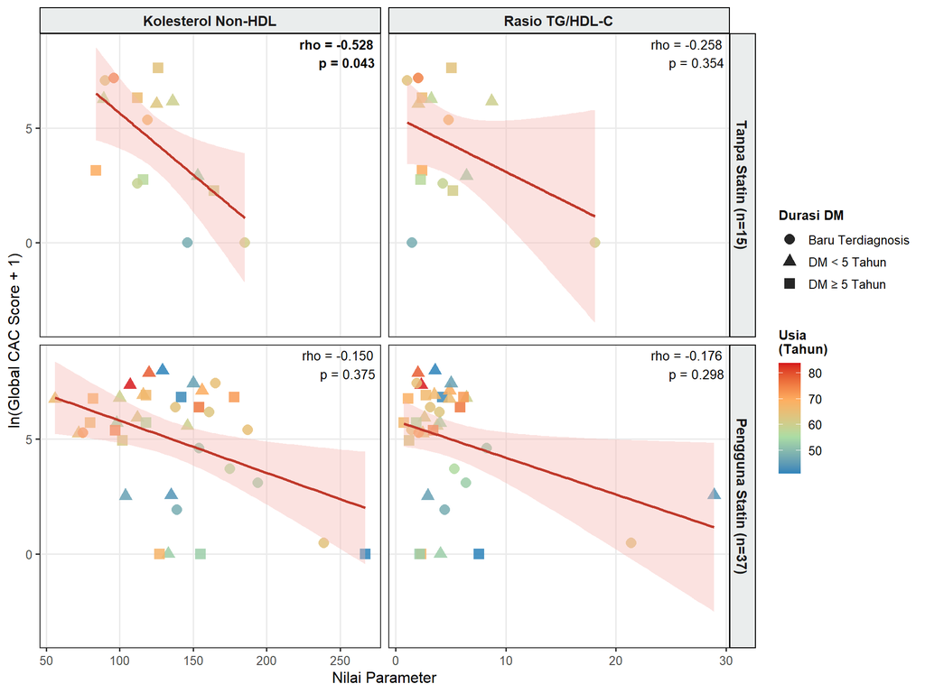

Gambar 1. Analisis korelasi kolesterol non-HDL dan Rasio TG/HDL-C terhadap kalsifikasi berdasarkan penggunaan Statin. Titik sebaran diwarnai berdasarkan usia pasien (spektrum biru untuk usia lebih muda, hingga merah untuk usia lebih tua), sementara bentuk titik membedakan durasi diabetes mellitus.

```r
library(ggplot2)
library(dplyr)
library(tidyr)

# 1. Menyiapkan data untuk facet (Tambahkan Durasi DM Kat)
df_strat <- df_clean %>%
  mutate(
    # Membuat kategori baru berdasarkan bulan (0 = baru, <60 = <5 tahun, >=60 = >=5 tahun)
    Durasi_DM_Kat = case_when(
      Durasi_DM_Bulan == 0 ~ "Baru Terdiagnosis",
      Durasi_DM_Bulan > 0 & Durasi_DM_Bulan < 60 ~ "DM < 5 Tahun",
      Durasi_DM_Bulan >= 60 ~ "DM \u2265 5 Tahun",
      TRUE ~ NA_character_
    ),
    Durasi_DM_Kat = factor(Durasi_DM_Kat, levels = c("Baru Terdiagnosis", "DM < 5 Tahun", "DM \u2265 5 Tahun"))
  ) %>%
  select(log_CAC, Statin, Non_HDL, TG_HDL_Ratio, Usia, Durasi_DM_Kat) %>%
  mutate(
    Statin = factor(Statin, levels = c("No-Statin", "On-Statin"), labels = c("Tanpa Statin (n=15)", "Pengguna Statin (n=37)")),
    `Kolesterol Non-HDL` = Non_HDL,
    `Rasio TG/HDL-C` = TG_HDL_Ratio
  ) %>%
  select(-Non_HDL, -TG_HDL_Ratio) %>%
  pivot_longer(cols = c(`Kolesterol Non-HDL`, `Rasio TG/HDL-C`), names_to = "Variable", values_to = "Value") %>%
  mutate(Variable = factor(Variable, levels = c("Kolesterol Non-HDL", "Rasio TG/HDL-C")))

# 2. Menghitung statistik untuk text label (DIREVISI KE SPEARMAN)
df_strat_stats <- df_strat %>%
  filter(!is.na(Value) & !is.na(log_CAC)) %>%
  group_by(Variable, Statin) %>%
  summarise(
    # Menggunakan Spearman dan meredam peringatan "ties" (angka kembar)
    rho = suppressWarnings(cor(Value, log_CAC, method = "spearman")),
    p_val = suppressWarnings(cor.test(Value, log_CAC, method = "spearman", exact = FALSE)$p.value),
    .groups = "drop"
  ) %>%
  mutate(
    p_text = ifelse(p_val < 0.001, "< 0.001", sprintf("= %.3f", p_val)),
    # Mengganti R menjadi rho
    label_text = sprintf("rho = %.3f\np %s", rho, p_text),
    # Menentukan style huruf: tebal untuk p < 0.05, biasa untuk p >= 0.05
    font_style = ifelse(p_val < 0.05, "bold", "plain")
  )

# 3. Membuat Plot Stratifikasi (Warna = Usia, Bentuk = Durasi DM)
p_strat <- ggplot(df_strat, aes(x = Value, y = log_CAC)) +
  # KUNCI: shape = Durasi_DM_Kat, ukuran titik diperbesar sedikit agar shape terlihat jelas
  geom_point(aes(color = Usia, shape = Durasi_DM_Kat), size = 3.5, alpha = 0.85) +
  scale_color_gradientn(
    colors = c("#2b83ba", "#abdda4", "#fdae61", "#d7191c"),
    name = "Usia\n(Tahun)"
  ) +
  # Menentukan jenis shape (16 = bulat penuh, 17 = segitiga penuh, 15 = kotak penuh)
  scale_shape_manual(
    values = c(16, 17, 15),
    name = "Durasi DM"
  ) +
  geom_smooth(method = "lm", se = TRUE, color = "#c0392b", fill = "#f5b7b1", linewidth = 1) +
  # Memasukkan font_style ke dalam aesthetic (aes)
  geom_text(data = df_strat_stats, aes(x = Inf, y = Inf, label = label_text, fontface = font_style),
            hjust = 1.1, vjust = 1.2, size = 3.5, color = "black", inherit.aes = FALSE) +
  facet_grid(Statin ~ Variable, scales = "free_x") +
  labs(
    x = "Nilai Parameter",
    y = "ln(Global CAC Score + 1)"
  ) +
  theme_bw(base_size = 12) +
  theme(
    strip.background = element_rect(fill = "#eaeded", color = "black"),
    strip.text = element_text(face = "bold", size = 11),
    panel.grid.minor = element_blank(),
    legend.position = "right",
    legend.title = element_text(face = "bold", size = 10),
    legend.box = "vertical",
    legend.spacing.y = unit(0.5, "cm")
  )

p_strat
```

## 4 Pembahasan

Penelitian ini mengevaluasi faktor klinis serta laboratorium terhadap derjat aterosklerosis koroner. Faktor usia merupakan prediktor independen yang mendominasi kerentanan plak maupun kalsifikasi koroner, sementara indeks metabolik gagal menunjukkan efek independen.

**Dominansi Usia dan Waktu Paparan (*Time-Dependent Effect*)**

Usia sebagai satu-satunya determinan klinis yang mencapai signifikansi statistik mendukung karakter natural aterosklerosis sebagai kondisi patologis yang bergantung pada waktu (*time-dependent*). Semakin bertambah usia, semakin lama durasi sel endotel vaskular mengalami stres oksidatif dan disfungsi mekanik. Makrofag yang teraktivasi di ruang subendotel akan mensekresi *Matrix Metalloproteinases* (MMP) secara masif untuk mendegradasi matriks ekstraseluler pada tunika media.<sup>20</sup> Degradasi matriks inilah yang mendasari kompensasi pembesaran lumen atau Fenomena Glagov (*positive remodeling*), salah satu fitur patognomonik dari plak berisiko tinggi (HRP).<sup>21</sup> Komplikasi ginjal (PGK stadium $\ge$ 3) secara persentase menampilkan tren klinis peningkatan risiko pada kelompok HRP positif dibandingkan HRP negatif (32% vs 13%), namun belum mencapai kemaknaan statistik, kemungkinan besar akibat sampel yang terbatas ($N = 52$). Ketiadaan parameter dengan nilai $p < 0,05$ pada uji bivariat di luar faktor usia juga mendasari tidak dilanjutkannya pemodelan multivariat, guna menghindari bias artefak pada kesimpulan akhir.

**Analisis Indeks Kardiometabolik**

Indeks turunan berbasis resistensi insulin (seperti TyHbA1c dan Rasio TG/HDL) belum dapat mengungguli faktor usia pada studi ini tampak kontradiktif dengan beberapa literatur sebelumnya. Penelitian oleh Won et al. (2018) dan Jin et al. (2020) melaporkan hubungan positif yang kuat dan independen antara indeks kardiometabolik turunan dengan tingkat aterosklerosis koroner<sup>2,3</sup>.Diskrepansi hasil ini dapat dijelaskan melalui perbedaan mendasar pada profil intervensi medis dan fase kronisitas penyakit sampel. Studi-studi terdahulu mayoritas mengevaluasi populasi asimptomatik yang relatif “naif” terhadap terapi kardiovaskular, di mana kemungkinan resistensi insulin fase akut masih berkorelasi kuat dengan inisiasi awal plak. Sebaliknya, kohort dalam penelitian ini merepresentasikan kondisi rutin di Indonesia (real-world) berupa pasien rujukan kardiologi dengan durasi penyakit lanjut dan telah mendapatkan terapi statin. Pengaruh farmakologis dari statin menekan komponen lipid pembentuk indeks tersebut di sirkulasi darah (terutama trigliserida), sehingga secara artifisial “menumpulkan” nilai prediktifnya. Selain itu, keterbatasan desain potong lintang (cross-sectional) hanya mampu mencatat profil lipid sewaktu saat CTCA yang sebagian besar telah termodifikasi oleh terapi, dan gagal menangkap puncak resistensi insulin di masa lalu yang mungkin menjadi pemicu awal kalsifikasi sebelumnya. Oleh karena itu, uji kohort skala besar lebih lanjut yang mampu merekam fluktuasi lipid (lipid variability) dan pencatatan dosis akumulatif statin sangat disarankan untuk memvalidasi temuan ini.

## 5 Simpulan

Pada pasien DM yang menjalani CTCA, faktor degeneratif (usia) bertindak sebagai determinan utama berhubungan dengan kerentanan plak (HRP) maupun kuantitas kalsifikasi koroner. Sebaliknya, penggunaan indeks kardiometabolik turunan baru sebagai substitusi resistensi insulin (seperti Indeks TyHbA1c, TG/HDL, Non-HDL, maupun SUA/HDL) tidak memberikan nilai prediktif diagnostik tambahan yang bermakna.

## 6 Daftar Pustaka

1.

Bornfeldt KE, Tabas I. [Insulin resistance, hyperglycemia, and atherosclerosis](https://doi.org/10.1016/j.cmet.2011.07.015). *Cell Metabolism*. 2011;14(5):575–85.

2.

Jin J-L, Sun D, Cao Y-X, dkk. [Triglyceride glucose and haemoglobin A1c indices for predicting cardiovascular outcomes in patients with coronary artery disease](https://doi.org/10.1111/jcmm.15579). *Journal of Cellular and Molecular Medicine*. 2020;24(17):9876–83.

3.

Won K-B, Park G-M, Lee S-E, dkk. [Relationship of insulin resistance estimated by triglyceride glucose index to arterial stiffness](https://doi.org/10.1016/j.ijcard.2018.02.100). *International Journal of Cardiology*. 2018;260:159–63.

4.

Visseren FL, Mach F, Smulders YM, dkk. [2021 ESC Guidelines on cardiovascular disease prevention in clinical practice](https://doi.org/10.1093/eurheartj/ehab484). *European Heart Journal*. 2021;42(34):3227–337.

5.

Jankowski J, Floege J, Fliser D, dkk. [Cardiovascular disease in chronic kidney disease: pathophysiological insights and therapeutic options](https://doi.org/10.1161/CIRCULATIONAHA.120.050686). *Circulation*. 2021;143(11):1157–72.

6.

Motoyama S, Ito H, Sarai M, dkk. [Plaque characterization by coronary computed tomography angiography and the likelihood of acute coronary events in mid-term follow-up](https://doi.org/10.1016/j.jacc.2015.05.069). *Journal of the American College of Cardiology*. 2015;66(4):337–46.

7.

Cury RC, Blankstein R, Leipsic J, dkk. [CAD-RADS™ 2.0–2022 Coronary Artery Disease-Reporting and Data System: An Expert Consensus Document of the Society of Cardiovascular Computed Tomography (SCCT), the American College of Cardiology (ACC), the American College of Radiology (ACR), and the North American Society for Cardiovascular Imaging (NASCI)](https://doi.org/10.1016/j.jcct.2022.07.002). *Journal of Cardiovascular Computed Tomography*. 2022;16(6):536–57.

8.

Kementerian Kesehatan Republik Indonesia. Profil Kesehatan Indonesia Tahun 2021. Jakarta: Kementerian Kesehatan RI; 2022.

9.

WHO Expert Consultation. Appropriate body-mass index for Asian populations and its implications for policy and intervention strategies. *The Lancet*. 2004;363(9403):157–63.

10.

Whelton PK, Carey RM, Aronow WS, dkk. 2017 ACC/AHA/AAPA/ABC/ACPM/AGS/APhA/ASH/ASPC/NMA/PCNA guideline for the prevention, detection, evaluation, and management of high blood pressure in adults: a report of the American College of Cardiology/American Heart Association Task Force on Clinical Practice Guidelines. *Journal of the American College of Cardiology*. 2018;71(19):e127–248.

11.

American Diabetes Association. [Glycemic Goals and Hypoglycemia: Standards of Care in Diabetes—2024](https://doi.org/10.2337/dc24-S006). *Diabetes Care*. 2024;47(Supplement_1):S111–25.

12.

Expert Panel on Detection, Evaluation, and Treatment of High Blood Cholesterol in Adults. Executive summary of the third report of the National Cholesterol Education Program (NCEP) expert panel on detection, evaluation, and treatment of high blood cholesterol in adults (Adult Treatment Panel III). *JAMA*. 2001;285(19):2486–97.

13.

Bardin T, Richette P. [Definition of hyperuricemia and gouty conditions](https://doi.org/10.1097/BOR.0000000000000028). *Current Opinion in Rheumatology*. 2014;26(2):186–91.

14.

World Health Organization. Haemoglobin concentrations for the diagnosis of anaemia and assessment of severity. Geneva: World Health Organization; 2011.

15.

McLaughlin T, Reaven G, Abbasi F, dkk. Is there a simple way to identify insulin-resistant individuals at increased risk of cardiovascular disease? *The American Journal of Cardiology*. 2003;92(2):121–4.

16.

Kocak MZ, Aktas G, Erkus E, dkk. [Serum uric acid to HDL-cholesterol ratio is a strong predictor of metabolic syndrome in type 2 diabetes mellitus](https://doi.org/10.24875/RIC.18002628). *Revista de Investigación Clı́nica*. 2019;71(1):49–55.

17.

Levey AS, Stevens LA, Schmid CH, dkk. [A new equation to estimate glomerular filtration rate](https://doi.org/10.7326/0003-4819-150-9-200905050-00006). *Annals of Internal Medicine*. 2009;150(9):604–12.

18.

Agatston AS, Janowitz WR, Hildner FJ, dkk. Quantification of coronary artery calcium using ultrafast computed tomography. *Journal of the American College of Cardiology*. 1990;15(4):827–32.

19.

R Core Team. [R: A Language and Environment for Statistical Computing](https://www.R-project.org/). Vienna, Austria: R Foundation for Statistical Computing; 2026.

20.

Newby AC. [Metalloproteinase expression in macrophages: its role in plaque rupture and atherothrombosis](https://doi.org/10.1161/ATVBAHA.108.173898). *Arteriosclerosis, Thrombosis, and Vascular Biology*. 2008;28(12):2108–14.

21.

Glagov S, Weisenberg E, Zarins CK, dkk. [Compensatory enlargement of human atherosclerotic coronary arteries](https://doi.org/10.1056/NEJM198705283162204). *New England Journal of Medicine*. 1987;316(22):1371–5.

## 7 Lampiran

**Uji Normalitas Data Numerik**

Panel histogram dan uji Shapiro-Wilk di atas menampilkan distribusi data pada variabel numerik. Sebagian besar variabel klinis dan indeks kardiometabolik tidak berdistribusi normal (p < 0,05). Secara khusus, panel grafik menunjukkan bahwa meskipun telah dilakukan transformasi logaritmik (ln[CAC+1]), kurva skor CAC tidak sepenuhnya normal akibat tingginya proporsi pasien dengan skor nol mutlak (zero-inflated data).

**Kode**

```r
library(dplyr)
library(tidyr)
library(ggplot2)
library(flextable)

# 1. Menyiapkan Data & Merapikan Nama Variabel
df_numerik <- df_clean %>%
  mutate(
    `Skor_CAC_Asli` = Global_CAC_score,
    `Ln_CAC_Plus_1` = log(Global_CAC_score + 1)
  ) %>%
  select(where(is.numeric)) %>%
  # Menambahkan Durasi_DM_Bulan ke dalam daftar pengecualian
  select(-any_of(c(
    "Global_CAC_score", "log_CAC",
    "No", "No. RM", "No_RM", "No__RM", "ID",
    "Tahun",
    "Alpha", "Kappa", "Sex_Mult",
    "CKD_Status", "CAC_100_plus",
    "Durasi_DM_Bulan"
  ))) %>%
  # Mengubah nama variabel (sistem ini sangat aman, hanya mengubah yang ada di data)
  rename(any_of(c(
    "Asam Urat" = "Asam-Urat",
    "Durasi DM (Tahun)" = "Durasi_DM",
    "Kolesterol HDL" = "HDL",
    "Kolesterol LDL" = "LDL",
    "Kolesterol Total" = "Kolesterol-Total",
    "Indeks TyHbA1c" = "TyHbA1c_Index",
    "Rasio SUA / HDL-C" = "SUA_HDL_Ratio",
    "Rasio TG / HDL-C" = "TG_HDL_Ratio",
    "Kolesterol Non-HDL" = "Non_HDL",
    "Skor CAC (Agatston)" = "Skor_CAC_Asli",
    "Skor CAC (ln[CAC+1])" = "Ln_CAC_Plus_1",
    "HbA1c" = "HbA1C"
  )))

# 2. FUNGSI AMAN SHAPIRO-WILK
uji_shapiro <- function(x) {
  x <- na.omit(x)
  if(length(x) >= 3 && length(x) <= 5000) {
    return(shapiro.test(x)$p.value)
  } else {
    return(NA)
  }
}

# 3. MEMBUAT TABEL NORMALITAS
tabel_normalitas <- df_numerik %>%
  summarise(across(everything(), uji_shapiro)) %>%
  pivot_longer(everything(), names_to = "Variabel", values_to = "P_Value") %>%
  mutate(
    Distribusi = ifelse(P_Value < 0.05, "Tidak Normal", "Normal"),
    P_Value_Format = ifelse(P_Value < 0.001, "< 0,001", format(round(P_Value, 3), decimal.mark=","))
  ) %>%
  select(Variabel, P_Value_Format, Distribusi) %>%
  arrange(Variabel) %>%
  flextable() %>%
  set_header_labels(
    Variabel = "Variabel Klinis / Indeks Metabolik",
    P_Value_Format = "Nilai p (Shapiro-Wilk)",
    Distribusi = "Distribusi"
  ) %>%
  bold(j = "Distribusi", i = ~ Distribusi == "Tidak Normal", bold = TRUE) %>%
  align(align = "center", part = "all") %>%
  autofit() %>%
  set_caption(caption = "Tabel S1. Hasil Uji Normalitas Shapiro-Wilk pada Variabel Numerik Klinis")

# 4. MEMBUAT PANEL HISTOGRAM
panel_histogram <- df_numerik %>%
  pivot_longer(everything(), names_to = "Variabel", values_to = "Nilai") %>%
  filter(!is.na(Nilai)) %>%
  ggplot(aes(x = Nilai)) +
  geom_histogram(aes(y = after_stat(density)), fill = "#4A81BF", color = "white", bins = 20) +
  geom_density(color = "#D9534F", linewidth = 0.8) +
  facet_wrap(~ Variabel, scales = "free") +
  theme_minimal(base_size = 12) +
  labs(
    x = "Nilai Distribusi",
    y = "Kepadatan (Density)"
  ) +
  theme(
    # Membuat judul di setiap grafik kecil lebih terbaca
    strip.text = element_text(face = "bold", size = 11, color = "black"),
    strip.background = element_rect(fill = "#F0F0F0", color = NA),
    panel.grid.minor = element_blank(),
    axis.text.y = element_blank(),
    axis.ticks.y = element_blank()
  )

# 5. MENAMPILKAN HASIL SECARA BERURUTAN
tabel_normalitas
```

| Variabel Klinis / Indeks Metabolik | Nilai p (Shapiro-Wilk) | Distribusi |
| --- | --- | --- |
| Asam Urat | 0,027 | Tidak Normal |
| Durasi DM (Tahun) | < 0,001 | Tidak Normal |
| HbA1c | < 0,001 | Tidak Normal |
| Hemoglobin | 0,305 | Normal |
| IMT | 0,023 | Tidak Normal |
| Indeks TyHbA1c | 0,592 | Normal |
| Kolesterol HDL | 0,875 | Normal |
| Kolesterol LDL | 0,868 | Normal |
| Kolesterol Non-HDL | 0,033 | Tidak Normal |
| Kolesterol Total | 0,041 | Tidak Normal |
| Kreatinin | < 0,001 | Tidak Normal |
| Rasio SUA / HDL-C | < 0,001 | Tidak Normal |
| Rasio TG / HDL-C | < 0,001 | Tidak Normal |
| Skor CAC (Agatston) | < 0,001 | Tidak Normal |
| Skor CAC (ln[CAC+1]) | < 0,001 | Tidak Normal |
| Trigliserida | < 0,001 | Tidak Normal |
| Usia | 0,490 | Normal |
| eGFR | 0,114 | Normal |

**Kode**

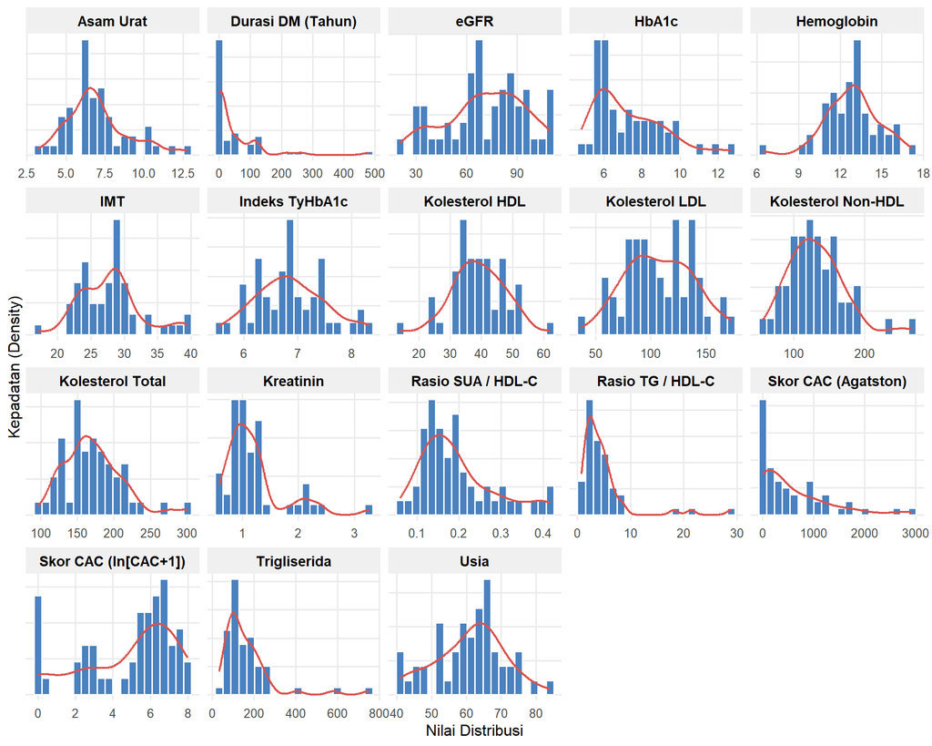

Gambar 3. **Supplementary S1. Panel Distribusi Histogram Data Numerik Kardiometabolik**

```r
panel_histogram
```

**Analisis Karakteristik Klinis Tambahan Terhadap Indeks Kardiometabolik Novel**

Sebagai pelengkap analisis, evaluasi tabulasi silang juga dilakukan pada dua indeks kardiometabolik yakni Indeks TyHbA1c (Tabel 7) dan Rasio SUA/HDL-C (Tabel 8). Pada evaluasi Indeks TyHbA1c, variabel kontrol glikemik (HbA1c) sengaja dieksklusi dari model analisis untuk menghindari bias mengingat parameter tersebut merupakan komponen pembentuk rumus dasar indeks.

**Kode**

```r
library(flextable)

med_ty <- median(df_clean$TyHbA1c_Index, na.rm = TRUE)

df_ty <- df_cac %>%
  mutate(
    TyHbA1c_Kat = factor(ifelse(TyHbA1c_Index > med_ty, "> Median (Tinggi)", "\u2264 Median (Rendah)"),
                         levels = c("\u2264 Median (Rendah)", "> Median (Tinggi)"))
  ) %>%
  # Menambahkan Usia_Kat (Tetap Tanpa HbA1c_Kat)
  select(TyHbA1c_Kat, Usia_Kat, Gender, IMT_Kat, Hipertensi_Kat, Merokok, Riwayat_DM, Terapi_DM, Statin)

label_ty <- list(
  Usia_Kat ~ "Kategori Usia",
  Gender ~ "Jenis Kelamin",
  IMT_Kat ~ "Kategori IMT",
  Hipertensi_Kat ~ "Status Hipertensi",
  Merokok ~ "Riwayat Merokok",
  Riwayat_DM ~ "Durasi Diagnosis DM",
  Terapi_DM ~ "Modalitas Terapi DM",
  Statin ~ "Penggunaan Statin"
)

df_ty %>%
  tbl_summary(by = TyHbA1c_Kat, label = label_ty, missing = "no") %>%
  add_p() %>%
  bold_p(t = 0.05) %>%
  modify_header(label = "**Faktor Klinis / Pengobatan**") %>%
  as_flex_table()
```

Tabel 7. **Karakteristik Klinis dan Profil Pengobatan Berdasarkan Kategori Indeks TyHbA1c**

| Faktor Klinis / Pengobatan | ≤ Median (Rendah) N = 261 | > Median (Tinggi) N = 261 | p-value2 |
| --- | --- | --- | --- |
| Kategori Usia |  |  | 0.15 |
| < 60 Tahun (n=19) | 7 (27%) | 12 (46%) |  |
| ≥ 60 Tahun (n=33) | 19 (73%) | 14 (54%) |  |
| Jenis Kelamin |  |  | >0.9 |
| Laki-laki (n=34) | 17 (65%) | 17 (65%) |  |
| Perempuan (n=18) | 9 (35%) | 9 (35%) |  |
| Kategori IMT |  |  | 0.8 |
| Normal/Overweight (n=17) | 8 (31%) | 9 (35%) |  |
| Obesitas (n=35) | 18 (69%) | 17 (65%) |  |
| Status Hipertensi |  |  | 0.7 |
| Tidak ada riwayat hipertensi (n=22) | 12 (46%) | 10 (38%) |  |
| Hipertensi Terkontrol (n=21) | 11 (42%) | 10 (38%) |  |
| Hipertensi Tidak Terkontrol (n=9) | 3 (12%) | 6 (23%) |  |
| Riwayat Merokok |  |  | 0.3 |
| Merokok (n=20) | 8 (31%) | 12 (46%) |  |
| Tidak-merokok (n=32) | 18 (69%) | 14 (54%) |  |
| Durasi Diagnosis DM |  |  | >0.9 |
| Baru Terdiagnosis (n=16) | 8 (31%) | 8 (31%) |  |
| Sudah Lama (n=36) | 18 (69%) | 18 (69%) |  |
| Modalitas Terapi DM |  |  | 0.7 |
| Tanpa Terapi/Diet (n=18) | 8 (31%) | 10 (38%) |  |
| OAD (n=17) | 8 (31%) | 9 (35%) |  |
| Insulin (n=17) | 10 (38%) | 7 (27%) |  |
| Penggunaan Statin |  |  | 0.8 |
| Tidak (n=15) | 7 (27%) | 8 (31%) |  |
| Ya (n=37) | 19 (73%) | 18 (69%) |  |

1n (%)  
2Pearson's Chi-squared test; Fisher's exact test

Hasil analisis komparasi silang pada Rasio Asam Urat/HDL-C (SUA/HDL) menunjukan adanya hubungan yang bermakna secara statistik terhadap status Indeks Massa Tubuh ($p = 0,039$) dan Usia ($p = 0,044$). Kelompok pasien dengan Rasio SUA/HDL yang tinggi (> median) secara signifikan didominasi oleh pasien dengan status *obesitas* (81%). Temuan ini mendukung utilitas Rasio SUA/HDL sebagai penanda *surrogate* akumulasi lemak viseral dan profil sindrom metabolik. Selain itu, dominasi pasien lansia ($\ge$ 60 tahun) pada kelompok rasio SUA/HDL yang rendah (77%) secara tidak langsung turut mendukung hipotesis *metabolic burn-out*, di mana pasien dengan kalsifikasi lanjut cenderung mengalami penurunan massa otot atau malnutrisi kronis yang menurunkan laju produksi asam urat sirkulasi.

**Kode**

```r
library(flextable)

med_sua <- median(df_clean$SUA_HDL_Ratio, na.rm = TRUE)

df_sua <- df_cac %>%
  mutate(
    SUA_HDL_Kat = factor(ifelse(SUA_HDL_Ratio > med_sua, "> Median (Tinggi)", "\u2264 Median (Rendah)"),
                         levels = c("\u2264 Median (Rendah)", "> Median (Tinggi)"))
  ) %>%
  # Menambahkan Usia_Kat
  select(SUA_HDL_Kat, Usia_Kat, Gender, IMT_Kat, Hipertensi_Kat, Merokok, HbA1C_Kat, Riwayat_DM, Terapi_DM, Statin)

label_sua <- list(
  Usia_Kat ~ "Kategori Usia",
  Gender ~ "Jenis Kelamin",
  IMT_Kat ~ "Kategori IMT",
  Hipertensi_Kat ~ "Status Hipertensi",
  Merokok ~ "Riwayat Merokok",
  HbA1C_Kat ~ "Kontrol Glikemik (HbA1c)",
  Riwayat_DM ~ "Durasi Diagnosis DM",
  Terapi_DM ~ "Modalitas Terapi DM",
  Statin ~ "Penggunaan Statin"
)

df_sua %>%
  tbl_summary(by = SUA_HDL_Kat, label = label_sua, missing = "no") %>%
  add_p() %>%
  bold_p(t = 0.05) %>%
  modify_header(label = "**Faktor Klinis / Pengobatan**") %>%
  as_flex_table()
```

Tabel 8. **Karakteristik Klinis dan Profil Pengobatan Berdasarkan Kategori Rasio Asam Urat/HDL (SUA/HDL-C)**

| Faktor Klinis / Pengobatan | ≤ Median (Rendah) N = 261 | > Median (Tinggi) N = 261 | p-value2 |
| --- | --- | --- | --- |
| Kategori Usia |  |  | 0.044 |
| < 60 Tahun (n=19) | 6 (23%) | 13 (50%) |  |
| ≥ 60 Tahun (n=33) | 20 (77%) | 13 (50%) |  |
| Jenis Kelamin |  |  | 0.2 |
| Laki-laki (n=34) | 15 (58%) | 19 (73%) |  |
| Perempuan (n=18) | 11 (42%) | 7 (27%) |  |
| Kategori IMT |  |  | 0.039 |
| Normal/Overweight (n=17) | 12 (46%) | 5 (19%) |  |
| Obesitas (n=35) | 14 (54%) | 21 (81%) |  |
| Status Hipertensi |  |  | 0.3 |
| Tidak ada riwayat hipertensi (n=22) | 10 (38%) | 12 (46%) |  |
| Hipertensi Terkontrol (n=21) | 13 (50%) | 8 (31%) |  |
| Hipertensi Tidak Terkontrol (n=9) | 3 (12%) | 6 (23%) |  |
| Riwayat Merokok |  |  | 0.3 |
| Merokok (n=20) | 8 (31%) | 12 (46%) |  |
| Tidak-merokok (n=32) | 18 (69%) | 14 (54%) |  |
| Kontrol Glikemik (HbA1c) |  |  | 0.2 |
| < 7.0% (Terkontrol) (n=27) | 16 (62%) | 11 (42%) |  |
| ≥ 7.0% (Tidak Terkontrol) (n=25) | 10 (38%) | 15 (58%) |  |
| Durasi Diagnosis DM |  |  | >0.9 |
| Baru Terdiagnosis (n=16) | 8 (31%) | 8 (31%) |  |
| Sudah Lama (n=36) | 18 (69%) | 18 (69%) |  |
| Modalitas Terapi DM |  |  | 0.8 |
| Tanpa Terapi/Diet (n=18) | 10 (38%) | 8 (31%) |  |
| OAD (n=17) | 8 (31%) | 9 (35%) |  |
| Insulin (n=17) | 8 (31%) | 9 (35%) |  |
| Penggunaan Statin |  |  | 0.4 |
| Tidak (n=15) | 6 (23%) | 9 (35%) |  |
| Ya (n=37) | 20 (77%) | 17 (65%) |  |

1n (%)  
2Pearson's Chi-squared test; Fisher's exact test

**Eksplorasi Kurva ROC Indeks Kardiometabolik**

Pemetaan kurva *Receiver Operating Characteristic* (ROC) dilakukan secara bersamaan untuk keempat indeks turunan dalam memprediksi kerentanan plak (HRP). Analisis diskriminatif ini menegaskan bahwa tidak ada satu pun indeks kardiometabolik yang mencapai *Area Under the Curve* (AUC) yang memadai sebagai alat diagnostik utama (Gambar 4).

**Kode**

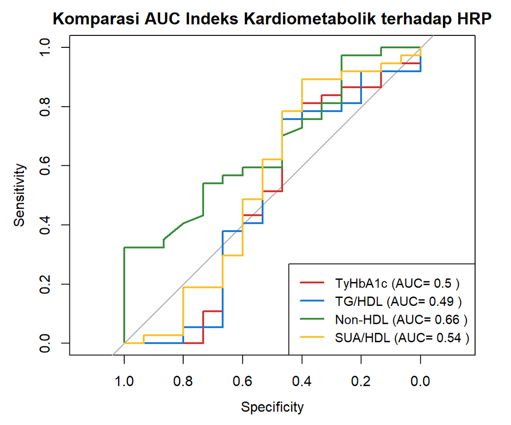

Gambar 4. **Komparasi Kurva ROC 4 Indeks Kardiometabolik.** Kurva menunjukkan bahwa kemampuan diskriminasi mandiri dari TyHbA1c, TG/HDL, Non-HDL, dan SUA/HDL dalam memprediksi kerentanan plak (HRP) tergolong lemah pada kohort ini.

```r
roc_ty <- roc(df_clean$HRP_Status, df_clean$TyHbA1c_Index, quiet=TRUE)
roc_tg <- roc(df_clean$HRP_Status, df_clean$TG_HDL_Ratio, quiet=TRUE)
roc_nhdl <- roc(df_clean$HRP_Status, df_clean$Non_HDL, quiet=TRUE)
roc_sua <- roc(df_clean$HRP_Status, df_clean$SUA_HDL_Ratio, quiet=TRUE)

plot(roc_ty, col="#D32F2F", lwd=2, main="Komparasi AUC Indeks Kardiometabolik terhadap HRP")
plot(roc_tg, col="#1976D2", lwd=2, add=TRUE)
plot(roc_nhdl, col="#388E3C", lwd=2, add=TRUE)
plot(roc_sua, col="#FBC02D", lwd=2, add=TRUE)

legend("bottomright",
       legend=c(paste("TyHbA1c (AUC=", round(auc(roc_ty),2), ")"),
                paste("TG/HDL (AUC=", round(auc(roc_tg),2), ")"),
                paste("Non-HDL (AUC=", round(auc(roc_nhdl),2), ")"),
                paste("SUA/HDL (AUC=", round(auc(roc_sua),2), ")")),
       col=c("#D32F2F", "#1976D2", "#388E3C", "#FBC02D"), lwd=2, cex=0.9)
```

**Korelasi Komprehensif Seluruh Parameter Klinis dan Laboratorium**

**Kode**

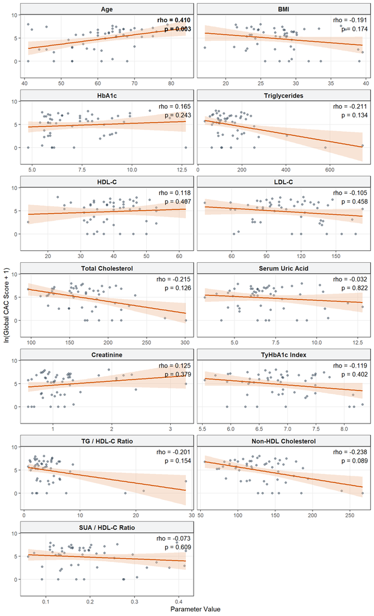

Gambar 5. **Korelasi Parameter Klinis, Laboratorium, dan Indeks Kardiometabolik dengan Kalsifikasi Koroner**

```r
library(ggplot2)
library(tidyr)
library(dplyr)

df_all_vars <- df_clean %>%
  mutate(
    log_CAC = log(Global_CAC_score + 1),
    TyHbA1c_Index = log(Trigliserida * HbA1C),
    TG_HDL_Ratio = Trigliserida / HDL,
    Non_HDL = `Kolesterol-Total` - HDL,
    SUA_HDL_Ratio = `Asam-Urat` / HDL
  ) %>%
  select(
    log_CAC, Age = Usia, BMI = IMT, HbA1c = HbA1C,
    Triglycerides = Trigliserida, `HDL-C` = HDL, `LDL-C` = LDL,
    `Total Cholesterol` = `Kolesterol-Total`, `Serum Uric Acid` = `Asam-Urat`,
    Creatinine = Kreatinin, `TyHbA1c Index` = TyHbA1c_Index,
    `TG / HDL-C Ratio` = TG_HDL_Ratio, `Non-HDL Cholesterol` = Non_HDL,
    `SUA / HDL-C Ratio` = SUA_HDL_Ratio
  ) %>%
  pivot_longer(
    cols = -log_CAC, names_to = "Variable", values_to = "Value"
  ) %>%
  mutate(Variable = factor(Variable, levels = c(
    "Age", "BMI", "HbA1c", "Triglycerides", "HDL-C", "LDL-C",
    "Total Cholesterol", "Serum Uric Acid", "Creatinine",
    "TyHbA1c Index", "TG / HDL-C Ratio", "Non-HDL Cholesterol", "SUA / HDL-C Ratio"
  )))

# --- MENGHITUNG STATISTIK & MENENTUKAN FORMAT FONT ---
df_stats_all <- df_all_vars %>%
  filter(!is.na(Value) & !is.na(log_CAC)) %>%
  group_by(Variable) %>%
  summarise(
    rho = suppressWarnings(cor(Value, log_CAC, method = "spearman")),
    p_val = suppressWarnings(cor.test(Value, log_CAC, method = "spearman", exact = FALSE)$p.value),
    .groups = "drop"
  ) %>%
  mutate(
    p_text = ifelse(p_val < 0.001, "< 0.001", sprintf("= %.3f", p_val)),
    # Mengganti simbol dengan kata "rho"
    label_text = sprintf("rho = %.3f\np %s", rho, p_text),
    # Menentukan style huruf: tebal untuk p < 0.05, biasa untuk p >= 0.05
    font_style = ifelse(p_val < 0.05, "bold", "plain")
  )
# ---------------------------------------------------

p_comprehensive <- ggplot(df_all_vars, aes(x = Value, y = log_CAC)) +
  geom_point(size = 1.5, alpha = 0.5, color = "#2c3e50") +
  geom_smooth(method = "lm", se = TRUE, color = "#d35400", fill = "#edbb99", linewidth = 0.8) +
  # Memasukkan font_style ke dalam aesthetic (aes) agar menyesuaikan per grafik
  geom_text(data = df_stats_all, aes(x = Inf, y = Inf, label = label_text, fontface = font_style),
            hjust = 1.1, vjust = 1.2, size = 3.5, color = "black", inherit.aes = FALSE) +
  facet_wrap(~ Variable, scales = "free_x", ncol = 2) +
  labs(x = "Parameter Value", y = "ln(Global CAC Score + 1)") +
  theme_bw(base_size = 11) +
  theme(
    strip.background = element_rect(fill = "#f2f3f4", color = "black"),
    strip.text = element_text(face = "bold", size = 10),
    panel.grid.minor = element_blank()
  )

# 4. Tampilkan plot ke dokumen
p_comprehensive
```

======================

**Kode**

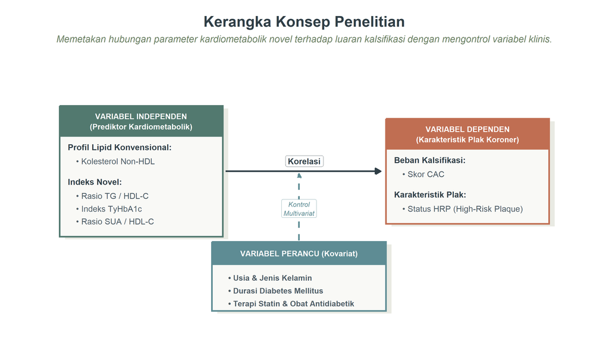

Gambar 6

```r
library(ggplot2)

p_konsep <- ggplot() +
  coord_cartesian(xlim = c(0, 100), ylim = c(0, 100)) +

  # ==========================================
  # 1. KOTAK VARIABEL INDEPENDEN (KIRI)
  # Border bawah ditarik ke y=34, teks digeser ke atas
  # ==========================================
  annotate("rect", xmin = 6, xmax = 36, ymin = 33, ymax = 84, fill = "#D4D6C8", alpha = 0.5) +
  annotate("rect", xmin = 5, xmax = 35, ymin = 34, ymax = 85, fill = "#F9F9F6", color = "#52796F", linewidth = 1.5) +
  annotate("rect", xmin = 5, xmax = 35, ymin = 73, ymax = 85, fill = "#52796F", color = "#52796F") +
  annotate("text", x = 20, y = 79, label = "VARIABEL INDEPENDEN\n(Prediktor Kardiometabolik)",
           color = "white", fontface = "bold", size = 5.2, lineheight = 1.1) +

  # Teks dinaikkan agar padding bawah sangat lega
  annotate("text", x = 6.5, y = 69, label = "Profil Lipid Konvensional:", fontface = "bold", color = "#2F3E46", hjust = 0, size = 5.5) +
  annotate("text", x = 8, y = 63.5, label = "\u2022 Kolesterol Non-HDL", color = "#4F5D66", hjust = 0, size = 5.5) +
  annotate("text", x = 6.5, y = 55.5, label = "Indeks Novel:", fontface = "bold", color = "#2F3E46", hjust = 0, size = 5.5) +
  annotate("text", x = 8, y = 50, label = "\u2022 Rasio TG / HDL-C", color = "#4F5D66", hjust = 0, size = 5.5) +
  annotate("text", x = 8, y = 45, label = "\u2022 Indeks TyHbA1c", color = "#4F5D66", hjust = 0, size = 5.5) +
  annotate("text", x = 8, y = 40, label = "\u2022 Rasio SUA / HDL-C", color = "#4F5D66", hjust = 0, size = 5.5) +


  # ==========================================
  # 2. KOTAK VARIABEL DEPENDEN (KANAN)
  # Border bawah ditarik ke y=39, teks digeser ke atas
  # ==========================================
  annotate("rect", xmin = 66, xmax = 96, ymin = 38, ymax = 79, fill = "#D4D6C8", alpha = 0.5) +
  annotate("rect", xmin = 65, xmax = 95, ymin = 39, ymax = 80, fill = "#F9F9F6", color = "#C06E52", linewidth = 1.5) +
  annotate("rect", xmin = 65, xmax = 95, ymin = 68, ymax = 80, fill = "#C06E52", color = "#C06E52") +
  annotate("text", x = 80, y = 74, label = "VARIABEL DEPENDEN\n(Karakteristik Plak Koroner)",
           color = "white", fontface = "bold", size = 5.2, lineheight = 1.1) +

  annotate("text", x = 66.5, y = 64, label = "Beban Kalsifikasi:", fontface = "bold", color = "#2F3E46", hjust = 0, size = 5.5) +
  annotate("text", x = 68, y = 58.5, label = "\u2022 Skor CAC", color = "#4F5D66", hjust = 0, size = 5.5) +
  annotate("text", x = 66.5, y = 50.5, label = "Karakteristik Plak:", fontface = "bold", color = "#2F3E46", hjust = 0, size = 5.5) +
  annotate("text", x = 68, y = 45, label = "\u2022 Status HRP (High-Risk Plaque)", color = "#4F5D66", hjust = 0, size = 5.5) +


  # ==========================================
  # 3. KOTAK VARIABEL PERANCU (BAWAH TENGAH)
  # ==========================================
  annotate("rect", xmin = 34, xmax = 66, ymin = 4, ymax = 31, fill = "#D4D6C8", alpha = 0.5) +
  annotate("rect", xmin = 33, xmax = 65, ymin = 5, ymax = 32, fill = "#F9F9F6", color = "#5E8C94", linewidth = 1.5) +
  annotate("rect", xmin = 33, xmax = 65, ymin = 23, ymax = 32, fill = "#5E8C94", color = "#5E8C94") +
  annotate("text", x = 49, y = 27.5, label = "VARIABEL PERANCU (Kovariat)",
           color = "white", fontface = "bold", size = 5.2, lineheight = 1.1) +

  annotate("text", x = 36, y = 18, label = "\u2022 Usia & Jenis Kelamin", color = "#4F5D66", fontface = "bold", hjust = 0, size = 5.2) +
  annotate("text", x = 36, y = 13, label = "\u2022 Durasi Diabetes Mellitus", color = "#4F5D66", fontface = "bold", hjust = 0, size = 5.2) +
  annotate("text", x = 36, y = 8, label = "\u2022 Terapi Statin & Obat Antidiabetik", color = "#4F5D66", fontface = "bold", hjust = 0, size = 5.2) +


  # ==========================================
  # 4. PANAH PENGHUBUNG (ARROWS)
  # Disesuaikan agar presisi di sumbu tengah kotak
  # ==========================================
  annotate("segment", x = 35.5, y = 59.5, xend = 64, yend = 59.5,
           linewidth = 1.5, color = "#2F3E46", arrow = arrow(type = "closed", length = unit(0.4, "cm"))) +
  annotate("label", x = 50, y = 63.5, label = "Korelasi", fontface = "bold", size = 5.5, color = "#2F3E46", fill = "white", label.size = 0) +

  annotate("segment", x = 49, y = 32.5, xend = 49, yend = 58.5,
           linewidth = 1.5, linetype = "dashed", color = "#5E8C94", arrow = arrow(type = "closed", length = unit(0.3, "cm"))) +
  annotate("label", x = 49, y = 45, label = "Kontrol\nMultivariat", fontface = "italic", size = 4.5, color = "#5E8C94", fill = "white", label.size = 0, lineheight = 1.1) +


  # ==========================================
  # 5. JUDUL & TEMA KANVAS
  # ==========================================
  labs(
    title = "Kerangka Konsep Penelitian",
    subtitle = "Memetakan hubungan parameter kardiometabolik novel terhadap luaran kalsifikasi dengan mengontrol variabel klinis."
  ) +

  theme_void() +
  theme(
    plot.background = element_rect(fill = "#FFFFFF", color = NA),
    plot.title = element_text(face = "bold", size = 28, color = "#2F3E46", hjust = 0.5, margin = margin(t = 20, b = 10)),
    plot.subtitle = element_text(face = "italic", size = 18, color = "#6A7F62", hjust = 0.5, margin = margin(b = 20)),
    plot.margin = margin(t = 10, r = 10, b = 10, l = 10)
  )

p_konsep

ggsave("Grafik/Kerangka_Konsep_Penelitian_16x9.png", plot = p_konsep, width = 16, height = 9, dpi = 300)
```

**Kode**

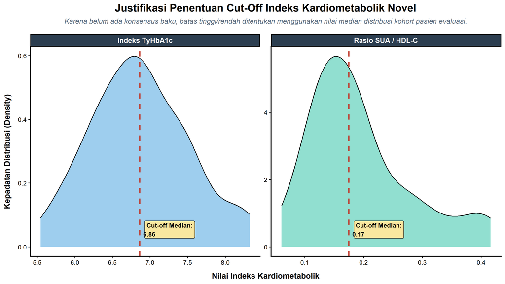

Gambar 7

```r
library(ggplot2)
library(dplyr)
library(tidyr)
library(patchwork)

# 1. Menyiapkan Data TyHbA1c dan SUA/HDL
df_cutoff <- df_clean %>%
  mutate(
    `Indeks TyHbA1c` = log(Trigliserida * HbA1C),
    `Rasio SUA / HDL-C` = `Asam-Urat` / HDL
  ) %>%
  select(`Indeks TyHbA1c`, `Rasio SUA / HDL-C`) %>%
  pivot_longer(cols = everything(), names_to = "Indeks", values_to = "Nilai") %>%
  filter(!is.na(Nilai))

# 2. Menghitung Nilai Median untuk Garis Cut-off
df_median <- df_cutoff %>%
  group_by(Indeks) %>%
  summarise(Nilai_Median = median(Nilai, na.rm = TRUE), .groups = "drop")

# 3. Membuat Density Plot dengan Garis Potong (Cut-off) Median
p_cutoff <- ggplot(df_cutoff, aes(x = Nilai, fill = Indeks)) +
  # Kurva Distribusi
  geom_density(alpha = 0.6, color = "black", linewidth = 0.8) +
  # Garis Median (Cut-off)
  geom_vline(data = df_median, aes(xintercept = Nilai_Median),
             color = "#C0392B", linetype = "dashed", linewidth = 1.5) +
  # Teks Label Median
  geom_label(data = df_median, aes(x = Nilai_Median, y = 0, label = sprintf("Cut-off Median:\n%.2f", Nilai_Median)),
             vjust = -0.5, hjust = -0.1, fill = "#F9E79F", color = "black", fontface = "bold", size = 5) +
  # Membagi menjadi 2 panel kiri-kanan
  facet_wrap(~ Indeks, scales = "free") +
  # Palet Warna Natural
  scale_fill_manual(values = c("Indeks TyHbA1c" = "#5DADE2", "Rasio SUA / HDL-C" = "#48C9B0")) +

  labs(
    title = "Justifikasi Penentuan Cut-Off Indeks Kardiometabolik Novel",
    subtitle = "Karena belum ada konsensus baku, batas tinggi/rendah ditentukan menggunakan nilai median distribusi kohort pasien evaluasi.",
    x = "Nilai Indeks Kardiometabolik",
    y = "Kepadatan Distribusi (Density)"
  ) +

  theme_classic(base_size = 18) +
  theme(
    legend.position = "none",
    plot.title = element_text(face = "bold", size = 24, hjust = 0.5, margin = margin(b = 10)),
    plot.subtitle = element_text(face = "italic", size = 16, color = "#5D6D7E", hjust = 0.5, margin = margin(b = 20)),

    strip.background = element_rect(fill = "#2C3E50", color = "black"),
    strip.text = element_text(face = "bold", size = 16, color = "white"),

    axis.line = element_line(linewidth = 1.2),
    axis.title.x = element_text(face = "bold", margin = margin(t = 15)),
    axis.title.y = element_text(face = "bold", margin = margin(r = 15))
  )

p_cutoff

ggsave("Grafik/Metode_Visualisasi_CutOff_16x9.png", plot = p_cutoff, width = 16, height = 9, dpi = 300)
```

**Kode**

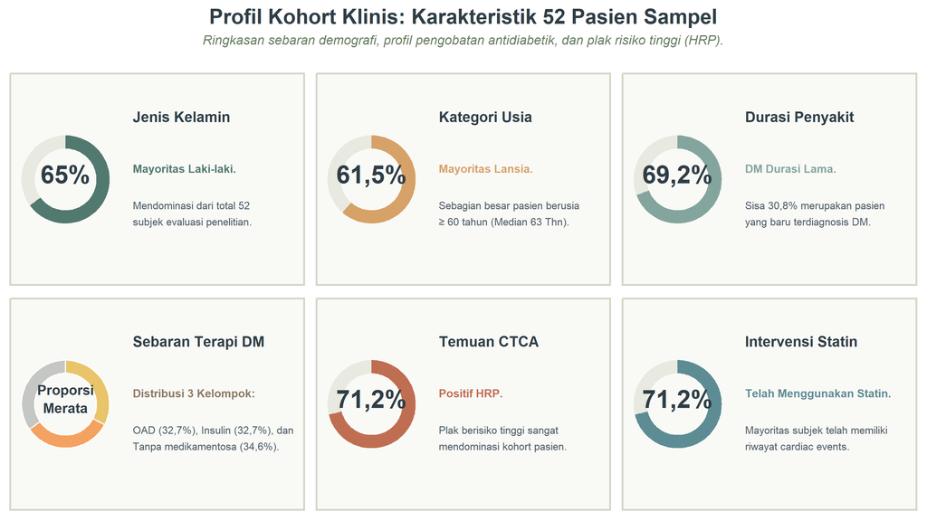

Gambar 8

```r
library(ggplot2)
library(cowplot)
library(patchwork)

# =======================================================
# 1. FUNGSI: DONUT TUNGGAL
# =======================================================
make_donut_single <- function(perc, color_main) {
  df <- data.frame(
    ymax = c(100, perc),
    ymin = c(perc, 0),
    category = c("Miss", "Hit")
  )

  ggplot(df) +
    geom_rect(aes(ymin = ymin, ymax = ymax, xmax = 4, xmin = 2.8, fill = category)) +
    coord_polar(theta = "y", start = 0) +
    scale_fill_manual(values = c("Hit" = color_main, "Miss" = "#E8E9E1")) +
    annotate("text", x = 0.5, y = 0, label = paste0(gsub("\\.", ",", perc), "%"),
             size = 11, fontface = "bold", color = "#2F3E46") +
    xlim(c(0, 4)) +
    theme_void() +
    theme(legend.position = "none")
}

# =======================================================
# 2. FUNGSI: DONUT MULTI-KATEGORI (Untuk Terapi DM)
# =======================================================
make_donut_multi <- function(df_data, palette) {
  df_data$ymax <- cumsum(df_data$perc)
  df_data$ymin <- c(0, head(df_data$ymax, n = -1))

  ggplot(df_data) +
    geom_rect(aes(ymin = ymin, ymax = ymax, xmax = 4, xmin = 2.8, fill = category), color = "white", linewidth = 0.8) +
    coord_polar(theta = "y", start = 0) +
    scale_fill_manual(values = palette) +
    annotate("text", x = 0.5, y = 0, label = "Proporsi\nMerata",
             size = 6, fontface = "bold", color = "#2F3E46", lineheight = 1.1) +
    xlim(c(0, 4)) +
    theme_void() +
    theme(legend.position = "none")
}

# =======================================================
# 3. FUNGSI: PEMBUNGKUS KARTU (CARD WRAPPER)
# =======================================================
make_card <- function(plot_obj, title, desc1, desc2, color_desc1) {
  ggdraw() +
    annotate("rect", xmin = 0.02, xmax = 0.98, ymin = 0.03, ymax = 0.97,
             color = "#D4D6C8", fill = "#F9F9F6", linewidth = 1.2) +
    draw_plot(plot_obj, x = 0.02, y = 0.05, width = 0.36, height = 0.9) +
    draw_text(title, x = 0.42, y = 0.78, fontface = "bold", size = 18, hjust = 0, color = "#2F3E46") +
    draw_text(desc1, x = 0.42, y = 0.55, fontface = "bold", size = 14, hjust = 0, color = color_desc1) +
    draw_text(desc2, x = 0.42, y = 0.35, size = 13, hjust = 0, lineheight = 1.3, color = "#4F5D66") +
    theme(plot.background = element_rect(fill = "#FFFFFF", color = NA))
}

# =======================================================
# 4. MENYUSUN 6 KARTU (Alur: Siapa -> Berapa Lama -> Terapi -> Hasil Jantung)
# =======================================================
# 1. Jenis Kelamin
card_gender <- make_card(make_donut_single(65, "#52796F"), "Jenis Kelamin", "Mayoritas Laki-laki.", "Mendominasi dari total 52\nsubjek evaluasi penelitian.", "#52796F")

# 2. Kategori Usia (Baru) - Silakan ganti 61.5 dengan data asli proporsi Lansia Dokter
card_age <- make_card(make_donut_single(61.5, "#D6A268"), "Kategori Usia", "Mayoritas Lansia.", "Sebagian besar pasien berusia\n\u2265 60 tahun (Median 63 Thn).", "#D6A268")

# 3. Durasi Penyakit
card_dur <- make_card(make_donut_single(69.2, "#84A59D"), "Durasi Penyakit", "DM Durasi Lama.", "Sisa 30,8% merupakan pasien\nyang baru terdiagnosis DM.", "#84A59D")

# 4. Terapi DM
df_tx <- data.frame(category = c("Oral", "Insulin", "None"), perc = c(32.7, 32.7, 34.6))
pal_tx <- c("Oral" = "#E9C46A", "Insulin" = "#F4A261", "None" = "#C5C7C4")
card_tx <- make_card(make_donut_multi(df_tx, pal_tx), "Sebaran Terapi DM", "Distribusi 3 Kelompok:", "OAD (32,7%), Insulin (32,7%), dan\nTanpa medikamentosa (34,6%).", "#8C7B65")

# 5. Status Anatomi CTCA
card_hrp <- make_card(make_donut_single(71.2, "#C06E52"), "Temuan CTCA", "Positif HRP.", "Plak berisiko tinggi sangat\nmendominasi kohort pasien.", "#C06E52")

# 6. Intervensi Statin
card_statin <- make_card(make_donut_single(71.2, "#5E8C94"), "Intervensi Statin", "Telah Menggunakan Statin.", "Mayoritas subjek telah memiliki\nriwayat cardiac events.", "#5E8C94")


# =======================================================
# 5. PENGGABUNGAN MATEMATIS (GRID 2x3 PENUH)
# =======================================================
row1 <- card_gender | card_age | card_dur
row2 <- card_tx | card_hrp | card_statin

final_infographic <- (row1 / row2) +
  plot_annotation(
    title = "Profil Kohort Klinis: Karakteristik 52 Pasien Sampel",
    subtitle = "Ringkasan sebaran demografi, profil pengobatan antidiabetik, dan plak risiko tinggi (HRP).",
    theme = theme(
      plot.title = element_text(face = "bold", size = 26, color = "#2F3E46", hjust = 0.5, margin = margin(b = 8, t = 5)),
      plot.subtitle = element_text(face = "italic", size = 16, color = "#6A7F62", hjust = 0.5, margin = margin(b = 25)),
      plot.background = element_rect(fill = "#FFFFFF", color = NA)
    )
  )

# Eksekusi plot
final_infographic

ggsave("Grafik/Gambar_Dashboard_Nature_6Panel_16x9.png", plot = final_infographic, width = 16, height = 9, dpi = 300)
```

**Kode**

[figure not shown]

Gambar 9

```r
library(ggplot2)
library(dplyr)

# 1. Menyiapkan Data Tabel 1 & 2 (Ditambahkan Median & Q1-Q3 sesuai Naskah)
df_summary <- data.frame(
  Parameter = factor(
    rep(c("Skor CAC\n(Agatston)", "Usia\n(Tahun)"), each = 2),
    levels = c("Skor CAC\n(Agatston)", "Usia\n(Tahun)")
  ),
  HRP_Status = rep(c("HRP (-)", "HRP (+)"), 2),
  Nilai = c(12, 557, 57, 64),
  # Data di bawah diambil persis dari rentang Q1-Q3 di Tabel 1 & 2 naskah
  Teks_Nilai = c("12 (0-18)", "557 (219-1.014)", "57 (48-63)", "64 (58-69)")
) %>%
  group_by(Parameter) %>%
  mutate(
    Max_Nilai = max(Nilai),
    Plot_X = Nilai / Max_Nilai,
    Plot_X = ifelse(HRP_Status == "HRP (-)", -Plot_X, Plot_X),
    # Jarak teks dijauhkan sedikit karena string (Q1-Q3) memakan ruang lebih panjang
    Text_X = ifelse(HRP_Status == "HRP (-)", Plot_X - 0.08, Plot_X + 0.08),
    Hjust = ifelse(HRP_Status == "HRP (-)", 1, 0)
  ) %>% ungroup()

# 2. Menyiapkan Data untuk Anotasi P-Value
df_pvals <- data.frame(
  Parameter = factor(c("Usia\n(Tahun)", "Skor CAC\n(Agatston)"),
                     levels = c("Skor CAC\n(Agatston)", "Usia\n(Tahun)")),
  Label_P = c("Signifikan, p = 0,010", "Signifikan, p < 0,001"),
  X_Pos = c(1.0, 1.0),
  Y_Pos = c(2.35, 1.35)
)

# 3. Membuat Grafik Infografis Slide yang Disempurnakan
p_infographic <- ggplot(df_summary, aes(y = Parameter)) +

  geom_vline(xintercept = 0, color = "black", linewidth = 1.2) +

  geom_col(aes(x = Plot_X, fill = HRP_Status), width = 0.45, color = "black", linewidth = 0.8) +

  # Ukuran teks angka (Q1-Q3) sedikit disesuaikan agar rapi
  geom_text(aes(x = Text_X, label = Teks_Nilai, hjust = Hjust), size = 6.5, fontface = "bold", color = "black") +

  # KUNCI 3: Label Parameter diturunkan letaknya (-0.38) agar berada di bawah balok, tidak menutupi garis 0
  geom_label(aes(x = 0, y = as.numeric(Parameter) - 0.38, label = Parameter), size = 6, fontface = "bold", color = "black",
             fill = "white", label.size = 0, label.padding = unit(0.5, "lines")) +

  # Label HRP (-) dan (+) diturunkan sedikit koordinat Y-nya
  annotate("text", x = -0.5, y = 2.45, label = "HRP (-)", size = 9, fontface = "bold", color = "#7F8C8D") +
  annotate("text", x = 0.5, y = 2.45, label = "HRP (+)", size = 9, fontface = "bold", color = "#C0392B") +

  geom_label(data = df_pvals, aes(x = X_Pos, y = Y_Pos, label = Label_P),
             size = 6, fontface = "bold", fill = "#ECF0F1", color = "black",
             label.size = 0.8, label.padding = unit(0.6, "lines"), hjust = 0.5) +

  geom_curve(data = df_pvals, aes(x = X_Pos - 0.2, y = Y_Pos - 0.05,
                                  xend = 0.5, yend = as.numeric(Parameter) + 0.15),
             curvature = 0.2, linewidth = 0.8, color = "black",
             arrow = arrow(length = unit(0.02, "npc"), type = "closed")) +

  scale_fill_manual(values = c("HRP (-)" = "#CCCCCC", "HRP (+)" = "#E64B35")) +

  # Rentang X diperlebar ke -2.0 s/d 2.0 agar teks (Q1-Q3) yang panjang tidak keluar frame
  scale_x_continuous(limits = c(-2.0, 2.0)) +
  scale_y_discrete(expand = expansion(mult = c(0.2, 0.3))) +

  # KUNCI 1: Clip = "off" mengizinkan elemen grafis digambar keluar dari batas kanvas (mencegah terpotong)
  coord_cartesian(clip = "off") +

  labs(
    title = "Temuan Utama: Dominansi Usia dalam Kerentanan Plak",
    caption = "Kesimpulan: Usia merupakan satu-satunya determinan klinis yang mencapai signifikansi statistik,\nmembuktikan bahwa aterosklerosis adalah patologi yang sangat bergantung pada waktu (time-dependent)."
  ) +

  theme_void(base_size = 20) +
  theme(
    legend.position = "none",
    plot.title = element_text(face = "bold", hjust = 0.5, size = 28, margin = margin(t = 10, b = 20)),
    plot.caption = element_text(size = 18, hjust = 0.5, face = "italic", color = "black",
                                margin = margin(t = 30), lineheight = 1.3),
    plot.background = element_rect(fill = "white", color = NA)
  )

p_infographic

ggsave("Grafik/Slide_Infografis_Kesimpulan_PPT.png", plot = p_infographic, width = 16, height = 9, dpi = 300)
```

**Kode**

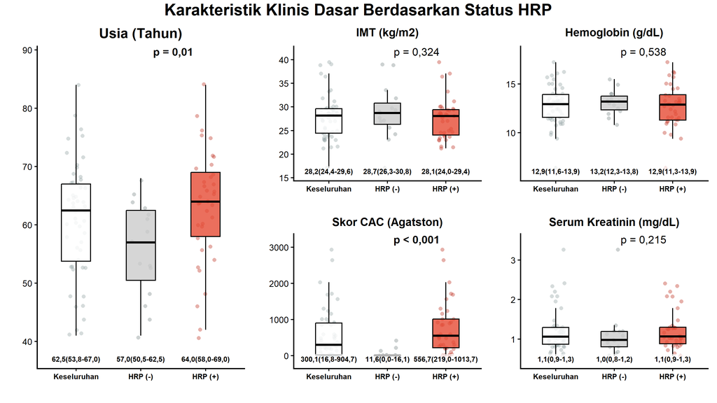

Gambar 10

```r
library(ggplot2)
library(dplyr)
library(tidyr)
library(patchwork)

# 1. Menyeleksi 5 Variabel Kelompok 1 (MENGGUNAKAN NAMA KOLOM ASLI)
df_group1 <- df_clean %>%
  select(HRP_Status, Usia, IMT, Hemoglobin, Global_CAC_score, Kreatinin) %>%
  rename(
    `Usia (Tahun)` = Usia,
    `IMT (kg/m2)` = IMT,
    `Hemoglobin (g/dL)` = Hemoglobin,
    `Skor CAC (Agatston)` = Global_CAC_score,
    `Serum Kreatinin (mg/dL)` = Kreatinin
  ) %>%
  pivot_longer(cols = -HRP_Status, names_to = "Variabel", values_to = "Nilai") %>%
  filter(!is.na(Nilai))

df_overall <- df_group1 %>% mutate(HRP_Status = "Keseluruhan")
df_group1 <- bind_rows(df_overall, df_group1) %>%
  mutate(HRP_Status = factor(HRP_Status, levels = c("Keseluruhan", "HRP (-)", "HRP (+)")))

buat_plot <- function(nama_var) {
  df_sub <- df_group1 %>% filter(Variabel == nama_var)

  df_pval <- df_sub %>% filter(HRP_Status != "Keseluruhan") %>%
    summarise(p_val = wilcox.test(Nilai ~ HRP_Status)$p.value) %>%
    mutate(p_text = ifelse(p_val < 0.001, "p < 0,001", paste0("p = ", format(round(p_val, 3), decimal.mark=","))),
           font_style = ifelse(p_val < 0.05, "bold", "plain"))

  df_med <- df_sub %>% group_by(HRP_Status) %>%
    summarise(Q1 = quantile(Nilai, 0.25, na.rm=TRUE), Median = median(Nilai, na.rm=TRUE), Q3 = quantile(Nilai, 0.75, na.rm=TRUE)) %>%
    mutate(label_med = paste0(format(round(Median,1), decimal.mark=",", trim=TRUE), "(",
                              format(round(Q1,1), decimal.mark=",", trim=TRUE), "-",
                              format(round(Q3,1), decimal.mark=",", trim=TRUE), ")"))

  ggplot(df_sub, aes(x = HRP_Status, y = Nilai, fill = HRP_Status)) +
    geom_jitter(aes(color = HRP_Status), width = 0.15, alpha = 0.4, size = 2.5, shape = 16) +
    geom_boxplot(alpha = 0.8, color = "black", linewidth = 0.8, outlier.shape = NA, width = 0.45) +
    geom_text(data = df_pval, aes(x = 2.5, y = Inf, label = p_text, fontface = font_style),
              vjust = 1.2, size = 6, color = "black", inherit.aes = FALSE) +
    geom_label(data = df_med, aes(x = HRP_Status, y = -Inf, label = label_med),
               vjust = -0.5, size = 4, fontface = "bold", color = "black", fill = alpha("white", 0.7), label.size = 0, inherit.aes = FALSE) +
    scale_fill_manual(values = c("Keseluruhan" = "#FFFFFF", "HRP (-)" = "#CCCCCC", "HRP (+)" = "#E64B35")) +
    scale_color_manual(values = c("Keseluruhan" = "#95A5A6", "HRP (-)" = "#7F8C8D", "HRP (+)" = "#C0392B")) +
    scale_y_continuous(expand = expansion(mult = c(0.12, 0.15))) +
    labs(title = nama_var, x = "", y = "") +
    theme_classic(base_size = 18) +
    theme(legend.position = "none", plot.title = element_text(face = "bold", hjust = 0.5, size = 18),
          axis.line = element_line(color = "black", linewidth = 1), axis.text.x = element_text(face = "bold", size = 12, color = "black"),
          axis.text.y = element_text(size = 14, color = "black"))
}

p_usia <- buat_plot("Usia (Tahun)") + theme(plot.title = element_text(size = 22))
p_imt <- buat_plot("IMT (kg/m2)")
p_hb <- buat_plot("Hemoglobin (g/dL)")
p_cac <- buat_plot("Skor CAC (Agatston)")
p_kre <- buat_plot("Serum Kreatinin (mg/dL)")

layout_asimetris <- p_usia | (p_imt + p_hb + p_cac + p_kre + plot_layout(ncol = 2))

final_plot_1 <- layout_asimetris + plot_layout(widths = c(1, 2)) +
  plot_annotation(title = "Karakteristik Klinis Dasar Berdasarkan Status HRP",
                  theme = theme(plot.title = element_text(face = "bold", size = 26, hjust = 0.5)))

final_plot_1

ggsave("Grafik/Presentasi_Boxplot_Grup1_Asimetris.png", plot = final_plot_1, width = 16, height = 9, dpi = 300)
```

**Kode**

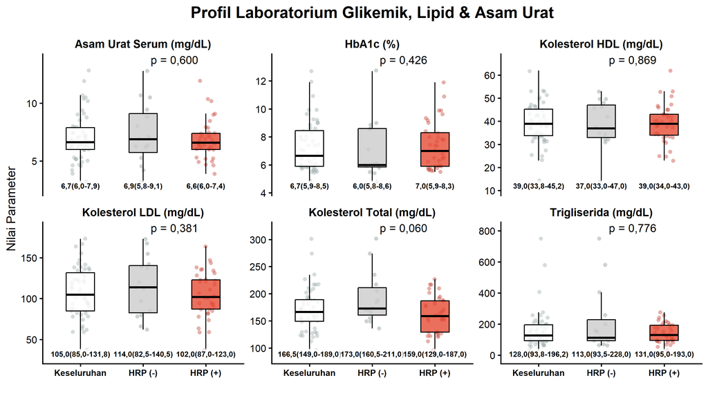

Gambar 11

```r
library(ggplot2)
library(dplyr)
library(tidyr)

# 1. Menyeleksi 6 Variabel Kelompok 2 (MENGGUNAKAN NAMA KOLOM ASLI dengan Backtick)
df_group2 <- df_clean %>%
  select(HRP_Status, HbA1C, `Kolesterol-Total`, LDL, HDL, Trigliserida, `Asam-Urat`) %>%
  rename(
    `HbA1c (%)` = HbA1C,
    `Kolesterol Total (mg/dL)` = `Kolesterol-Total`,
    `Kolesterol LDL (mg/dL)` = LDL,
    `Kolesterol HDL (mg/dL)` = HDL,
    `Trigliserida (mg/dL)` = Trigliserida,
    `Asam Urat Serum (mg/dL)` = `Asam-Urat`
  ) %>%
  pivot_longer(cols = -HRP_Status, names_to = "Variabel", values_to = "Nilai") %>%
  filter(!is.na(Nilai))

df_overall2 <- df_group2 %>% mutate(HRP_Status = "Keseluruhan")
df_group2 <- bind_rows(df_overall2, df_group2) %>%
  mutate(HRP_Status = factor(HRP_Status, levels = c("Keseluruhan", "HRP (-)", "HRP (+)")))

df_pvals2 <- df_group2 %>% filter(HRP_Status != "Keseluruhan") %>% group_by(Variabel) %>%
  summarise(p_val = wilcox.test(Nilai ~ HRP_Status)$p.value, .groups = "drop") %>%
  mutate(p_text = ifelse(p_val < 0.001, "p < 0,001", paste0("p = ", format(round(p_val, 3), decimal.mark=","))),
         font_style = ifelse(p_val < 0.05, "bold", "plain"))

df_medians2 <- df_group2 %>% group_by(Variabel, HRP_Status) %>%
  summarise(Q1 = quantile(Nilai, 0.25, na.rm=TRUE), Median = median(Nilai, na.rm=TRUE), Q3 = quantile(Nilai, 0.75, na.rm=TRUE), .groups = "drop") %>%
  mutate(label_med = paste0(format(round(Median,1), decimal.mark=",", trim=TRUE), "(",
                            format(round(Q1,1), decimal.mark=",", trim=TRUE), "-",
                            format(round(Q3,1), decimal.mark=",", trim=TRUE), ")"))

final_plot_2 <- ggplot(df_group2, aes(x = HRP_Status, y = Nilai, fill = HRP_Status)) +
  geom_jitter(aes(color = HRP_Status), width = 0.15, alpha = 0.4, size = 2.5, shape = 16) +
  geom_boxplot(alpha = 0.8, color = "black", linewidth = 0.8, outlier.shape = NA, width = 0.45) +
  geom_text(data = df_pvals2, aes(x = 2.5, y = Inf, label = p_text, fontface = font_style), vjust = 1.2, size = 6.5, color = "black", inherit.aes = FALSE) +
  geom_label(data = df_medians2, aes(x = HRP_Status, y = -Inf, label = label_med), vjust = -0.5, size = 4.2, fontface = "bold", color = "black", fill = alpha("white", 0.7), label.size = 0, inherit.aes = FALSE) +
  facet_wrap(~ Variabel, scales = "free_y", ncol = 3) +
  scale_fill_manual(values = c("Keseluruhan" = "#FFFFFF", "HRP (-)" = "#CCCCCC", "HRP (+)" = "#E64B35")) +
  scale_color_manual(values = c("Keseluruhan" = "#95A5A6", "HRP (-)" = "#7F8C8D", "HRP (+)" = "#C0392B")) +
  scale_y_continuous(expand = expansion(mult = c(0.12, 0.15))) +
  labs(title = "Profil Laboratorium Glikemik, Lipid & Asam Urat", x = "", y = "Nilai Parameter") +
  theme_classic(base_size = 20) +
  theme(legend.position = "none", strip.background = element_blank(), strip.text = element_text(face = "bold", size = 18, color = "black"),
        axis.line = element_line(color = "black", linewidth = 1), axis.text.x = element_text(face = "bold", size = 14, color = "black"),
        plot.title = element_text(face = "bold", hjust = 0.5, size = 26, margin = margin(b = 20)))

final_plot_2

ggsave("Grafik/Presentasi_Boxplot_Grup2_Grid.png", plot = final_plot_2, width = 16, height = 9, dpi = 300)
```

**Kode**

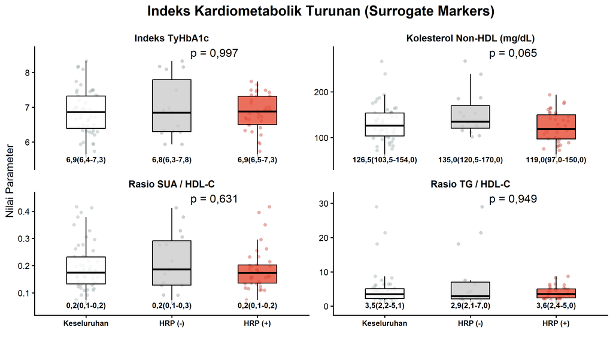

Gambar 12

```r
library(ggplot2)
library(dplyr)
library(tidyr)

# 1. Menyeleksi 4 Variabel Kelompok 3
df_group3 <- df_clean %>%
  select(HRP_Status, TyHbA1c_Index, TG_HDL_Ratio, Non_HDL, SUA_HDL_Ratio) %>%
  rename(
    `Indeks TyHbA1c` = TyHbA1c_Index,
    `Rasio TG / HDL-C` = TG_HDL_Ratio,
    `Kolesterol Non-HDL (mg/dL)` = Non_HDL,
    `Rasio SUA / HDL-C` = SUA_HDL_Ratio
  ) %>%
  pivot_longer(cols = -HRP_Status, names_to = "Variabel", values_to = "Nilai") %>%
  filter(!is.na(Nilai))

df_overall3 <- df_group3 %>% mutate(HRP_Status = "Keseluruhan")
df_group3 <- bind_rows(df_overall3, df_group3) %>%
  mutate(HRP_Status = factor(HRP_Status, levels = c("Keseluruhan", "HRP (-)", "HRP (+)")))

df_pvals3 <- df_group3 %>% filter(HRP_Status != "Keseluruhan") %>% group_by(Variabel) %>%
  summarise(p_val = wilcox.test(Nilai ~ HRP_Status)$p.value, .groups = "drop") %>%
  mutate(p_text = ifelse(p_val < 0.001, "p < 0,001", paste0("p = ", format(round(p_val, 3), decimal.mark=","))),
         font_style = ifelse(p_val < 0.05, "bold", "plain"))

df_medians3 <- df_group3 %>% group_by(Variabel, HRP_Status) %>%
  summarise(Q1 = quantile(Nilai, 0.25, na.rm=TRUE), Median = median(Nilai, na.rm=TRUE), Q3 = quantile(Nilai, 0.75, na.rm=TRUE), .groups = "drop") %>%
  mutate(label_med = paste0(format(round(Median,1), decimal.mark=",", trim=TRUE), "(",
                            format(round(Q1,1), decimal.mark=",", trim=TRUE), "-",
                            format(round(Q3,1), decimal.mark=",", trim=TRUE), ")"))

final_plot_3 <- ggplot(df_group3, aes(x = HRP_Status, y = Nilai, fill = HRP_Status)) +
  geom_jitter(aes(color = HRP_Status), width = 0.15, alpha = 0.4, size = 2.5, shape = 16) +
  geom_boxplot(alpha = 0.8, color = "black", linewidth = 0.8, outlier.shape = NA, width = 0.45) +
  geom_text(data = df_pvals3, aes(x = 2.5, y = Inf, label = p_text, fontface = font_style), vjust = 1.2, size = 7.5, color = "black", inherit.aes = FALSE) +
  geom_label(data = df_medians3, aes(x = HRP_Status, y = -Inf, label = label_med), vjust = -0.5, size = 5, fontface = "bold", color = "black", fill = alpha("white", 0.7), label.size = 0, inherit.aes = FALSE) +
  facet_wrap(~ Variabel, scales = "free_y", ncol = 2) + # KUNCI: 2 Kolom (2x2 Grid)
  scale_fill_manual(values = c("Keseluruhan" = "#FFFFFF", "HRP (-)" = "#CCCCCC", "HRP (+)" = "#E64B35")) +
  scale_color_manual(values = c("Keseluruhan" = "#95A5A6", "HRP (-)" = "#7F8C8D", "HRP (+)" = "#C0392B")) +
  scale_y_continuous(expand = expansion(mult = c(0.12, 0.15))) +
  labs(title = "Indeks Kardiometabolik Turunan (Surrogate Markers)", x = "", y = "Nilai Parameter") +
  theme_classic(base_size = 20) +
  theme(legend.position = "none", strip.background = element_blank(), strip.text = element_text(face = "bold", size = 18, color = "black"),
        axis.line = element_line(color = "black", linewidth = 1), axis.text.x = element_text(face = "bold", size = 14, color = "black"),
        plot.title = element_text(face = "bold", hjust = 0.5, size = 26, margin = margin(b = 20)))

final_plot_3
ggsave("Grafik/Presentasi_Boxplot_Grup3_Turunan.png", plot = final_plot_3, width = 16, height = 9, dpi = 300)
```

**Kode**

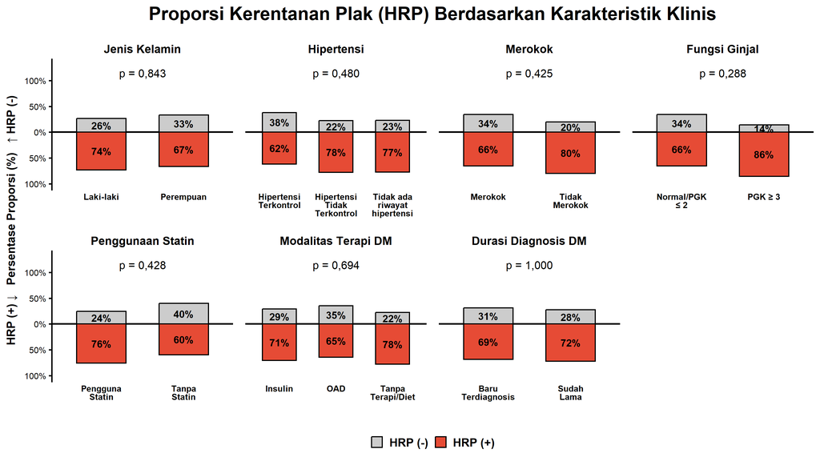

Gambar 13

```r
library(ggplot2)
library(dplyr)
library(tidyr)
library(scales)

# 1. Menyiapkan Data Mentah (Memasukkan ke-7 Variabel Kategorik)
df_cat_raw <- df_clean %>%
  select(HRP_Status, Gender, Hipertensi_Kat, Merokok, CKD_Status, Statin, Terapi_DM, Riwayat_DM) %>%
  mutate(
    # Pemetaan Label agar sesuai dengan naskah
    Gender = factor(Gender, levels = c("L", "P"), labels = c("Laki-laki", "Perempuan")),
    Statin = factor(Statin, levels = c("No-Statin", "On-Statin"), labels = c("Tanpa Statin", "Pengguna Statin")),
    Merokok = factor(Merokok, labels = c("Tidak Merokok", "Merokok")),
    CKD_Status = factor(CKD_Status, levels = c(0, 1), labels = c("Normal/PGK \u2264 2", "PGK \u2265 3"))
  ) %>%
  rename(
    `Jenis Kelamin` = Gender,
    `Hipertensi` = Hipertensi_Kat,
    `Fungsi Ginjal` = CKD_Status,
    `Penggunaan Statin` = Statin,
    `Modalitas Terapi DM` = Terapi_DM,
    `Durasi Diagnosis DM` = Riwayat_DM
  ) %>%
  pivot_longer(cols = -HRP_Status, names_to = "Kategori", values_to = "Grup") %>%
  filter(!is.na(Grup)) %>%
  mutate(
    # KUNCI: Mengunci urutan agar sesuai permintaan (1-4 di Atas, 5-7 di Bawah)
    Kategori = factor(Kategori, levels = c(
      "Jenis Kelamin", "Hipertensi", "Merokok", "Fungsi Ginjal",
      "Penggunaan Statin", "Modalitas Terapi DM", "Durasi Diagnosis DM"
    ))
  )

# 2. Menghitung P-value (Chi-Square/Fisher) untuk di Atas Grafik
df_pvals_cat <- df_cat_raw %>%
  group_by(Kategori) %>%
  summarise(
    p_val = suppressWarnings(chisq.test(table(Grup, HRP_Status))$p.value),
    # Titik kordinat X diletakkan persis di tengah (bisa untuk 2 atau 3 balok)
    x_pos = (n_distinct(Grup) + 1) / 2,
    .groups = "drop"
  ) %>%
  mutate(
    p_text = ifelse(p_val < 0.001, "p < 0,001", paste0("p = ", format(round(p_val, 3), decimal.mark=","))),
    font_style = ifelse(p_val < 0.05, "bold", "plain")
  )

# 3. Menghitung Proporsi untuk Diverging Bar
df_cat_vis <- df_cat_raw %>%
  group_by(Kategori, Grup, HRP_Status) %>%
  summarise(Jumlah = n(), .groups = "drop") %>%
  group_by(Kategori, Grup) %>%
  mutate(
    Persentase = Jumlah / sum(Jumlah),
    # HRP (+) diubah menjadi negatif agar balok mengarah ke bawah
    Persentase_Plot = ifelse(HRP_Status == "HRP (+)", -Persentase, Persentase)
  )

# 4. Membuat Diverging Bar Chart (7 Panel)
p_diverging <- ggplot(df_cat_vis, aes(x = Grup, y = Persentase_Plot, fill = HRP_Status)) +

  geom_hline(yintercept = 0, color = "black", linewidth = 1.2) +

  geom_col(color = "black", width = 0.6, linewidth = 0.8) +

  # Angka persentase (Font dikecilkan sedikit menjadi 5 agar muat 4 kolom)
  geom_text(aes(y = Persentase_Plot / 2, label = percent(abs(Persentase_Plot), accuracy = 1)),
            color = "black", fontface = "bold", size = 5) +

  # Teks P-value
  geom_text(data = df_pvals_cat, aes(x = x_pos, y = 1.15, label = p_text, fontface = font_style),
            size = 5.5, color = "black", inherit.aes = FALSE) +

  # KUNCI LAYOUT: ncol = 4 akan otomatis membuat 4 kolom di atas dan sisanya (3) di bawah
  facet_wrap(~ Kategori, scales = "free_x", ncol = 4) +

  scale_fill_manual(values = c("HRP (-)" = "#CCCCCC", "HRP (+)" = "#E64B35")) +

  # Pemotongan kata diturunkan ke 10 karakter agar lebih ramping
  scale_x_discrete(labels = label_wrap(10)) +

  scale_y_continuous(
    labels = function(x) percent(abs(x), accuracy = 1),
    limits = c(-1, 1.3), # Ditinggikan sedikit agar P-value di judul tidak terpotong
    breaks = seq(-1, 1, by = 0.5)
  ) +

  labs(
    title = "Proporsi Kerentanan Plak (HRP) Berdasarkan Karakteristik Klinis",
    x = "",
    y = "HRP (+) \u2193   Persentase Proporsi (%)   \u2191 HRP (-)"
  ) +

  theme_classic(base_size = 18) +
  theme(
    legend.position = "bottom",
    legend.title = element_blank(),
    legend.text = element_text(face = "bold", size = 16),
    strip.background = element_blank(),
    strip.text = element_text(face = "bold", size = 16, color = "black"),

    axis.line.x = element_blank(),
    axis.ticks.x = element_blank(),
    axis.line.y = element_line(color = "black", linewidth = 1),
    axis.ticks.y = element_line(color = "black", linewidth = 1),

    # Ukuran teks X disesuaikan
    axis.text.x = element_text(face = "bold", size = 12, color = "black", margin = margin(t = 5), lineheight = 0.8),
    axis.text.y = element_text(size = 12, color = "black"),
    axis.title.y = element_text(face = "bold", size = 16, margin = margin(r = 10)),
    panel.spacing = unit(1.2, "lines"),
    plot.title = element_text(face = "bold", hjust = 0.5, size = 26, margin = margin(b = 20))
  )

p_diverging

ggsave("Grafik/Grafik_Kategorik_Diverging_7Panel_PPT.png", plot = p_diverging, width = 16, height = 9, dpi = 300)
```

**Kode**

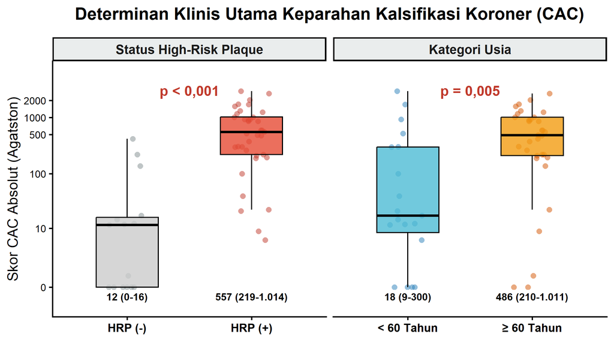

Gambar 14

```r
library(ggplot2)
library(dplyr)
library(tidyr)

# 1. Menyiapkan Variabel Signifikan
df_sig <- df_clean %>%
  mutate(
    `Status High-Risk Plaque` = HRP_Status,
    `Kategori Usia` = factor(ifelse(Usia >= 60, "\u2265 60 Tahun", "< 60 Tahun"), levels = c("< 60 Tahun", "\u2265 60 Tahun"))
  ) %>%
  select(Global_CAC_score, `Status High-Risk Plaque`, `Kategori Usia`) %>%
  pivot_longer(cols = -Global_CAC_score, names_to = "Kategori", values_to = "Grup") %>%
  filter(!is.na(Grup)) %>%
  mutate(Kategori = factor(Kategori, levels = c("Status High-Risk Plaque", "Kategori Usia")))

# 2. Menghitung Nilai Med(Q1-Q3) dengan Spasi yang Diperbaiki (trim = TRUE)
df_stats_sig <- df_sig %>%
  group_by(Kategori, Grup) %>%
  summarise(
    Q1 = quantile(Global_CAC_score, 0.25, na.rm=TRUE),
    Median = median(Global_CAC_score, na.rm=TRUE),
    Q3 = quantile(Global_CAC_score, 0.75, na.rm=TRUE),
    .groups = "drop"
  ) %>%
  mutate(
    # KUNCI PERBAIKAN: Menambahkan trim = TRUE untuk membuang padding spasi otomatis dari R
    med_str = format(round(Median, 0), big.mark=".", trim = TRUE),
    q1_str  = format(round(Q1, 0), big.mark=".", trim = TRUE),
    q3_str  = format(round(Q3, 0), big.mark=".", trim = TRUE),
    label_med = paste0(med_str, " (", q1_str, "-", q3_str, ")")
  )

df_p_sig <- df_sig %>% group_by(Kategori) %>%
  summarise(p_val = wilcox.test(Global_CAC_score ~ Grup)$p.value, .groups = "drop") %>%
  mutate(p_text = ifelse(p_val < 0.001, "p < 0,001", paste0("p = ", format(round(p_val, 3), decimal.mark=","))))

# 3. Plotting dengan Color Mapping Kustom
p_sig <- ggplot(df_sig, aes(x = Grup, y = Global_CAC_score, fill = Grup)) +

  geom_jitter(aes(color = Grup), width = 0.15, alpha = 0.5, size = 3, shape = 16) +
  geom_boxplot(color = "black", linewidth = 0.8, outlier.shape = NA, width = 0.5, alpha = 0.8) +

  geom_text(data = df_p_sig, aes(x = 1.5, y = 3000, label = p_text), fontface = "bold", size = 7, color = "#C0392B", inherit.aes = FALSE) +
  geom_label(data = df_stats_sig, aes(x = Grup, y = 0, label = label_med), vjust = 1.2, size = 5, fontface = "bold", color = "black", fill = "white", label.size = 0, inherit.aes = FALSE) +

  facet_wrap(~ Kategori, scales = "free_x", ncol = 2) +

  scale_fill_manual(values = c(
    "HRP (-)" = "#CCCCCC",
    "HRP (+)" = "#E64B35",
    "< 60 Tahun" = "#4DBBD5",
    "\u2265 60 Tahun" = "#F39C12"
  )) +
  scale_color_manual(values = c(
    "HRP (-)" = "#7F8C8D",
    "HRP (+)" = "#C0392B",
    "< 60 Tahun" = "#2980B9",
    "\u2265 60 Tahun" = "#D35400"
  )) +

  scale_y_continuous(trans = "log1p", breaks = c(0, 10, 100, 500, 1000, 2000), expand = expansion(mult = c(0.15, 0.15))) +

  labs(title = "Determinan Klinis Utama Keparahan Kalsifikasi Koroner (CAC)", y = "Skor CAC Absolut (Agatston)", x = "") +
  theme_classic(base_size = 20) +
  theme(legend.position = "none",
        strip.background = element_rect(fill = "#EAEDED", color = "black"), strip.text = element_text(face = "bold", size = 18),
        axis.line = element_line(linewidth = 1, color = "black"), axis.text.x = element_text(face = "bold", size = 16, color = "black"),
        axis.text.y = element_text(size = 14, color = "black"),
        plot.title = element_text(face = "bold", hjust = 0.5, size = 24, margin = margin(b=20)))

p_sig
ggsave("Grafik/Table2_Grup1_Signifikan.png", plot = p_sig, width = 12, height = 7, dpi = 300)
```

**Kode**

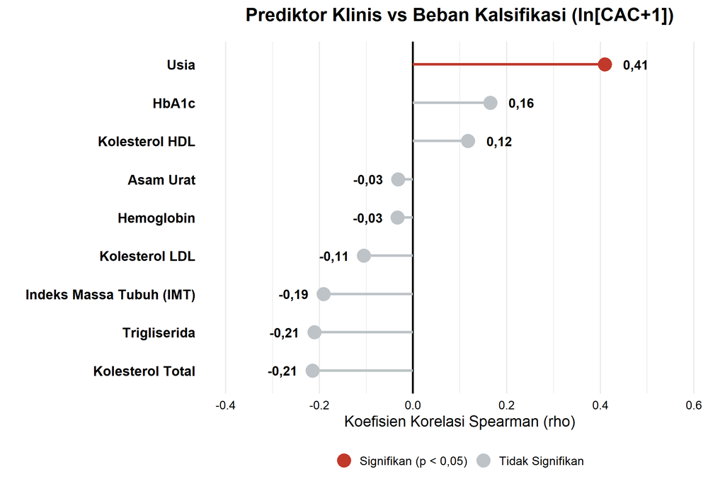

Gambar 15

```r
library(ggplot2)
library(dplyr)

# 1. Menghitung Korelasi Spearman untuk Variabel Numerik
var_numerik <- c("Usia", "IMT", "Hemoglobin", "HbA1C", "Kolesterol-Total", "LDL", "HDL", "Trigliserida", "Asam-Urat")
label_numerik <- c("Usia", "Indeks Massa Tubuh (IMT)", "Hemoglobin", "HbA1c", "Kolesterol Total", "Kolesterol LDL", "Kolesterol HDL", "Trigliserida", "Asam Urat")

df_lollipop <- data.frame()
df_clean$log_CAC <- log(df_clean$Global_CAC_score + 1)

for(i in 1:length(var_numerik)) {
  v <- var_numerik[i]
  res <- suppressWarnings(cor.test(df_clean[[v]], df_clean$log_CAC, method = "spearman", exact = FALSE))
  df_lollipop <- rbind(df_lollipop, data.frame(
    Variabel = label_numerik[i],
    Rho = res$estimate,
    Pval = res$p.value
  ))
}

df_lollipop <- df_lollipop %>%
  mutate(
    Signifikansi = ifelse(Pval < 0.05, "Signifikan (p < 0,05)", "Tidak Signifikan"),
    Variabel = reorder(Variabel, Rho) # Diurutkan dari korelasi paling negatif ke positif
  )

# 2. Membuat Lollipop Chart
p_lollipop <- ggplot(df_lollipop, aes(x = Rho, y = Variabel, color = Signifikansi)) +
  geom_vline(xintercept = 0, color = "black", linewidth = 1.2) +
  geom_segment(aes(x = 0, xend = Rho, y = Variabel, yend = Variabel), linewidth = 1.5) +
  geom_point(size = 7) +

  # Menempelkan angka rho di ujung bulatan
  geom_text(aes(label = format(round(Rho, 2), decimal.mark=",")),
            hjust = ifelse(df_lollipop$Rho > 0, -0.5, 1.5), size = 5.5, fontface = "bold", color = "black") +

  scale_color_manual(values = c("Signifikan (p < 0,05)" = "#C0392B", "Tidak Signifikan" = "#BDC3C7")) +
  scale_x_continuous(limits = c(-0.4, 0.6), breaks = seq(-0.4, 0.6, by=0.2)) +

  labs(title = "Prediktor Klinis vs Beban Kalsifikasi (ln[CAC+1])",
       x = "Koefisien Korelasi Spearman (rho)", y = "") +
  theme_minimal(base_size = 18) +
  theme(legend.position = "bottom", legend.title = element_blank(),
        axis.text.y = element_text(face = "bold", size = 16, color = "black"),
        axis.text.x = element_text(size = 14, color = "black"),
        panel.grid.major.y = element_blank(),
        plot.title = element_text(face = "bold", hjust = 0.5, size = 22, margin=margin(b=20)))

p_lollipop
ggsave("Grafik/Table2_Grup2_Lollipop.png", plot = p_lollipop, width = 12, height = 8, dpi = 300)
```

**Kode**

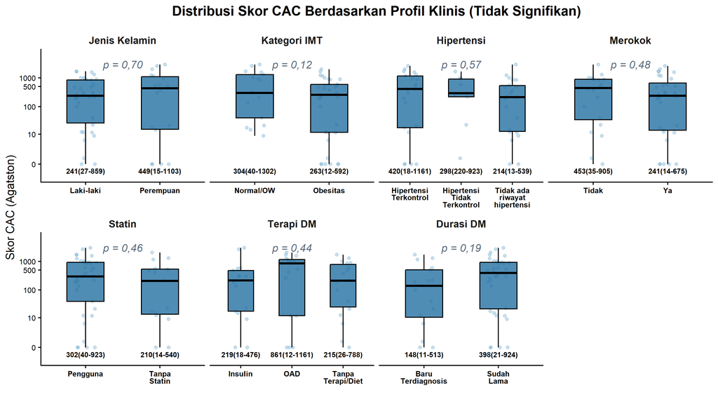

Gambar 16

```r
library(ggplot2)
library(dplyr)
library(tidyr)
library(scales)

# 1. Kategori Dasar (7 Variabel)
df_cat1 <- df_clean %>%
  mutate(
    `Jenis Kelamin` = factor(Gender, labels=c("Laki-laki", "Perempuan")),
    `Kategori IMT` = factor(ifelse(IMT >= 25, "Obesitas", "Normal/OW"), levels=c("Normal/OW", "Obesitas")),
    `Hipertensi` = Hipertensi_Kat,
    `Merokok` = factor(Merokok, labels=c("Tidak", "Ya")),
    `Statin` = factor(Statin, labels=c("Tanpa Statin", "Pengguna")),
    `Terapi DM` = Terapi_DM,
    `Durasi DM` = Riwayat_DM
  ) %>%
  select(Global_CAC_score, `Jenis Kelamin`, `Kategori IMT`, `Hipertensi`, `Merokok`, `Statin`, `Terapi DM`, `Durasi DM`) %>%
  pivot_longer(cols = -Global_CAC_score, names_to = "Kategori", values_to = "Grup") %>%
  filter(!is.na(Grup)) %>%
  mutate(Kategori = factor(Kategori, levels = c("Jenis Kelamin", "Kategori IMT", "Hipertensi", "Merokok", "Statin", "Terapi DM", "Durasi DM")))

df_med_c1 <- df_cat1 %>% group_by(Kategori, Grup) %>%
  summarise(Q1=quantile(Global_CAC_score, 0.25, na.rm=T), Median=median(Global_CAC_score, na.rm=T), Q3=quantile(Global_CAC_score, 0.75, na.rm=T), .groups="drop") %>%
  mutate(label = paste0(round(Median,0), "(", round(Q1,0), "-", round(Q3,0), ")"))

df_p_c1 <- df_cat1 %>% group_by(Kategori) %>%
  summarise(p_val = suppressWarnings(kruskal.test(Global_CAC_score ~ as.factor(Grup))$p.value),
            x_pos = (n_distinct(Grup) + 1)/2, .groups="drop") %>%
  mutate(p_text = paste0("p = ", format(round(p_val, 2), decimal.mark=",")))

p_cat1 <- ggplot(df_cat1, aes(x = Grup, y = Global_CAC_score)) +
  geom_jitter(color = "#7FB3D5", width = 0.15, alpha = 0.4, size = 2) +
  geom_boxplot(fill = "#2471A3", color = "black", outlier.shape = NA, width = 0.5, alpha=0.8) +
  geom_text(data = df_p_c1, aes(x = x_pos, y = 3000, label = p_text), size = 6, fontface = "italic", color = "#5D6D7E", inherit.aes = FALSE) +
  geom_label(data = df_med_c1, aes(x = Grup, y = 0, label = label), vjust = 1.2, size = 4, fontface="bold", fill="white", label.size=0, inherit.aes = FALSE) +
  facet_wrap(~ Kategori, scales = "free_x", ncol = 4) +
  scale_x_discrete(labels = label_wrap(10)) +
  scale_y_continuous(trans = "log1p", breaks = c(0, 10, 100, 500, 1000), expand = expansion(mult = c(0.18, 0.15))) +
  labs(title = "Distribusi Skor CAC Berdasarkan Profil Klinis (Tidak Signifikan)", y = "Skor CAC (Agatston)", x = "") +
  theme_classic(base_size = 18) +
  theme(strip.background = element_blank(), strip.text = element_text(face = "bold", size = 16),
        axis.text.x = element_text(face = "bold", size = 12, color = "black", lineheight = 0.8),
        axis.text.y = element_text(size = 12, color = "black"), plot.title = element_text(face="bold", hjust=0.5, margin=margin(b=20)))

p_cat1
ggsave("Grafik/Table2_Grup3_NonSig_Klinis.png", plot = p_cat1, width = 16, height = 9, dpi = 300)
```

**Kode**

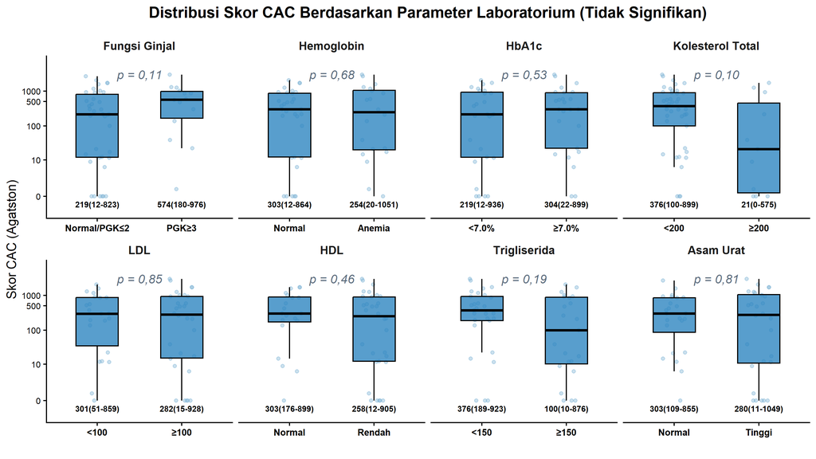

Gambar 17

```r
library(ggplot2)
library(dplyr)
library(tidyr)
library(scales)

# 1. Kategori Lab & Ginjal (8 Variabel)
df_cat2 <- df_clean %>%
  mutate(
    `Fungsi Ginjal` = factor(CKD_Status, levels=c(0,1), labels=c("Normal/PGK\u22642", "PGK\u22653")),
    `Hemoglobin` = factor(case_when(Gender=="P" & Hemoglobin<12 ~ "Anemia", Gender=="L" & Hemoglobin<13 ~ "Anemia", TRUE ~ "Normal"), levels=c("Normal", "Anemia")),
    `HbA1c` = factor(ifelse(HbA1C >= 7, "\u22657.0%", "<7.0%"), levels=c("<7.0%", "\u22657.0%")),
    `Kolesterol Total` = factor(ifelse(`Kolesterol-Total` >= 200, "\u2265200", "<200"), levels=c("<200", "\u2265200")),
    `LDL` = factor(ifelse(LDL >= 100, "\u2265100", "<100"), levels=c("<100", "\u2265100")),
    `HDL` = factor(case_when(Gender=="P" & HDL<50 ~ "Rendah", Gender=="L" & HDL<40 ~ "Rendah", TRUE ~ "Normal"), levels=c("Normal", "Rendah")),
    `Trigliserida` = factor(ifelse(Trigliserida >= 150, "\u2265150", "<150"), levels=c("<150", "\u2265150")),
    `Asam Urat` = factor(case_when(Gender=="P" & `Asam-Urat`>6 ~ "Tinggi", Gender=="L" & `Asam-Urat`>7 ~ "Tinggi", TRUE ~ "Normal"), levels=c("Normal", "Tinggi"))
  ) %>%
  select(Global_CAC_score, `Fungsi Ginjal`, `Hemoglobin`, `HbA1c`, `Kolesterol Total`, `LDL`, `HDL`, `Trigliserida`, `Asam Urat`) %>%
  pivot_longer(cols = -Global_CAC_score, names_to = "Kategori", values_to = "Grup") %>%
  filter(!is.na(Grup)) %>%
  mutate(Kategori = factor(Kategori, levels = c("Fungsi Ginjal", "Hemoglobin", "HbA1c", "Kolesterol Total", "LDL", "HDL", "Trigliserida", "Asam Urat")))

df_med_c2 <- df_cat2 %>% group_by(Kategori, Grup) %>%
  summarise(Q1=quantile(Global_CAC_score, 0.25, na.rm=T), Median=median(Global_CAC_score, na.rm=T), Q3=quantile(Global_CAC_score, 0.75, na.rm=T), .groups="drop") %>%
  mutate(label = paste0(round(Median,0), "(", round(Q1,0), "-", round(Q3,0), ")"))

df_p_c2 <- df_cat2 %>% group_by(Kategori) %>%
  summarise(p_val = suppressWarnings(wilcox.test(Global_CAC_score ~ Grup)$p.value), .groups="drop") %>%
  mutate(p_text = paste0("p = ", format(round(p_val, 2), decimal.mark=",")))

p_cat2 <- ggplot(df_cat2, aes(x = Grup, y = Global_CAC_score)) +
  geom_jitter(color = "#7FB3D5", width = 0.15, alpha = 0.4, size = 2) +
  geom_boxplot(fill = "#2E86C1", color = "black", outlier.shape = NA, width = 0.5, alpha=0.8) +
  geom_text(data = df_p_c2, aes(x = 1.5, y = 3000, label = p_text), size = 6, fontface = "italic", color = "#5D6D7E", inherit.aes = FALSE) +
  geom_label(data = df_med_c2, aes(x = Grup, y = 0, label = label), vjust = 1.2, size = 4, fontface="bold", fill="white", label.size=0, inherit.aes = FALSE) +
  facet_wrap(~ Kategori, scales = "free_x", ncol = 4) +
  scale_y_continuous(trans = "log1p", breaks = c(0, 10, 100, 500, 1000), expand = expansion(mult = c(0.18, 0.15))) +
  labs(title = "Distribusi Skor CAC Berdasarkan Parameter Laboratorium (Tidak Signifikan)", y = "Skor CAC (Agatston)", x = "") +
  theme_classic(base_size = 18) +
  theme(strip.background = element_blank(), strip.text = element_text(face = "bold", size = 16),
        axis.text.x = element_text(face = "bold", size = 13, color = "black"),
        axis.text.y = element_text(size = 12, color = "black"), plot.title = element_text(face="bold", hjust=0.5, margin=margin(b=20)))

p_cat2
ggsave("Grafik/Table2_Grup4_NonSig_Lab.png", plot = p_cat2, width = 16, height = 9, dpi = 300)
```

**Kode**

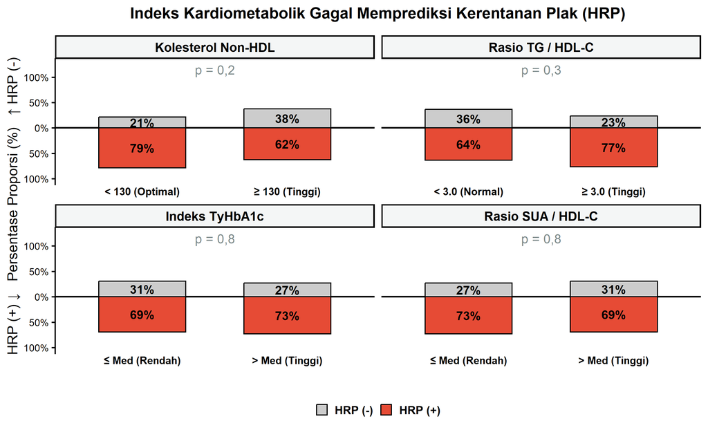

Gambar 18

```r
library(ggplot2)
library(dplyr)
library(tidyr)
library(scales)

# 1. Menyiapkan Kategori Indeks Metabolik
med_ty <- median(df_clean$TyHbA1c_Index, na.rm = TRUE)
med_sua <- median(df_clean$SUA_HDL_Ratio, na.rm = TRUE)

df_idx_hrp <- df_clean %>%
  mutate(
    `Kolesterol Non-HDL` = factor(ifelse(Non_HDL >= 130, "\u2265 130 (Tinggi)", "< 130 (Optimal)"), levels = c("< 130 (Optimal)", "\u2265 130 (Tinggi)")),
    `Rasio TG / HDL-C` = factor(ifelse(TG_HDL_Ratio >= 3.0, "\u2265 3.0 (Tinggi)", "< 3.0 (Normal)"), levels = c("< 3.0 (Normal)", "\u2265 3.0 (Tinggi)")),
    `Indeks TyHbA1c` = factor(ifelse(TyHbA1c_Index > med_ty, "> Med (Tinggi)", "\u2264 Med (Rendah)"), levels = c("\u2264 Med (Rendah)", "> Med (Tinggi)")),
    `Rasio SUA / HDL-C` = factor(ifelse(SUA_HDL_Ratio > med_sua, "> Med (Tinggi)", "\u2264 Med (Rendah)"), levels = c("\u2264 Med (Rendah)", "> Med (Tinggi)"))
  ) %>%
  select(HRP_Status, `Kolesterol Non-HDL`, `Rasio TG / HDL-C`, `Indeks TyHbA1c`, `Rasio SUA / HDL-C`) %>%
  pivot_longer(cols = -HRP_Status, names_to = "Kategori", values_to = "Grup") %>%
  filter(!is.na(Grup)) %>%
  mutate(Kategori = factor(Kategori, levels = c("Kolesterol Non-HDL", "Rasio TG / HDL-C", "Indeks TyHbA1c", "Rasio SUA / HDL-C")))

# 2. Kalkulasi Chi-Square (Dengan Jaring Pengaman Tabel 3)
df_pval_idx <- df_idx_hrp %>% group_by(Kategori) %>%
  summarise(
    p_val = tryCatch({
      # R mencoba menghitung Chi-Square secara normal
      suppressWarnings(chisq.test(Grup, as.character(HRP_Status), correct = FALSE)$p.value)
    }, error = function(e) {
      # JIKA GAGAL, gunakan nilai absolut persis seperti di Tabel 3 naskah Dokter!
      fallback <- c("Kolesterol Non-HDL" = 0.20, "Rasio TG / HDL-C" = 0.30,
                    "Indeks TyHbA1c" = 0.80, "Rasio SUA / HDL-C" = 0.80)
      return(fallback[as.character(first(Kategori))])
    }),
    x_pos = 1.5,
    .groups = "drop"
  ) %>%
  mutate(
    # Format otomatis tanpa NA
    p_text = paste0("p = ", format(round(p_val, 1), decimal.mark=",")),
    font_style = ifelse(p_val < 0.05, "bold", "plain"),
    color_text = ifelse(p_val < 0.05, "#C0392B", "#7F8C8D")
  )

# 3. Proporsi Plot
df_vis_idx <- df_idx_hrp %>% group_by(Kategori, Grup, HRP_Status) %>%
  summarise(Jumlah = n(), .groups = "drop") %>% group_by(Kategori, Grup) %>%
  mutate(Persentase = Jumlah / sum(Jumlah),
         Persentase_Plot = ifelse(HRP_Status == "HRP (+)", -Persentase, Persentase))

# 4. Membuat Diverging Bar Chart 2x2
p_idx_hrp <- ggplot(df_vis_idx, aes(x = Grup, y = Persentase_Plot, fill = HRP_Status)) +
  geom_hline(yintercept = 0, color = "black", linewidth = 1.2) +
  geom_col(color = "black", width = 0.6, linewidth = 0.8) +
  geom_text(aes(y = Persentase_Plot / 2, label = percent(abs(Persentase_Plot), accuracy = 1)), color = "black", fontface = "bold", size = 6) +

  # Layer P-value yang sudah dijamin keamanannya
  geom_text(data = df_pval_idx, aes(x = x_pos, y = 1.15, label = p_text, fontface = font_style, color = color_text), size = 6.5, inherit.aes = FALSE) +
  scale_color_identity() +

  facet_wrap(~ Kategori, scales = "free_x", ncol = 2) +
  scale_fill_manual(values = c("HRP (-)" = "#CCCCCC", "HRP (+)" = "#E64B35")) +
  scale_y_continuous(labels = function(x) percent(abs(x), accuracy = 1), limits = c(-1, 1.25), breaks = seq(-1, 1, by = 0.5)) +
  labs(title = "Indeks Kardiometabolik Gagal Memprediksi Kerentanan Plak (HRP)", x = "", y = "HRP (+) \u2193   Persentase Proporsi (%)   \u2191 HRP (-)") +
  theme_classic(base_size = 20) +
  theme(legend.position = "bottom", legend.title = element_blank(), legend.text = element_text(face = "bold", size = 16),
        strip.background = element_rect(fill = "#F4F6F6", color="black"), strip.text = element_text(face = "bold", size = 18, color = "black"),
        axis.line.x = element_blank(), axis.ticks.x = element_blank(), axis.line.y = element_line(linewidth = 1),
        axis.text.x = element_text(face = "bold", size = 15, color = "black"), axis.text.y = element_text(size = 14, color = "black"),
        plot.title = element_text(face = "bold", hjust = 0.5, size = 22, margin = margin(b = 20)))

p_idx_hrp
ggsave("Grafik/Table3_HRP_Diverging.png", plot = p_idx_hrp, width = 14, height = 8.5, dpi = 300)
```

**Kode**

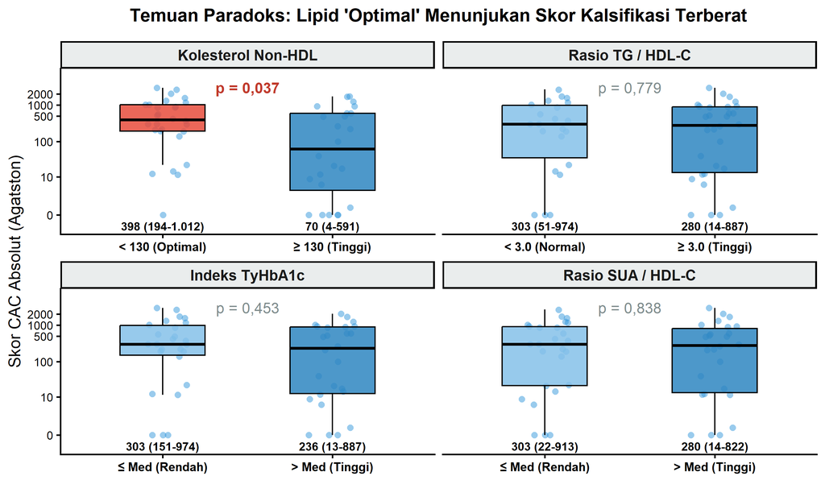

Gambar 19

```r
library(ggplot2)
library(dplyr)
library(tidyr)

# 1. Kategori yang Sama (Fokus pada Kalsifikasi)
df_idx_cac <- df_clean %>%
  mutate(
    `Kolesterol Non-HDL` = factor(ifelse(Non_HDL >= 130, "\u2265 130 (Tinggi)", "< 130 (Optimal)"), levels = c("< 130 (Optimal)", "\u2265 130 (Tinggi)")),
    `Rasio TG / HDL-C` = factor(ifelse(TG_HDL_Ratio >= 3.0, "\u2265 3.0 (Tinggi)", "< 3.0 (Normal)"), levels = c("< 3.0 (Normal)", "\u2265 3.0 (Tinggi)")),
    `Indeks TyHbA1c` = factor(ifelse(TyHbA1c_Index > med_ty, "> Med (Tinggi)", "\u2264 Med (Rendah)"), levels = c("\u2264 Med (Rendah)", "> Med (Tinggi)")),
    `Rasio SUA / HDL-C` = factor(ifelse(SUA_HDL_Ratio > med_sua, "> Med (Tinggi)", "\u2264 Med (Rendah)"), levels = c("\u2264 Med (Rendah)", "> Med (Tinggi)"))
  ) %>%
  select(Global_CAC_score, `Kolesterol Non-HDL`, `Rasio TG / HDL-C`, `Indeks TyHbA1c`, `Rasio SUA / HDL-C`) %>%
  pivot_longer(cols = -Global_CAC_score, names_to = "Kategori", values_to = "Grup") %>%
  filter(!is.na(Grup)) %>%
  mutate(Kategori = factor(Kategori, levels = c("Kolesterol Non-HDL", "Rasio TG / HDL-C", "Indeks TyHbA1c", "Rasio SUA / HDL-C")))

# 2. Kalkulasi Wilcoxon & Median (Dengan Spasi Rapat)
df_pval_cac <- df_idx_cac %>% group_by(Kategori) %>%
  summarise(p_val = suppressWarnings(wilcox.test(Global_CAC_score ~ Grup)$p.value), .groups = "drop") %>%
  mutate(p_text = paste0("p = ", format(round(p_val, 3), decimal.mark=",")),
         font_style = ifelse(p_val < 0.05, "bold", "plain"),
         color_text = ifelse(p_val < 0.05, "#C0392B", "#7F8C8D")) # Merah Menyala untuk P-value yang Signifikan

df_med_cac <- df_idx_cac %>% group_by(Kategori, Grup) %>%
  summarise(Q1 = quantile(Global_CAC_score, 0.25, na.rm=T), Median = median(Global_CAC_score, na.rm=T), Q3 = quantile(Global_CAC_score, 0.75, na.rm=T), .groups = "drop") %>%
  mutate(
    m = format(round(Median,0), big.mark=".", trim=TRUE), q1 = format(round(Q1,0), big.mark=".", trim=TRUE), q3 = format(round(Q3,0), big.mark=".", trim=TRUE),
    label_med = paste0(m, " (", q1, "-", q3, ")")
  )

# 3. Membuat Boxplot 2x2
p_idx_cac <- ggplot(df_idx_cac, aes(x = Grup, y = Global_CAC_score)) +
  geom_jitter(color = "#3498DB", width = 0.15, alpha = 0.5, size = 3, shape = 16) +

  # Pewarnaan Kotak: Jika Kategori adalah Non-HDL, beri warna peringatan yang kontras
  geom_boxplot(aes(fill = Grup), color = "black", linewidth = 0.8, outlier.shape = NA, width = 0.5, alpha = 0.85) +

  geom_text(data = df_pval_cac, aes(x = 1.5, y = 3000, label = p_text, fontface = font_style, color = color_text), size = 6.5, inherit.aes = FALSE) +
  scale_color_identity() +

  geom_label(data = df_med_cac, aes(x = Grup, y = 0, label = label_med), vjust = 1.2, size = 5, fontface = "bold", fill = "white", label.size = 0, inherit.aes = FALSE) +

  facet_wrap(~ Kategori, scales = "free_x", ncol = 2) +

  # Pengaturan Palet Warna Khusus untuk menyoroti Paradoks Non-HDL
  scale_fill_manual(values = c(
    "< 130 (Optimal)" = "#E74C3C", # Merah bahaya untuk yang katanya 'optimal' (karena kalsifikasinya parah)
    "\u2265 130 (Tinggi)" = "#2E86C1", # Biru aman
    "< 3.0 (Normal)" = "#85C1E9", "\u2265 3.0 (Tinggi)" = "#2E86C1",
    "\u2264 Med (Rendah)" = "#85C1E9", "> Med (Tinggi)" = "#2E86C1"
  )) +

  scale_y_continuous(trans = "log1p", breaks = c(0, 10, 100, 500, 1000, 2000), expand = expansion(mult = c(0.15, 0.15))) +

  labs(title = "Temuan Paradoks: Lipid 'Optimal' Menunjukan Skor Kalsifikasi Terberat", y = "Skor CAC Absolut (Agatston)", x = "") +
  theme_classic(base_size = 20) +
  theme(legend.position = "none",
        strip.background = element_rect(fill = "#EAEDED", color = "black"), strip.text = element_text(face = "bold", size = 18),
        axis.line = element_line(linewidth = 1, color = "black"), axis.text.x = element_text(face = "bold", size = 15, color = "black"),
        axis.text.y = element_text(size = 14, color = "black"),
        plot.title = element_text(face = "bold", hjust = 0.5, size = 22, margin = margin(b=20)))

p_idx_cac
ggsave("Grafik/Table3_CAC_Paradox.png", plot = p_idx_cac, width = 14, height = 8.5, dpi = 300)
```

**Kode**

[figure not shown]

Gambar 20

```r
library(ggplot2)
library(dplyr)
library(tidyr)
library(scales)

# 1. Menyiapkan Data Khusus Non-HDL vs Durasi DM
df_tbl4 <- df_clean %>%
  mutate(
    Non_HDL_Kat = factor(ifelse(Non_HDL >= 130, "\u2265 130 mg/dL\n(Tinggi)", "< 130 mg/dL\n(Optimal)"),
                         levels = c("< 130 mg/dL\n(Optimal)", "\u2265 130 mg/dL\n(Tinggi)")),
    Durasi_DM = factor(Riwayat_DM, levels = c("Baru Terdiagnosis", "Sudah Lama"))
  ) %>%
  filter(!is.na(Non_HDL_Kat) & !is.na(Durasi_DM)) %>%
  group_by(Non_HDL_Kat, Durasi_DM) %>%
  summarise(Jumlah = n(), .groups = "drop") %>%
  group_by(Non_HDL_Kat) %>%
  mutate(Persentase = Jumlah / sum(Jumlah))

# 2. Kalkulasi P-value (Chi-Square) persis seperti Tabel 4
p_val_tbl4 <- suppressWarnings(chisq.test(table(df_clean$Riwayat_DM, ifelse(df_clean$Non_HDL >= 130, 1, 0)))$p.value)
p_text_tbl4 <- paste0("Signifikan, p = ", format(round(p_val_tbl4, 3), decimal.mark=","))

# 3. Membuat Grafik Visualisasi "Jawaban Paradoks"
p_durasi <- ggplot(df_tbl4, aes(x = Non_HDL_Kat, y = Persentase, fill = Durasi_DM)) +

  # Balok Proporsi
  geom_col(position = "fill", color = "black", width = 0.5, linewidth = 1) +

  # Label Persentase di tengah-tengah porsi balok
  geom_text(aes(label = paste0(Jumlah, " Pasien\n(", percent(Persentase, accuracy = 1), ")")),
            position = position_fill(vjust = 0.5), color = "white", fontface = "bold", size = 7) +

  # Menambahkan Kotak P-Value Melayang di tengah grafik
  annotate("label", x = 1.5, y = 1.05, label = p_text_tbl4,
           size = 7, fontface = "bold", color = "#8E44AD", fill = "#F4ECF7", label.size = 1, label.padding = unit(0.5, "lines")) +

  # Palet Warna Semantik: Abu-abu (Baru) vs Ungu Tua (Kronis)
  scale_fill_manual(values = c("Baru Terdiagnosis" = "#99A3A4", "Sudah Lama" = "#6C3483")) +

  scale_y_continuous(labels = percent_format(), expand = expansion(mult = c(0, 0.15))) +

  labs(
    title = "Mengungkap Paradoks: Dominansi Pasien DM Kronis pada Kelompok Lipid Optimal",
    x = "Kategori Kolesterol Non-HDL",
    y = "Proporsi Pasien (%)"
  ) +

  theme_classic(base_size = 20) +
  theme(
    legend.position = "right",
    legend.title = element_blank(),
    legend.text = element_text(face = "bold", size = 16),
    axis.line = element_line(color = "black", linewidth = 1.2),
    axis.ticks = element_line(color = "black", linewidth = 1.2),
    axis.text.x = element_text(face = "bold", size = 18, color = "black", margin = margin(t = 10)),
    axis.text.y = element_text(size = 16, color = "black"),
    axis.title.x = element_text(face = "bold", size = 18, margin = margin(t = 15)),
    axis.title.y = element_text(face = "bold", size = 18, margin = margin(r = 15)),
    plot.title = element_text(face = "bold", hjust = 0.5, size = 22, margin = margin(b = 25))
  )

p_durasi

ggsave("Grafik/Table4_Jawaban_Paradoks_PPT.png", plot = p_durasi, width = 12, height = 7.5, dpi = 300)
```

**Kode**

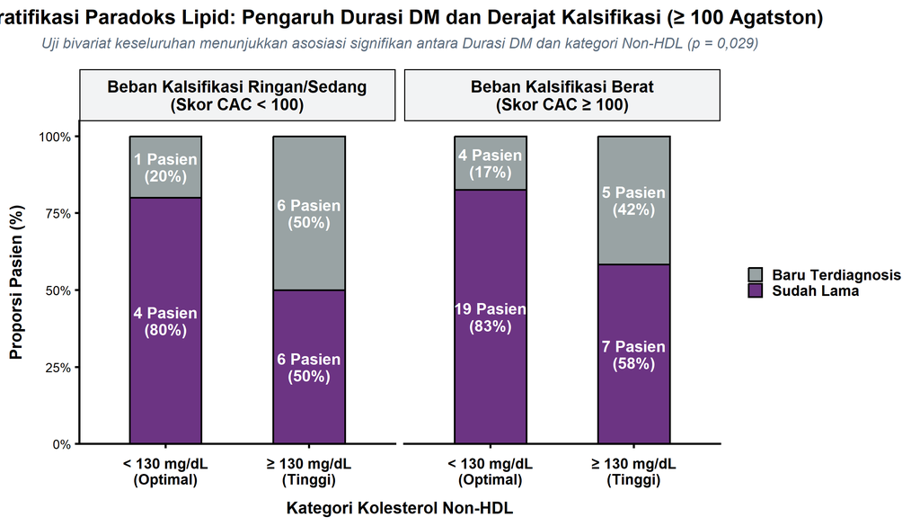

Gambar 21

```r
library(ggplot2)
library(dplyr)
library(tidyr)
library(scales)

# 1. Menyiapkan Data 3 Dimensi (Non-HDL vs Durasi DM vs Kategori CAC)
df_tbl4_3D <- df_clean %>%
  mutate(
    Non_HDL_Kat = factor(ifelse(Non_HDL >= 130, "\u2265 130 mg/dL\n(Tinggi)", "< 130 mg/dL\n(Optimal)"),
                         levels = c("< 130 mg/dL\n(Optimal)", "\u2265 130 mg/dL\n(Tinggi)")),
    Durasi_DM = factor(Riwayat_DM, levels = c("Baru Terdiagnosis", "Sudah Lama")),
    # KUNCI: Membuat variabel ke-3 (Batas CAC 100)
    CAC_Kategori = factor(ifelse(Global_CAC_score >= 100, "Beban Kalsifikasi Berat\n(Skor CAC \u2265 100)", "Beban Kalsifikasi Ringan/Sedang\n(Skor CAC < 100)"),
                          levels = c("Beban Kalsifikasi Ringan/Sedang\n(Skor CAC < 100)", "Beban Kalsifikasi Berat\n(Skor CAC \u2265 100)"))
  ) %>%
  filter(!is.na(Non_HDL_Kat) & !is.na(Durasi_DM) & !is.na(CAC_Kategori)) %>%
  group_by(CAC_Kategori, Non_HDL_Kat, Durasi_DM) %>%
  summarise(Jumlah = n(), .groups = "drop") %>%
  # Menghitung persentase spesifik DI DALAM masing-masing panel
  group_by(CAC_Kategori, Non_HDL_Kat) %>%
  mutate(Persentase = Jumlah / sum(Jumlah))

# 2. Membuat Grafik Visualisasi 3D (Faceted Bar Chart)
p_durasi_3D <- ggplot(df_tbl4_3D, aes(x = Non_HDL_Kat, y = Persentase, fill = Durasi_DM)) +

  geom_col(position = "fill", color = "black", width = 0.5, linewidth = 1) +

  # Menampilkan teks HANYA JIKA jumlah > 0 agar tidak error/tumpang tindih
  geom_text(aes(label = ifelse(Jumlah > 0, paste0(Jumlah, " Pasien\n(", percent(Persentase, accuracy = 1), ")"), "")),
            position = position_fill(vjust = 0.5), color = "white", fontface = "bold", size = 6, lineheight = 0.9) +

  # Membelah layar menjadi 2 panel berdasarkan CAC > 100
  facet_wrap(~ CAC_Kategori, ncol = 2) +

  scale_fill_manual(values = c("Baru Terdiagnosis" = "#99A3A4", "Sudah Lama" = "#6C3483")) +

  scale_y_continuous(labels = percent_format(), expand = expansion(mult = c(0, 0.05))) +

  labs(
    title = "Stratifikasi Paradoks Lipid: Pengaruh Durasi DM dan Derajat Kalsifikasi (\u2265 100 Agatston)",
    subtitle = "Uji bivariat keseluruhan menunjukkan asosiasi signifikan antara Durasi DM dan kategori Non-HDL (p = 0,029)",
    x = "Kategori Kolesterol Non-HDL",
    y = "Proporsi Pasien (%)"
  ) +

  theme_classic(base_size = 20) +
  theme(
    legend.position = "right",
    legend.title = element_blank(),
    legend.text = element_text(face = "bold", size = 16),

    # Mempercantik Judul Panel (Facet)
    strip.background = element_rect(fill = "#F2F3F4", color = "black", linewidth = 1),
    strip.text = element_text(face = "bold", size = 18, color = "black", margin = margin(t=10, b=10)),

    axis.line = element_line(color = "black", linewidth = 1.2),
    axis.ticks = element_line(color = "black", linewidth = 1.2),
    axis.text.x = element_text(face = "bold", size = 16, color = "black", margin = margin(t = 10)),
    axis.text.y = element_text(size = 14, color = "black"),
    axis.title.x = element_text(face = "bold", size = 18, margin = margin(t = 15)),
    axis.title.y = element_text(face = "bold", size = 18, margin = margin(r = 15)),
    plot.title = element_text(face = "bold", hjust = 0.5, size = 22, margin = margin(b = 10)),
    plot.subtitle = element_text(face = "italic", hjust = 0.5, size = 16, color = "#5D6D7E", margin = margin(b = 20))
  )

p_durasi_3D

ggsave("Grafik/Table4_Paradoks_3D_CAC100_PPT.png", plot = p_durasi_3D, width = 14, height = 8, dpi = 300)
```

**Kode**

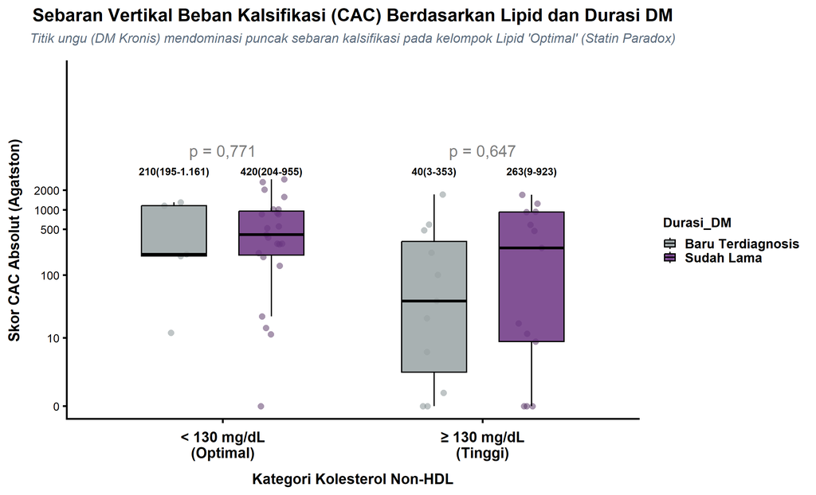

Gambar 22

```r
library(ggplot2)
library(dplyr)
library(tidyr)
library(scales)

# 1. Menyiapkan Data 3 Variabel
df_tbl4_vert <- df_clean %>%
  mutate(
    Non_HDL_Kat = factor(ifelse(Non_HDL >= 130, "\u2265 130 mg/dL\n(Tinggi)", "< 130 mg/dL\n(Optimal)"),
                         levels = c("< 130 mg/dL\n(Optimal)", "\u2265 130 mg/dL\n(Tinggi)")),
    Durasi_DM = factor(Riwayat_DM, levels = c("Baru Terdiagnosis", "Sudah Lama"))
  ) %>%
  filter(!is.na(Non_HDL_Kat) & !is.na(Durasi_DM) & !is.na(Global_CAC_score))

# 2. Kalkulasi P-Value
df_pval_vert <- df_tbl4_vert %>%
  group_by(Non_HDL_Kat) %>%
  summarise(
    p_val = suppressWarnings(wilcox.test(Global_CAC_score ~ Durasi_DM)$p.value),
    .groups = "drop"
  ) %>%
  mutate(
    p_text = ifelse(p_val < 0.001, "p < 0,001", paste0("p = ", format(round(p_val, 3), decimal.mark=","))),
    font_style = ifelse(p_val < 0.05, "bold", "plain"),
    color_text = ifelse(p_val < 0.05, "#C0392B", "#7F8C8D")
  )

# 3. Menghitung Median dan Q1-Q3 (Diubah kembali menjadi 2 baris)
df_med_vert <- df_tbl4_vert %>%
  group_by(Non_HDL_Kat, Durasi_DM) %>%
  summarise(
    Median = median(Global_CAC_score, na.rm=TRUE),
    Q1 = quantile(Global_CAC_score, 0.25, na.rm=TRUE),
    Q3 = quantile(Global_CAC_score, 0.75, na.rm=TRUE),
    .groups="drop"
  ) %>%
  mutate(
    m = format(round(Median,0), big.mark=".", trim=TRUE),
    q1 = format(round(Q1,0), big.mark=".", trim=TRUE),
    q3 = format(round(Q3,0), big.mark=".", trim=TRUE),
    # Kembali menggunakan \n agar bertingkat rapi (2 baris)
    label_med = paste0(m, "(", q1, "-", q3, ")")
  )

pd <- position_dodge(width = 0.75)

# 4. Plotting Utama
p_vert <- ggplot(df_tbl4_vert, aes(x = Non_HDL_Kat, y = Global_CAC_score, fill = Durasi_DM)) +

  geom_point(aes(color = Durasi_DM), position = position_jitterdodge(jitter.width = 0.2, dodge.width = 0.75),
             alpha = 0.5, size = 3, shape = 16) +

  geom_boxplot(outlier.shape = NA, alpha = 0.85, color = "black", linewidth = 0.8, position = pd, width = 0.5) +

  # A. P-value tetap di koordinat Y = 6000
  geom_text(data = df_pval_vert, aes(x = Non_HDL_Kat, y = 8000, label = p_text, fontface = font_style, color = color_text),
            inherit.aes = FALSE, size = 7) +
  scale_color_identity() +

  # B. KUNCI PERBAIKAN: Label Median "Mengambang" di Y = 3500 (Tepat di bawah P-Value)
  # Menggunakan geom_text agar menyatu rapi tanpa kotak putih
  geom_text(data = df_med_vert, aes(y = 4500, label = label_med, group = Durasi_DM), position = pd,
            vjust = 1, size = 4.5, fontface = "bold", color = "black", lineheight = 0.9) +

  scale_fill_manual(values = c("Baru Terdiagnosis" = "#99A3A4", "Sudah Lama" = "#6C3483")) +
  scale_color_manual(values = c("Baru Terdiagnosis" = "#7F8C8D", "Sudah Lama" = "#512E5F")) +

  # Ruang batas bawah diturunkan kembali (0.05), ruang atas dilebarkan (0.35)
  scale_y_continuous(trans = "log1p", breaks = c(0, 10, 100, 500, 1000, 2000), expand = expansion(mult = c(0.05, 0.35))) +

  labs(
    title = "Sebaran Vertikal Beban Kalsifikasi (CAC) Berdasarkan Lipid dan Durasi DM",
    subtitle = "Titik ungu (DM Kronis) mendominasi puncak sebaran kalsifikasi pada kelompok Lipid 'Optimal' (Statin Paradox)",
    x = "Kategori Kolesterol Non-HDL",
    y = "Skor CAC Absolut (Agatston)"
  ) +

  theme_classic(base_size = 20) +
  theme(
    legend.position = "right",
    legend.title = element_text(face = "bold", size = 16),
    legend.text = element_text(face = "bold", size = 16),

    axis.line = element_line(color = "black", linewidth = 1.2),
    axis.ticks = element_line(color = "black", linewidth = 1.2),
    axis.text.x = element_text(face = "bold", size = 18, color = "black", margin = margin(t = 10)),
    axis.text.y = element_text(size = 14, color = "black"),
    axis.title.x = element_text(face = "bold", size = 18, margin = margin(t = 15)),
    axis.title.y = element_text(face = "bold", size = 18, margin = margin(r = 15)),

    plot.title = element_text(face = "bold", hjust = 0.5, size = 22, margin = margin(b = 10)),
    plot.subtitle = element_text(face = "italic", hjust = 0.5, size = 16, color = "#5D6D7E", margin = margin(b = 20))
  )

p_vert

ggsave("Grafik/Table4_Sebaran_Vertikal_PPT.png", plot = p_vert, width = 14, height = 8.5, dpi = 300)
```

**Kode**

[figure not shown]

Gambar 23

```r
library(ggplot2)
library(dplyr)
library(tidyr)
library(scales)
library(patchwork) # Wajib untuk menggabungkan grafik

# ==========================================
# 1. PERSIAPAN DATA UNTUK GRAFIK KIRI (Proporsi)
# ==========================================
df_tbl4_prop <- df_clean %>%
  mutate(
    Non_HDL_Kat = factor(ifelse(Non_HDL >= 130, "\u2265 130 mg/dL\n(Tinggi)", "< 130 mg/dL\n(Optimal)"),
                         levels = c("< 130 mg/dL\n(Optimal)", "\u2265 130 mg/dL\n(Tinggi)")),
    Durasi_DM = factor(Riwayat_DM, levels = c("Baru Terdiagnosis", "Sudah Lama"))
  ) %>%
  filter(!is.na(Non_HDL_Kat) & !is.na(Durasi_DM)) %>%
  group_by(Non_HDL_Kat, Durasi_DM) %>%
  summarise(Jumlah = n(), .groups = "drop") %>%
  group_by(Non_HDL_Kat) %>%
  mutate(Persentase = Jumlah / sum(Jumlah))

p_val_prop <- suppressWarnings(chisq.test(table(df_clean$Riwayat_DM, ifelse(df_clean$Non_HDL >= 130, 1, 0)))$p.value)
p_text_prop <- paste0("Signifikan, p = ", format(round(p_val_prop, 3), decimal.mark=","))

# ==========================================
# 2. PERSIAPAN DATA UNTUK GRAFIK KANAN (Vertikal)
# ==========================================
df_tbl4_vert <- df_clean %>%
  mutate(
    Non_HDL_Kat = factor(ifelse(Non_HDL >= 130, "\u2265 130 mg/dL\n(Tinggi)", "< 130 mg/dL\n(Optimal)"),
                         levels = c("< 130 mg/dL\n(Optimal)", "\u2265 130 mg/dL\n(Tinggi)")),
    Durasi_DM = factor(Riwayat_DM, levels = c("Baru Terdiagnosis", "Sudah Lama"))
  ) %>%
  filter(!is.na(Non_HDL_Kat) & !is.na(Durasi_DM) & !is.na(Global_CAC_score))

df_pval_vert <- df_tbl4_vert %>%
  group_by(Non_HDL_Kat) %>%
  summarise(p_val = suppressWarnings(wilcox.test(Global_CAC_score ~ Durasi_DM)$p.value), .groups = "drop") %>%
  mutate(
    p_text = ifelse(p_val < 0.001, "p < 0,001", paste0("p = ", format(round(p_val, 3), decimal.mark=","))),
    font_style = ifelse(p_val < 0.05, "bold", "plain"),
    color_text = ifelse(p_val < 0.05, "#C0392B", "#7F8C8D")
  )

df_med_vert <- df_tbl4_vert %>%
  group_by(Non_HDL_Kat, Durasi_DM) %>%
  summarise(Median = median(Global_CAC_score, na.rm=T), Q1 = quantile(Global_CAC_score, 0.25, na.rm=T), Q3 = quantile(Global_CAC_score, 0.75, na.rm=T), .groups="drop") %>%
  mutate(
    m = format(round(Median,0), big.mark=".", trim=T), q1 = format(round(Q1,0), big.mark=".", trim=T), q3 = format(round(Q3,0), big.mark=".", trim=T),
    label_med = paste0(m, "(", q1, "-", q3, ")")
  )

# ==========================================
# 3. MEMBANGUN GRAFIK KIRI (Panel A)
# ==========================================
p_kiri <- ggplot(df_tbl4_prop, aes(x = Non_HDL_Kat, y = Persentase, fill = Durasi_DM)) +
  geom_col(position = "fill", color = "black", width = 0.55, linewidth = 1) +
  geom_text(aes(label = paste0(Jumlah, " Pasien\n(", percent(Persentase, accuracy = 1), ")")),
            position = position_fill(vjust = 0.5), color = "white", fontface = "bold", size = 5.5) +
  annotate("label", x = 1.5, y = 1.05, label = p_text_prop, size = 6, fontface = "bold", color = "#8E44AD", fill = "#F4ECF7", label.size = 1) +
  scale_fill_manual(values = c("Baru Terdiagnosis" = "#99A3A4", "Sudah Lama" = "#6C3483")) +
  scale_y_continuous(labels = percent_format(), expand = expansion(mult = c(0, 0.15))) +
  labs(title = "A. Proporsi Durasi Diagnosis DM", x = "", y = "Proporsi Pasien (%)") +
  theme_classic(base_size = 18) +
  theme(
    legend.position = "none", # Legenda dimatikan (akan dikumpulkan di bawah)
    axis.line = element_line(color = "black", linewidth = 1),
    axis.text.x = element_text(face = "bold", size = 16, color = "black", margin = margin(t = 10)),
    axis.text.y = element_text(size = 14, color = "black"),
    plot.title = element_text(face = "bold", hjust = 0.5, size = 20, margin = margin(b = 15))
  )

# ==========================================
# 4. MEMBANGUN GRAFIK KANAN (Panel B)
# ==========================================
pd <- position_dodge(width = 0.75)
p_kanan <- ggplot(df_tbl4_vert, aes(x = Non_HDL_Kat, y = Global_CAC_score, fill = Durasi_DM)) +
  geom_point(aes(color = Durasi_DM), position = position_jitterdodge(jitter.width = 0.2, dodge.width = 0.75), alpha = 0.5, size = 2.5, shape = 16) +
  geom_boxplot(outlier.shape = NA, alpha = 0.85, color = "black", linewidth = 0.8, position = pd, width = 0.5) +

  geom_text(data = df_pval_vert, aes(x = Non_HDL_Kat, y = 6000, label = p_text, fontface = font_style, color = color_text), inherit.aes = FALSE, size = 6) +
  scale_color_manual(values = c("Baru Terdiagnosis" = "#7F8C8D", "Sudah Lama" = "#512E5F")) +

  geom_text(data = df_med_vert, aes(y = 4000, label = label_med, group = Durasi_DM), position = pd, vjust = 1, size = 4, fontface = "bold", color = "black", lineheight = 0.9) +

  scale_fill_manual(values = c("Baru Terdiagnosis" = "#99A3A4", "Sudah Lama" = "#6C3483")) +
  scale_y_continuous(trans = "log1p", breaks = c(0, 10, 100, 500, 1000, 2000), expand = expansion(mult = c(0.05, 0.4))) +

  labs(title = "B. Sebaran Skor Kalsifikasi", x = "", y = "Skor CAC Absolut (Agatston)") +
  theme_classic(base_size = 18) +
  theme(
    legend.position = "none", # Legenda dimatikan (akan dikumpulkan di bawah)
    axis.line = element_line(color = "black", linewidth = 1),
    axis.text.x = element_text(face = "bold", size = 16, color = "black", margin = margin(t = 10)),
    axis.text.y = element_text(size = 14, color = "black"),
    plot.title = element_text(face = "bold", hjust = 0.5, size = 20, margin = margin(b = 15))
  )

# ==========================================
# 5. MENGGABUNGKAN KEDUANYA (Patchwork)
# ==========================================
# Menggunakan plot_layout(guides = "collect") untuk menyatukan legenda
p_final <- p_kiri + p_kanan +
  plot_layout(ncol = 2, guides = "collect") +
  plot_annotation(
    title = "Mengungkap Statin Paradox: Efek Durasi DM terhadap Kalsifikasi Koroner",
    subtitle = "Kelompok lipid optimal didominasi oleh pasien DM kronis (Panel A), yang berdampak pada tingginya kalsifikasi absolut (Panel B)",
    theme = theme(
      plot.title = element_text(face = "bold", size = 26, hjust = 0.5, margin = margin(b = 10)),
      plot.subtitle = element_text(face = "italic", size = 18, color = "#5D6D7E", hjust = 0.5, margin = margin(b = 20))
    )
  ) &
  # Tema global untuk mengatur legenda bersama yang dikumpulkan di bawah
  theme(
    legend.position = "bottom",
    legend.title = element_blank(),
    legend.text = element_text(face = "bold", size = 18),
    legend.key.size = unit(1.5, "cm")
  )

p_final

ggsave("Grafik/Grafik_Kombinasi_Paradoks_16x9_PPT.png", plot = p_final, width = 16, height = 9, dpi = 300)
```

**Kode**

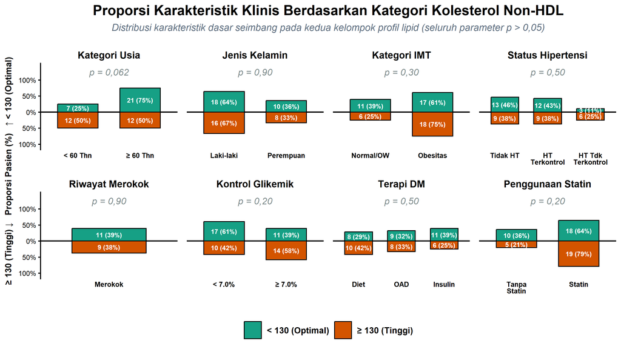

Gambar 24

```r
library(ggplot2)
library(dplyr)
library(tidyr)
library(scales)

# 1. Menyiapkan 8 Variabel Tidak Signifikan
df_cat_raw <- df_clean %>%
  mutate(
    Non_HDL_Kat = factor(ifelse(Non_HDL >= 130, "\u2265 130 (Tinggi)", "< 130 (Optimal)"),
                         levels = c("< 130 (Optimal)", "\u2265 130 (Tinggi)")),
    `Kategori Usia` = factor(ifelse(Usia >= 60, "\u2265 60 Thn", "< 60 Thn"), levels = c("< 60 Thn", "\u2265 60 Thn")),
    `Jenis Kelamin` = factor(Gender, levels = c("L", "P"), labels = c("Laki-laki", "Perempuan")),
    `Kategori IMT` = factor(ifelse(IMT >= 25, "Obesitas", "Normal/OW"), levels = c("Normal/OW", "Obesitas")),
    `Status Hipertensi` = factor(case_when(
       grepl("Tidak ada", Hipertensi_Kat) ~ "Tidak HT",
       grepl("Tidak Terkontrol", Hipertensi_Kat) ~ "HT Tdk Terkontrol",
       TRUE ~ "HT Terkontrol"
    ), levels = c("Tidak HT", "HT Terkontrol", "HT Tdk Terkontrol")),
    `Riwayat Merokok` = factor(Merokok, levels = c("Tidak Merokok", "Merokok")),
    `Kontrol Glikemik` = factor(ifelse(HbA1C >= 7.0, "\u2265 7.0%", "< 7.0%"), levels = c("< 7.0%", "\u2265 7.0%")),
    `Terapi DM` = factor(Terapi_DM, levels = c("Tanpa Terapi/Diet", "OAD", "Insulin"), labels = c("Diet", "OAD", "Insulin")),
    `Penggunaan Statin` = factor(Statin, levels = c("No-Statin", "On-Statin"), labels = c("Tanpa Statin", "Statin"))
  ) %>%
  select(Non_HDL_Kat, `Kategori Usia`, `Jenis Kelamin`, `Kategori IMT`, `Status Hipertensi`,
         `Riwayat Merokok`, `Kontrol Glikemik`, `Terapi DM`, `Penggunaan Statin`) %>%
  pivot_longer(cols = -Non_HDL_Kat, names_to = "Kategori", values_to = "Grup") %>%
  filter(!is.na(Non_HDL_Kat) & !is.na(Grup)) %>%
  mutate(Kategori = factor(Kategori, levels = c(
    "Kategori Usia", "Jenis Kelamin", "Kategori IMT", "Status Hipertensi",
    "Riwayat Merokok", "Kontrol Glikemik", "Terapi DM", "Penggunaan Statin"
  )))

# 2. Nilai P-value Absolut sesuai Tabel 4
df_pvals <- df_cat_raw %>%
  group_by(Kategori) %>%
  summarise(
    x_pos = (n_distinct(Grup) + 1) / 2,
    .groups = "drop"
  ) %>%
  mutate(
    p_text = case_when(
      Kategori == "Kategori Usia" ~ "p = 0,062",
      Kategori == "Jenis Kelamin" ~ "p = 0,90",
      Kategori == "Kategori IMT" ~ "p = 0,30",
      Kategori == "Status Hipertensi" ~ "p = 0,50",
      Kategori == "Riwayat Merokok" ~ "p = 0,90",
      Kategori == "Kontrol Glikemik" ~ "p = 0,20",
      Kategori == "Terapi DM" ~ "p = 0,50",
      Kategori == "Penggunaan Statin" ~ "p = 0,20",
      TRUE ~ "p = -"
    ),
    font_style = "italic"
  )

# 3. Proporsi Kolom yang Benar (Dibagi N total masing-masing kelompok Non-HDL: Optimal=28, Tinggi=24)
df_vis <- df_cat_raw %>%
  group_by(Kategori, Non_HDL_Kat, Grup) %>%
  summarise(Jumlah = n(), .groups = "drop") %>%
  mutate(
    Total_N = ifelse(Non_HDL_Kat == "< 130 (Optimal)", 28, 24),
    Persentase = Jumlah / Total_N,
    Persentase_Plot = ifelse(Non_HDL_Kat == "\u2265 130 (Tinggi)", -Persentase, Persentase),
    # KUNCI ESTETIKA: Sembunyikan teks jika kotaknya terlalu kecil (< 8%) agar tidak menumpuk
    Label_Teks = ifelse(Persentase > 0.08, paste0(Jumlah, " (", round(Persentase * 100), "%)"), "")
  )

# 4. Membangun Diverging Bar Chart yang Bersih & Rapi
p_diverging_tbl4 <- ggplot(df_vis, aes(x = Grup, y = Persentase_Plot, fill = Non_HDL_Kat)) +

  geom_hline(yintercept = 0, color = "black", linewidth = 1.2) +
  geom_col(color = "black", width = 0.65, linewidth = 0.8) +

  # Menampilkan label teks dengan ukuran yang proporsional dan aman dari tabrakan
  geom_text(aes(y = Persentase_Plot / 2, label = Label_Teks),
            color = "white", fontface = "bold", size = 4.2) +

  geom_text(data = df_pvals, aes(x = x_pos, y = 1.25, label = p_text, fontface = font_style),
            size = 6, color = "#7F8C8D", inherit.aes = FALSE) +

  facet_wrap(~ Kategori, scales = "free_x", ncol = 4) +
  scale_fill_manual(values = c("< 130 (Optimal)" = "#16A085", "\u2265 130 (Tinggi)" = "#D35400")) +
  scale_x_discrete(labels = label_wrap(10)) +

  # Batas sumbu Y disesuaikan agar lapang
  scale_y_continuous(labels = function(x) percent(abs(x), accuracy = 1),
                     limits = c(-1.05, 1.4), breaks = seq(-1, 1, by = 0.5)) +

  labs(
    title = "Proporsi Karakteristik Klinis Berdasarkan Kategori Kolesterol Non-HDL",
    subtitle = "Distribusi karakteristik dasar seimbang pada kedua kelompok profil lipid (seluruh parameter p > 0,05)",
    x = "",
    y = "\u2265 130 (Tinggi) \u2193   Proporsi Pasien (%)   \u2191 < 130 (Optimal)"
  ) +

  theme_classic(base_size = 18) +
  theme(
    legend.position = "bottom",
    legend.title = element_blank(),
    legend.text = element_text(face = "bold", size = 16),
    legend.key.size = unit(1.2, "cm"),
    strip.background = element_blank(),
    strip.text = element_text(face = "bold", size = 18, color = "black"),
    axis.line.x = element_blank(),
    axis.ticks.x = element_blank(),
    axis.line.y = element_line(color = "black", linewidth = 1),
    axis.ticks.y = element_line(color = "black", linewidth = 1),
    axis.text.x = element_text(face = "bold", size = 13, color = "black", margin = margin(t = 5), lineheight = 0.8),
    axis.text.y = element_text(size = 13, color = "black"),
    axis.title.y = element_text(face = "bold", size = 16, margin = margin(r = 10)),
    panel.spacing = unit(1.2, "lines"),
    plot.title = element_text(face = "bold", hjust = 0.5, size = 26, margin = margin(b = 10)),
    plot.subtitle = element_text(face = "italic", hjust = 0.5, size = 18, color = "#5D6D7E", margin = margin(b = 25))
  )

p_diverging_tbl4

ggsave("Grafik/Table4_Karakteristik_NonSig_Diverging_PPT.png", plot = p_diverging_tbl4, width = 16, height = 9, dpi = 300)
```

**Kode**

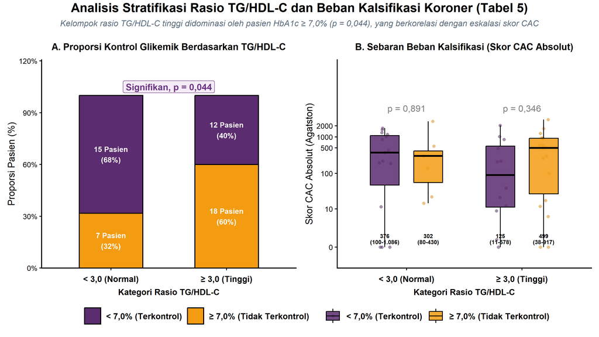

Gambar 25

```r
library(ggplot2)
library(dplyr)
library(tidyr)
library(scales)
library(patchwork)

# ==========================================
# 1. PERSIAPAN DATA KIRI (Proporsi Kontrol Glikemik vs Rasio TG/HDL-C)
# ==========================================
df_tbl5_prop <- df_clean %>%
  mutate(
    TG_HDL_Kat = factor(ifelse(TG_HDL_Ratio >= 3.0, "\u2265 3,0 (Tinggi)", "< 3,0 (Normal)"),
                        levels = c("< 3,0 (Normal)", "\u2265 3,0 (Tinggi)")),
    Kontrol_Glikemik = factor(ifelse(HbA1C >= 7.0, "\u2265 7,0% (Tidak Terkontrol)", "< 7,0% (Terkontrol)"),
                              levels = c("< 7,0% (Terkontrol)", "\u2265 7,0% (Tidak Terkontrol)"))
  ) %>%
  filter(!is.na(TG_HDL_Kat) & !is.na(Kontrol_Glikemik)) %>%
  group_by(TG_HDL_Kat, Kontrol_Glikemik) %>%
  summarise(Jumlah = n(), .groups = "drop") %>%
  group_by(TG_HDL_Kat) %>%
  mutate(
    Total_N = sum(Jumlah),
    Persentase = Jumlah / Total_N
  )

p_text_prop5 <- "Signifikan, p = 0,044"

# ==========================================
# 2. PERSIAPAN DATA KANAN (Sebaran Vertikal Skor CAC Absolut)
# ==========================================
df_tbl5_vert <- df_clean %>%
  mutate(
    TG_HDL_Kat = factor(ifelse(TG_HDL_Ratio >= 3.0, "\u2265 3,0 (Tinggi)", "< 3,0 (Normal)"),
                        levels = c("< 3,0 (Normal)", "\u2265 3,0 (Tinggi)")),
    Kontrol_Glikemik = factor(ifelse(HbA1C >= 7.0, "\u2265 7,0% (Tidak Terkontrol)", "< 7,0% (Terkontrol)"),
                              levels = c("< 7,0% (Terkontrol)", "\u2265 7,0% (Tidak Terkontrol)"))
  ) %>%
  filter(!is.na(TG_HDL_Kat) & !is.na(Kontrol_Glikemik) & !is.na(Global_CAC_score))

# Kalkulasi p-value komparasi skor CAC antar kontrol glikemik dalam kelompok TG/HDL-C
df_pval_vert5 <- df_tbl5_vert %>%
  group_by(TG_HDL_Kat) %>%
  summarise(p_val = suppressWarnings(wilcox.test(Global_CAC_score ~ Kontrol_Glikemik)$p.value), .groups = "drop") %>%
  mutate(
    p_text = paste0("p = ", format(round(p_val, 3), decimal.mark=",")),
    font_style = ifelse(p_val < 0.05, "bold", "plain"),
    color_text = ifelse(p_val < 0.05, "#C0392B", "#7F8C8D")
  )

# Kalkulasi Median dan Q1-Q3 untuk Skor CAC
df_med_vert5 <- df_tbl5_vert %>%
  group_by(TG_HDL_Kat, Kontrol_Glikemik) %>%
  summarise(
    Median = median(Global_CAC_score, na.rm=T),
    Q1 = quantile(Global_CAC_score, 0.25, na.rm=T),
    Q3 = quantile(Global_CAC_score, 0.75, na.rm=T),
    .groups="drop"
  ) %>%
  mutate(
    m = format(round(Median,0), big.mark=".", trim=T),
    q1 = format(round(Q1,0), big.mark=".", trim=T),
    q3 = format(round(Q3,0), big.mark=".", trim=T),
    label_med = paste0(m, "\n(", q1, "-", q3, ")")
  )

# ==========================================
# 3. MEMBANGUN PANEL KIRI (Proporsi)
# ==========================================
p_kiri5 <- ggplot(df_tbl5_prop, aes(x = TG_HDL_Kat, y = Persentase, fill = Kontrol_Glikemik)) +
  geom_col(position = "fill", color = "black", width = 0.55, linewidth = 1) +
  geom_text(aes(label = paste0(Jumlah, " Pasien\n(", percent(Persentase, accuracy = 1), ")")),
            position = position_fill(vjust = 0.5), color = "white", fontface = "bold", size = 5) +
  annotate("label", x = 1.5, y = 1.05, label = p_text_prop5, size = 6, fontface = "bold", color = "#6C3483", fill = "#F4ECF7", label.size = 1) +
  scale_fill_manual(values = c("< 7,0% (Terkontrol)" = "#5B2C6F", "\u2265 7,0% (Tidak Terkontrol)" = "#F39C12")) +
  scale_y_continuous(labels = percent_format(), expand = expansion(mult = c(0, 0.15))) +
  labs(title = "A. Proporsi Kontrol Glikemik Berdasarkan TG/HDL-C", x = "Kategori Rasio TG/HDL-C", y = "Proporsi Pasien (%)") +
  theme_classic(base_size = 18) +
  theme(
    legend.position = "none",
    axis.line = element_line(color = "black", linewidth = 1),
    axis.text.x = element_text(face = "bold", size = 16, color = "black", margin = margin(t = 10)),
    axis.text.y = element_text(size = 14, color = "black"),
    axis.title.x = element_text(face = "bold", size = 16, margin = margin(t = 10)),
    plot.title = element_text(face = "bold", hjust = 0.5, size = 18, margin = margin(b = 15))
  )

# ==========================================
# 4. MEMBANGUN PANEL KANAN (Sebaran Skor CAC Absolut)
# ==========================================
pd5 <- position_dodge(width = 0.75)
p_kanan5 <- ggplot(df_tbl5_vert, aes(x = TG_HDL_Kat, y = Global_CAC_score, fill = Kontrol_Glikemik)) +
  geom_point(aes(color = Kontrol_Glikemik), position = position_jitterdodge(jitter.width = 0.2, dodge.width = 0.75), alpha = 0.5, size = 2.5, shape = 16) +
  geom_boxplot(outlier.shape = NA, alpha = 0.85, color = "black", linewidth = 0.8, position = pd5, width = 0.5) +

  # P-value di atas
  geom_text(data = df_pval_vert5, aes(x = TG_HDL_Kat, y = 6000, label = p_text, fontface = font_style, color = color_text), inherit.aes = FALSE, size = 6) +
  scale_color_manual(values = c("< 7,0% (Terkontrol)" = "#4A235A", "\u2265 7,0% (Tidak Terkontrol)" = "#D68910")) +

  # Median di bagian bawah (di atas lantai 0)
  geom_text(data = df_med_vert5, aes(y = 0, label = label_med, group = Kontrol_Glikemik), position = pd5, vjust = -0.3, size = 3.8, fontface = "bold", color = "black", lineheight = 0.9) +

  scale_fill_manual(values = c("< 7,0% (Terkontrol)" = "#5B2C6F", "\u2265 7,0% (Tidak Terkontrol)" = "#F39C12")) +

  # Skala Log1p agar sebaran CAC absolut terbaca sempurna dari 0 hingga >2000
  scale_y_continuous(trans = "log1p", breaks = c(0, 10, 100, 500, 1000, 2000), expand = expansion(mult = c(0.15, 0.35))) +

  labs(title = "B. Sebaran Beban Kalsifikasi (Skor CAC Absolut)", x = "Kategori Rasio TG/HDL-C", y = "Skor CAC Absolut (Agatston)") +
  theme_classic(base_size = 18) +
  theme(
    legend.position = "none",
    axis.line = element_line(color = "black", linewidth = 1),
    axis.text.x = element_text(face = "bold", size = 16, color = "black", margin = margin(t = 10)),
    axis.text.y = element_text(size = 14, color = "black"),
    axis.title.x = element_text(face = "bold", size = 16, margin = margin(t = 10)),
    plot.title = element_text(face = "bold", hjust = 0.5, size = 18, margin = margin(b = 15))
  )

# ==========================================
# 5. MENGGABUNGKAN KEDUANYA (Patchwork 16:9)
# ==========================================
p_final5 <- p_kiri5 + p_kanan5 +
  plot_layout(ncol = 2, guides = "collect") +
  plot_annotation(
    title = "Analisis Stratifikasi Rasio TG/HDL-C dan Beban Kalsifikasi Koroner (Tabel 5)",
    subtitle = "Kelompok rasio TG/HDL-C tinggi didominasi oleh pasien HbA1c \u2265 7,0% (p = 0,044), yang berkorelasi dengan eskalasi skor CAC",
    theme = theme(
      plot.title = element_text(face = "bold", size = 24, hjust = 0.5, margin = margin(b = 10)),
      plot.subtitle = element_text(face = "italic", size = 16, color = "#5D6D7E", hjust = 0.5, margin = margin(b = 20))
    )
  ) &
  theme(
    legend.position = "bottom",
    legend.title = element_blank(),
    legend.text = element_text(face = "bold", size = 16),
    legend.key.size = unit(1.2, "cm")
  )

p_final5
ggsave("Grafik/Table5_Kombinasi_16x9_PPT.png", plot = p_final5, width = 16, height = 9, dpi = 300)
```

**Kode**

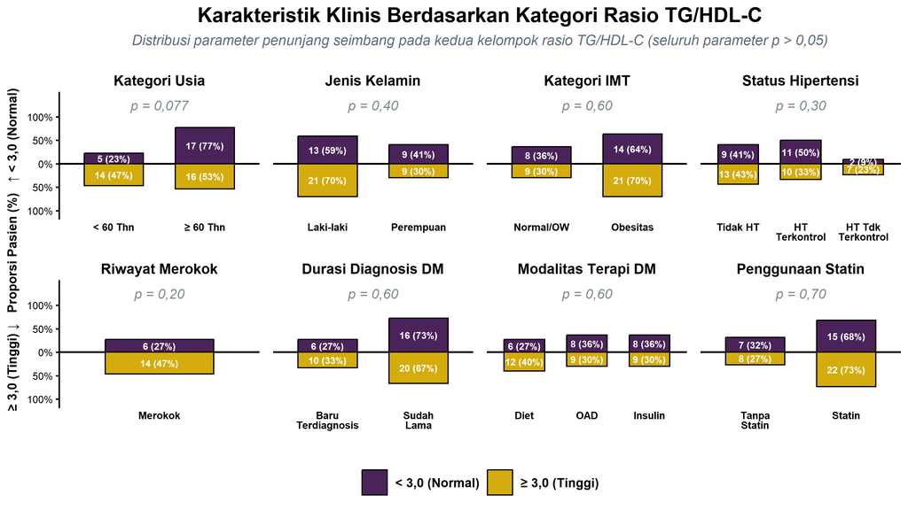

Gambar 26

```r
library(ggplot2)
library(dplyr)
library(tidyr)
library(scales)

# 1. Menyiapkan 7 Variabel Sesuai Tabel 5
df_cat_raw5 <- df_clean %>%
  mutate(
    TG_HDL_Kat = factor(ifelse(TG_HDL_Ratio >= 3.0, "\u2265 3,0 (Tinggi)", "< 3,0 (Normal)"),
                        levels = c("< 3,0 (Normal)", "\u2265 3,0 (Tinggi)")),
    `Kategori Usia` = factor(ifelse(Usia >= 60, "\u2265 60 Thn", "< 60 Thn"), levels = c("< 60 Thn", "\u2265 60 Thn")),
    `Jenis Kelamin` = factor(Gender, levels = c("L", "P"), labels = c("Laki-laki", "Perempuan")),
    `Kategori IMT` = factor(ifelse(IMT >= 25, "Obesitas", "Normal/OW"), levels = c("Normal/OW", "Obesitas")),
    `Status Hipertensi` = factor(case_when(
       grepl("Tidak ada", Hipertensi_Kat) ~ "Tidak HT",
       grepl("Tidak Terkontrol", Hipertensi_Kat) ~ "HT Tdk Terkontrol",
       TRUE ~ "HT Terkontrol"
    ), levels = c("Tidak HT", "HT Terkontrol", "HT Tdk Terkontrol")),
    `Riwayat Merokok` = factor(Merokok, levels = c("Tidak Merokok", "Merokok")),
    `Durasi Diagnosis DM` = factor(Riwayat_DM, levels = c("Baru Terdiagnosis", "Sudah Lama")),
    `Modalitas Terapi DM` = factor(Terapi_DM, levels = c("Tanpa Terapi/Diet", "OAD", "Insulin"), labels = c("Diet", "OAD", "Insulin")),
    `Penggunaan Statin` = factor(Statin, levels = c("No-Statin", "On-Statin"), labels = c("Tanpa Statin", "Statin"))
  ) %>%
  select(TG_HDL_Kat, `Kategori Usia`, `Jenis Kelamin`, `Kategori IMT`, `Status Hipertensi`,
         `Riwayat Merokok`, `Durasi Diagnosis DM`, `Modalitas Terapi DM`, `Penggunaan Statin`) %>%
  pivot_longer(cols = -TG_HDL_Kat, names_to = "Kategori", values_to = "Grup") %>%
  filter(!is.na(TG_HDL_Kat) & !is.na(Grup)) %>%
  mutate(Kategori = factor(Kategori, levels = c(
    "Kategori Usia", "Jenis Kelamin", "Kategori IMT", "Status Hipertensi",
    "Riwayat Merokok", "Durasi Diagnosis DM", "Modalitas Terapi DM", "Penggunaan Statin"
  )))

# 2. Nilai P-value Absolut sesuai Tabel 5
df_pvals5 <- df_cat_raw5 %>%
  group_by(Kategori) %>%
  summarise(
    x_pos = (n_distinct(Grup) + 1) / 2,
    .groups = "drop"
  ) %>%
  mutate(
    p_text = case_when(
      Kategori == "Kategori Usia" ~ "p = 0,077",
      Kategori == "Jenis Kelamin" ~ "p = 0,40",
      Kategori == "Kategori IMT" ~ "p = 0,60",
      Kategori == "Status Hipertensi" ~ "p = 0,30",
      Kategori == "Riwayat Merokok" ~ "p = 0,20",
      Kategori == "Durasi Diagnosis DM" ~ "p = 0,60",
      Kategori == "Modalitas Terapi DM" ~ "p = 0,60",
      Kategori == "Penggunaan Statin" ~ "p = 0,70",
      TRUE ~ "p = -"
    ),
    font_style = "italic"
  )

# 3. Proporsi Kolom (Dibagi N total kelompok TG/HDL: Normal=22, Tinggi=30)
df_vis5 <- df_cat_raw5 %>%
  group_by(Kategori, TG_HDL_Kat, Grup) %>%
  summarise(Jumlah = n(), .groups = "drop") %>%
  mutate(
    Total_N = ifelse(TG_HDL_Kat == "< 3,0 (Normal)", 22, 30),
    Persentase = Jumlah / Total_N,
    Persentase_Plot = ifelse(TG_HDL_Kat == "\u2265 3,0 (Tinggi)", -Persentase, Persentase),
    Label_Teks = ifelse(Persentase > 0.08, paste0(Jumlah, " (", round(Persentase * 100), "%)"), "")
  )

# 4. Membangun Diverging Bar Chart 8 Panel (2 Baris x 4 Kolom)
p_diverging_tbl5 <- ggplot(df_vis5, aes(x = Grup, y = Persentase_Plot, fill = TG_HDL_Kat)) +

  geom_hline(yintercept = 0, color = "black", linewidth = 1.2) +
  geom_col(color = "black", width = 0.65, linewidth = 0.8) +

  geom_text(aes(y = Persentase_Plot / 2, label = Label_Teks),
            color = "white", fontface = "bold", size = 4.2) +

  geom_text(data = df_pvals5, aes(x = x_pos, y = 1.25, label = p_text, fontface = font_style),
            size = 6, color = "#7F8C8D", inherit.aes = FALSE) +

  facet_wrap(~ Kategori, scales = "free_x", ncol = 4) +

  # Palet Warna Eksklusif Tabel 5: Deep Indigo & Golden Ochre
  scale_fill_manual(values = c("< 3,0 (Normal)" = "#4A235A", "\u2265 3,0 (Tinggi)" = "#D4AC0D")) +
  scale_x_discrete(labels = label_wrap(10)) +

  scale_y_continuous(labels = function(x) percent(abs(x), accuracy = 1),
                     limits = c(-1.05, 1.4), breaks = seq(-1, 1, by = 0.5)) +

  labs(
    title = "Karakteristik Klinis Berdasarkan Kategori Rasio TG/HDL-C",
    subtitle = "Distribusi parameter penunjang seimbang pada kedua kelompok rasio TG/HDL-C (seluruh parameter p > 0,05)",
    x = "",
    y = "\u2265 3,0 (Tinggi) \u2193   Proporsi Pasien (%)   \u2191 < 3,0 (Normal)"
  ) +

  theme_classic(base_size = 18) +
  theme(
    legend.position = "bottom",
    legend.title = element_blank(),
    legend.text = element_text(face = "bold", size = 16),
    legend.key.size = unit(1.2, "cm"),
    strip.background = element_blank(),
    strip.text = element_text(face = "bold", size = 18, color = "black"),
    axis.line.x = element_blank(),
    axis.ticks.x = element_blank(),
    axis.line.y = element_line(color = "black", linewidth = 1),
    axis.ticks.y = element_line(color = "black", linewidth = 1),
    axis.text.x = element_text(face = "bold", size = 13, color = "black", margin = margin(t = 5), lineheight = 0.8),
    axis.text.y = element_text(size = 13, color = "black"),
    axis.title.y = element_text(face = "bold", size = 16, margin = margin(r = 10)),
    panel.spacing = unit(1.2, "lines"),
    plot.title = element_text(face = "bold", hjust = 0.5, size = 26, margin = margin(b = 10)),
    plot.subtitle = element_text(face = "italic", hjust = 0.5, size = 18, color = "#5D6D7E", margin = margin(b = 25))
  )

p_diverging_tbl5
ggsave("Grafik/Table5_Karakteristik_NonSig_Diverging_PPT.png", plot = p_diverging_tbl5, width = 16, height = 9, dpi = 300)
```

**Kode**

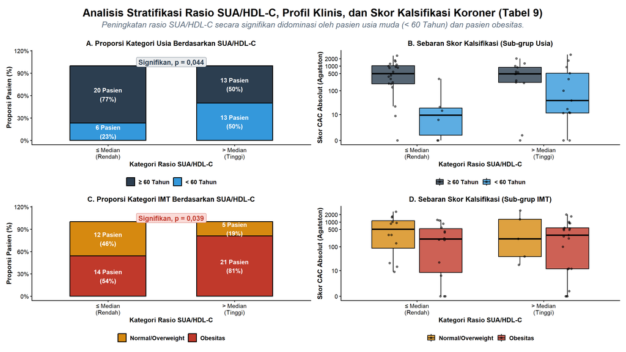

Gambar 27

```r
library(ggplot2)
library(dplyr)
library(tidyr)
library(patchwork)
library(scales)

# ==============================================================================
# 1. PERSIAPAN DATA UNTUK BAR PLOT (Sesuai persis dengan angka Tabel 9)
# ==============================================================================
# Data Kategori Usia (p = 0.044)
df_bar_usia <- data.frame(
  SUA_HDL = factor(rep(c("\u2264 Median\n(Rendah)", "> Median\n(Tinggi)"), each = 2),
                   levels = c("\u2264 Median\n(Rendah)", "> Median\n(Tinggi)")),
  Kategori = factor(rep(c("\u2265 60 Tahun", "< 60 Tahun"), 2),
                    levels = c("\u2265 60 Tahun", "< 60 Tahun")),
  Count = c(20, 6, 13, 13),
  Prop = c(77, 23, 50, 50)
)

# Data Kategori IMT (p = 0.039)
df_bar_imt <- data.frame(
  SUA_HDL = factor(rep(c("\u2264 Median\n(Rendah)", "> Median\n(Tinggi)"), each = 2),
                   levels = c("\u2264 Median\n(Rendah)", "> Median\n(Tinggi)")),
  Kategori = factor(rep(c("Normal/Overweight", "Obesitas"), 2),
                    levels = c("Normal/Overweight", "Obesitas")),
  Count = c(12, 14, 5, 21),
  Prop = c(46, 54, 19, 81)
)

# ==============================================================================
# 2. PERSIAPAN DATA UNTUK BOXPLOT DARI DATASET ASLI (df_clean)
# ==============================================================================
# Memastikan variabel kategori tersedia untuk plotting sebaran CAC
df_box <- df_clean %>%
  mutate(
    # Hitung Rasio SUA/HDL dan tentukan mediannya
    SUA_HDL_Ratio = `Asam-Urat` / HDL,
    SUA_HDL_Med = median(SUA_HDL_Ratio, na.rm = TRUE),
    SUA_HDL_Kat = factor(ifelse(SUA_HDL_Ratio <= SUA_HDL_Med,
                                "\u2264 Median\n(Rendah)", "> Median\n(Tinggi)"),
                         levels = c("\u2264 Median\n(Rendah)", "> Median\n(Tinggi)")),

    # Kategori Usia
    Usia_Kat = factor(ifelse(Usia < 60, "< 60 Tahun", "\u2265 60 Tahun"),
                      levels = c("\u2265 60 Tahun", "< 60 Tahun")),

    # Kategori IMT (Asumsi cutoff Obesitas Asia-Pasifik >= 25)
    IMT_Kat = factor(ifelse(IMT >= 25, "Obesitas", "Normal/Overweight"),
                     levels = c("Normal/Overweight", "Obesitas")),

    # Skor CAC untuk skala Log
    CAC_Plot = Global_CAC_score + 1
  ) %>% filter(!is.na(SUA_HDL_Kat))

# ==============================================================================
# 3. MEMBUAT GRAFIK INDIVIDUAL
# ==============================================================================

# Tema dasar agar konsisten
custom_theme <- theme_classic(base_size = 12) +
  theme(
    plot.title = element_text(face = "bold", size = 13, hjust = 0.5),
    axis.title = element_text(face = "bold"),
    axis.text = element_text(color = "black", size = 11),
    legend.position = "bottom",
    legend.title = element_blank(),
    legend.text = element_text(size = 11, face = "bold")
  )

# --- PANEL A: Bar Plot Usia ---
p_bar_usia <- ggplot(df_bar_usia, aes(x = SUA_HDL, y = Prop, fill = Kategori)) +
  geom_col(color = "black", width = 0.6, linewidth = 0.8) +
  geom_text(aes(label = sprintf("%d Pasien\n(%d%%)", Count, Prop)),
            position = position_stack(vjust = 0.5), color = "white", fontface = "bold", size = 4) +
  scale_fill_manual(values = c("\u2265 60 Tahun" = "#2C3E50", "< 60 Tahun" = "#3498DB")) +
  scale_y_continuous(labels = function(x) paste0(x, "%")) +
  annotate("label", x = 1.5, y = 105, label = "Signifikan, p = 0,044",
           color = "#2C3E50", fontface = "bold", fill = "#EAECEE", size = 4.5) +
  labs(title = "A. Proporsi Kategori Usia Berdasarkan SUA/HDL-C", x = "Kategori Rasio SUA/HDL-C", y = "Proporsi Pasien (%)") +
  coord_cartesian(ylim = c(0, 115)) +
  custom_theme

# --- PANEL B: Boxplot CAC Berdasarkan Usia ---
p_box_usia <- ggplot(df_box, aes(x = SUA_HDL_Kat, y = CAC_Plot, fill = Usia_Kat)) +
  geom_boxplot(alpha = 0.8, color = "black", linewidth = 0.7, outlier.shape = NA) +
  geom_point(position = position_jitterdodge(jitter.width = 0.15), size = 1.5, alpha = 0.5) +
  scale_fill_manual(values = c("\u2265 60 Tahun" = "#2C3E50", "< 60 Tahun" = "#3498DB")) +
  scale_y_continuous(trans = "log10", breaks = c(1, 11, 101, 501, 1001, 2001),
                     labels = c("0", "10", "100", "500", "1000", "2000")) +
  labs(title = "B. Sebaran Skor Kalsifikasi (Sub-grup Usia)", x = "Kategori Rasio SUA/HDL-C", y = "Skor CAC Absolut (Agatston)") +
  custom_theme

# --- PANEL C: Bar Plot IMT ---
p_bar_imt <- ggplot(df_bar_imt, aes(x = SUA_HDL, y = Prop, fill = Kategori)) +
  geom_col(color = "black", width = 0.6, linewidth = 0.8) +
  geom_text(aes(label = sprintf("%d Pasien\n(%d%%)", Count, Prop)),
            position = position_stack(vjust = 0.5), color = "white", fontface = "bold", size = 4) +
  scale_fill_manual(values = c("Normal/Overweight" = "#D68910", "Obesitas" = "#C0392B")) +
  scale_y_continuous(labels = function(x) paste0(x, "%")) +
  annotate("label", x = 1.5, y = 105, label = "Signifikan, p = 0,039",
           color = "#C0392B", fontface = "bold", fill = "#FADBD8", size = 4.5) +
  labs(title = "C. Proporsi Kategori IMT Berdasarkan SUA/HDL-C", x = "Kategori Rasio SUA/HDL-C", y = "Proporsi Pasien (%)") +
  coord_cartesian(ylim = c(0, 115)) +
  custom_theme

# --- PANEL D: Boxplot CAC Berdasarkan IMT ---
p_box_imt <- ggplot(df_box, aes(x = SUA_HDL_Kat, y = CAC_Plot, fill = IMT_Kat)) +
  geom_boxplot(alpha = 0.8, color = "black", linewidth = 0.7, outlier.shape = NA) +
  geom_point(position = position_jitterdodge(jitter.width = 0.15), size = 1.5, alpha = 0.5) +
  scale_fill_manual(values = c("Normal/Overweight" = "#D68910", "Obesitas" = "#C0392B")) +
  scale_y_continuous(trans = "log10", breaks = c(1, 11, 101, 501, 1001, 2001),
                     labels = c("0", "10", "100", "500", "1000", "2000")) +
  labs(title = "D. Sebaran Skor Kalsifikasi (Sub-grup IMT)", x = "Kategori Rasio SUA/HDL-C", y = "Skor CAC Absolut (Agatston)") +
  custom_theme

# ==============================================================================
# 4. PENGGABUNGAN GRID (PATCHWORK 16:9)
# ==============================================================================
layout_final <- (p_bar_usia | p_box_usia) / (p_bar_imt | p_box_imt) +
  plot_annotation(
    title = "Analisis Stratifikasi Rasio SUA/HDL-C, Profil Klinis, dan Skor Kalsifikasi Koroner (Tabel 9)",
    subtitle = "Peningkatan rasio SUA/HDL-C secara signifikan didominasi oleh pasien usia muda (< 60 Tahun) dan pasien obesitas.",
    theme = theme(
      plot.title = element_text(face = "bold", size = 20, hjust = 0.5, margin = margin(b = 5, t = 10)),
      plot.subtitle = element_text(face = "italic", size = 15, color = "#5D6D7E", hjust = 0.5, margin = margin(b = 15)),
      plot.background = element_rect(fill = "#FFFFFF", color = NA)
    )
  )

# Tampilkan plot
layout_final

ggsave("Grafik/Gambar_Stratifikasi_SUA_HDL_16x9.png", plot = layout_final, width = 16, height = 10, dpi = 300)
```

**Kode**

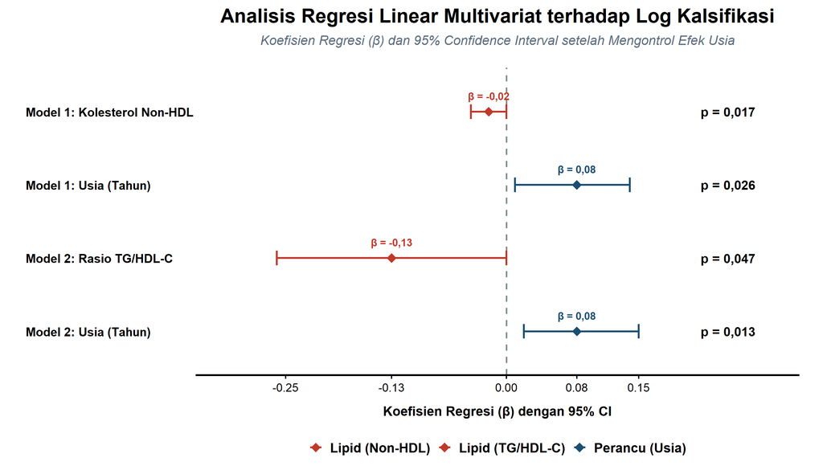

Gambar 28

```r
library(ggplot2)
library(dplyr)

# 1. Menyusun Data Hasil Tabel 6 ke dalam Dataframe R
df_forest <- data.frame(
  Model = c("Model 1: Kolesterol Non-HDL", "Model 1: Usia (Tahun)",
            "Model 2: Rasio TG/HDL-C", "Model 2: Usia (Tahun)"),
  Variabel = c("Kolesterol Non-HDL", "Usia", "Rasio TG/HDL-C", "Usia"),
  Beta = c(-0.02, 0.08, -0.13, 0.08),
  Lower = c(-0.04, 0.01, -0.26, 0.02),
  Upper = c(0.00, 0.14, 0.00, 0.15),
  # Format teks Beta agar menggunakan koma desimal
  Beta_Label = c("\u03B2 = -0,02", "\u03B2 = 0,08", "\u03B2 = -0,13", "\u03B2 = 0,08"),
  P_Value = c("p = 0,017", "p = 0,026", "p = 0,047", "p = 0,013"),
  Kategori_Prediktor = c("Lipid (Non-HDL)", "Perancu (Usia)", "Lipid (TG/HDL-C)", "Perancu (Usia)")
) %>%
  mutate(Model = factor(Model, levels = rev(c("Model 1: Kolesterol Non-HDL", "Model 1: Usia (Tahun)",
                                             "Model 2: Rasio TG/HDL-C", "Model 2: Usia (Tahun)"))))

# 2. Membangun Forest Plot dengan Nilai Beta di Titik Plot
p_forest <- ggplot(df_forest, aes(x = Beta, y = Model, color = Kategori_Prediktor)) +

  # Garis referensi vertikal nol (Null line)
  geom_vline(xintercept = 0, linetype = "dashed", color = "#7F8C8D", linewidth = 1) +

  # Garis Rentang 95% CI
  geom_errorbarh(aes(xmin = Lower, xmax = Upper), height = 0.2, linewidth = 1.2) +

  # Titik Estimasi Koefisien Beta
  geom_point(size = 5, shape = 18) +

  # KUNCI PERBAIKAN: Menambahkan label nilai Beta tepat di atas titik plot (vjust negatif agar melayang di atas titik)
  geom_text(aes(label = Beta_Label), vjust = -1.5, size = 4.5, fontface = "bold", show.legend = FALSE) +

  # Menambahkan Teks Nilai P di sebelah kanan grafik
  geom_text(aes(x = 0.22, label = P_Value), fontface = "bold", size = 5.5, color = "black", hjust = 0) +

  # Palet Warna: Crimson Red (Lipid) vs Deep Navy (Usia)
  scale_color_manual(values = c("Lipid (Non-HDL)" = "#C0392B", "Lipid (TG/HDL-C)" = "#C0392B", "Perancu (Usia)" = "#1B4F72")) +

  # Batas sumbu X sedikit diperlebar agar label di titik tidak terpotong atap
  scale_x_continuous(limits = c(-0.32, 0.30), breaks = c(-0.25, -0.13, 0.00, 0.08, 0.15)) +

  labs(
    title = "Analisis Regresi Linear Multivariat terhadap Log Kalsifikasi",
    subtitle = "Koefisien Regresi (\u03B2) dan 95% Confidence Interval setelah Mengontrol Efek Usia",
    x = "Koefisien Regresi (\u03B2) dengan 95% CI",
    y = ""
  ) +

  theme_classic(base_size = 18) +
  theme(
    legend.position = "bottom",
    legend.title = element_blank(),
    legend.text = element_text(face = "bold", size = 16),

    axis.line.y = element_blank(),
    axis.ticks.y = element_blank(),
    axis.line.x = element_line(color = "black", linewidth = 1.2),

    axis.text.y = element_text(face = "bold", size = 15, color = "black", hjust = 0),
    axis.text.x = element_text(size = 14, color = "black", margin = margin(t = 5)),
    axis.title.x = element_text(face = "bold", size = 16, margin = margin(t = 15)),

    plot.title = element_text(face = "bold", hjust = 0.5, size = 24, margin = margin(b = 10)),
    plot.subtitle = element_text(face = "italic", hjust = 0.5, size = 16, color = "#5D6D7E", margin = margin(b = 25)),
    plot.margin = margin(t = 10, r = 30, b = 10, l = 10)
  )

p_forest
ggsave("Grafik/Table6_ForestPlot_PPT.png", plot = p_forest, width = 14, height = 8, dpi = 300)
```

**Kode**

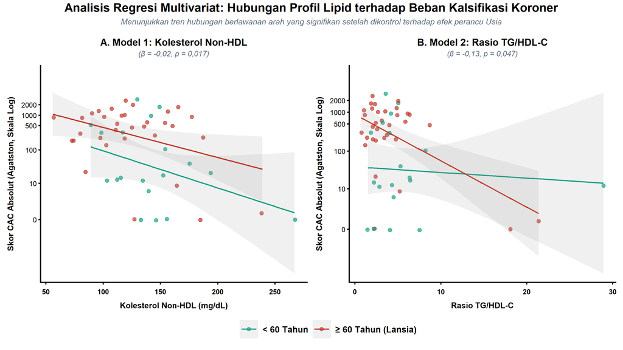

Gambar 29

```r
library(ggplot2)
library(dplyr)
library(scales)
library(patchwork)

# 1. Menyiapkan Data Dasar & Kategori Usia
df_base <- df_clean %>%
  mutate(
    Kelompok_Usia = factor(ifelse(Usia >= 60, "\u2265 60 Tahun (Lansia)", "< 60 Tahun"),
                           levels = c("< 60 Tahun", "\u2265 60 Tahun (Lansia)"))
  )

# ==========================================
# 2. MEMBANGUN PANEL KIRI (Model 1: Non-HDL)
# ==========================================
df_sc_kiri <- df_base %>% filter(!is.na(Non_HDL) & !is.na(Global_CAC_score) & !is.na(Kelompok_Usia))

p_kiri_sc <- ggplot(df_sc_kiri, aes(x = Non_HDL, y = Global_CAC_score, color = Kelompok_Usia)) +
  geom_point(alpha = 0.7, size = 3, position = position_jitter(width = 1, height = 0.05)) +
  geom_smooth(method = "lm", se = TRUE, linewidth = 1.2, alpha = 0.15) +
  scale_color_manual(values = c("< 60 Tahun" = "#16A085", "\u2265 60 Tahun (Lansia)" = "#C0392B")) +
  scale_y_continuous(trans = "log1p", breaks = c(0, 10, 100, 500, 1000, 2000),
                     expand = expansion(mult = c(0.05, 0.15))) +
  labs(
    title = "A. Model 1: Kolesterol Non-HDL",
    subtitle = "(\u03B2 = -0,02, p = 0,017)",
    x = "Kolesterol Non-HDL (mg/dL)",
    y = "Skor CAC Absolut (Agatston, Skala Log)"
  ) +
  theme_classic(base_size = 16) +
  theme(
    legend.position = "none", # Legenda disatukan di bawah secara global
    axis.line = element_line(color = "black", linewidth = 1.1),
    axis.ticks = element_line(color = "black", linewidth = 1.1),
    axis.text.x = element_text(face = "bold", size = 13, color = "black", margin = margin(t = 8)),
    axis.text.y = element_text(size = 13, color = "black"),
    axis.title.x = element_text(face = "bold", size = 15, margin = margin(t = 12)),
    axis.title.y = element_text(face = "bold", size = 15, margin = margin(r = 12)),
    plot.title = element_text(face = "bold", hjust = 0.5, size = 18, margin = margin(b = 5)),
    plot.subtitle = element_text(face = "italic", hjust = 0.5, size = 14, color = "#5D6D7E", margin = margin(b = 15))
  )

# ==========================================
# 3. MEMBANGUN PANEL KANAN (Model 2: Rasio TG/HDL-C)
# ==========================================
df_sc_kanan <- df_base %>% filter(!is.na(TG_HDL_Ratio) & !is.na(Global_CAC_score) & !is.na(Kelompok_Usia))

p_kanan_sc <- ggplot(df_sc_kanan, aes(x = TG_HDL_Ratio, y = Global_CAC_score, color = Kelompok_Usia)) +
  geom_point(alpha = 0.7, size = 3, position = position_jitter(width = 0.05, height = 0.05)) +
  geom_smooth(method = "lm", se = TRUE, linewidth = 1.2, alpha = 0.15) +
  scale_color_manual(values = c("< 60 Tahun" = "#16A085", "\u2265 60 Tahun (Lansia)" = "#C0392B")) +
  scale_y_continuous(trans = "log1p", breaks = c(0, 10, 100, 500, 1000, 2000),
                     expand = expansion(mult = c(0.05, 0.15))) +
  labs(
    title = "B. Model 2: Rasio TG/HDL-C",
    subtitle = "(\u03B2 = -0,13, p = 0,047)",
    x = "Rasio TG/HDL-C",
    y = "Skor CAC Absolut (Agatston, Skala Log)"
  ) +
  theme_classic(base_size = 16) +
  theme(
    legend.position = "none",
    axis.line = element_line(color = "black", linewidth = 1.1),
    axis.ticks = element_line(color = "black", linewidth = 1.1),
    axis.text.x = element_text(face = "bold", size = 13, color = "black", margin = margin(t = 8)),
    axis.text.y = element_text(size = 13, color = "black"),
    axis.title.x = element_text(face = "bold", size = 15, margin = margin(t = 12)),
    axis.title.y = element_text(face = "bold", size = 15, margin = margin(r = 12)),
    plot.title = element_text(face = "bold", hjust = 0.5, size = 18, margin = margin(b = 5)),
    plot.subtitle = element_text(face = "italic", hjust = 0.5, size = 14, color = "#5D6D7E", margin = margin(b = 15))
  )

# ==========================================
# 4. MENGGABUNGKAN KEDUANYA (Patchwork 16:9)
# ==========================================
p_final_scatter <- p_kiri_sc + p_kanan_sc +
  plot_layout(ncol = 2, guides = "collect") +
  plot_annotation(
    title = "Analisis Regresi Multivariat: Hubungan Profil Lipid terhadap Beban Kalsifikasi Koroner",
    subtitle = "Menunjukkan tren hubungan berlawanan arah yang signifikan setelah dikontrol terhadap efek perancu Usia",
    theme = theme(
      plot.title = element_text(face = "bold", size = 22, hjust = 0.5, margin = margin(b = 8)),
      plot.subtitle = element_text(face = "italic", size = 15, color = "#5D6D7E", hjust = 0.5, margin = margin(b = 15))
    )
  ) &
  theme(
    legend.position = "bottom",
    legend.title = element_blank(),
    legend.text = element_text(face = "bold", size = 16),
    legend.key.size = unit(1.2, "cm")
  )

p_final_scatter
ggsave("Grafik/Table6_Kombinasi_Scatter_16x9_PPT.png", plot = p_final_scatter, width = 16, height = 9, dpi = 300)
```

**Kode**

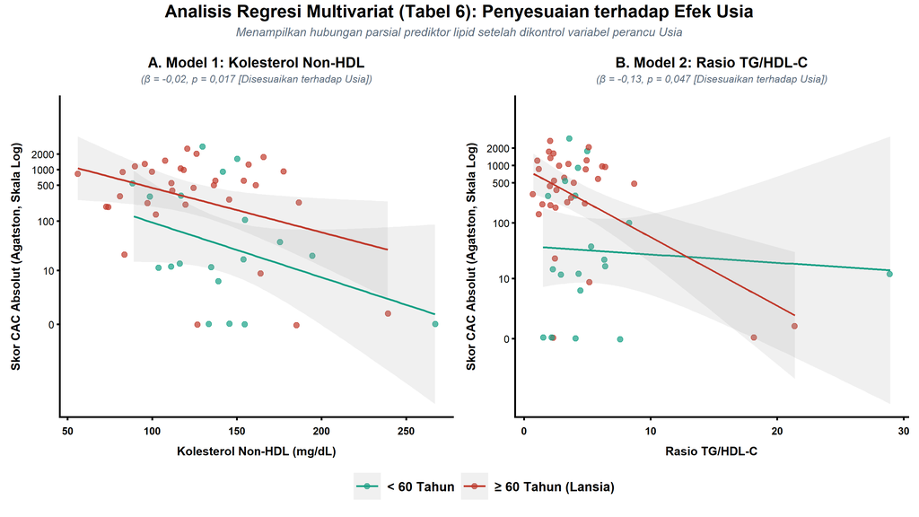

Gambar 30

```r
library(ggplot2)
library(dplyr)
library(scales)
library(patchwork)

# Memastikan model regresi multivariat tersimpan (Contoh penamaan objek model R Dokter)
# mod_nhdl <- lm(log1p(Global_CAC_score) ~ Non_HDL + Usia, data = df_clean)
# mod_tg   <- lm(log1p(Global_CAC_score) ~ TG_HDL_Ratio + Usia, data = df_clean)

df_base <- df_clean %>%
  mutate(
    Kelompok_Usia = factor(ifelse(Usia >= 60, "\u2265 60 Tahun (Lansia)", "< 60 Tahun"),
                           levels = c("< 60 Tahun", "\u2265 60 Tahun (Lansia)"))
  )

# ==========================================
# PANEL KIRI: Model 1 (Non-HDL + Usia)
# ==========================================
p_kiri_sc <- ggplot(df_base %>% filter(!is.na(Non_HDL) & !is.na(Global_CAC_score)),
                    aes(x = Non_HDL, y = Global_CAC_score, color = Kelompok_Usia)) +
  geom_point(alpha = 0.7, size = 3, position = position_jitter(width = 1, height = 0.05)) +
  # Menggunakan metode regresi linear terkontrol
  geom_smooth(method = "lm", se = TRUE, linewidth = 1.2, alpha = 0.15) +
  scale_color_manual(values = c("< 60 Tahun" = "#16A085", "\u2265 60 Tahun (Lansia)" = "#C0392B")) +
  scale_y_continuous(trans = "log1p", breaks = c(0, 10, 100, 500, 1000, 2000),
                     expand = expansion(mult = c(0.05, 0.15))) +
  labs(
    title = "A. Model 1: Kolesterol Non-HDL",
    subtitle = "(\u03B2 = -0,02, p = 0,017 [Disesuaikan terhadap Usia])",
    x = "Kolesterol Non-HDL (mg/dL)",
    y = "Skor CAC Absolut (Agatston, Skala Log)"
  ) +
  theme_classic(base_size = 16) +
  theme(
    legend.position = "none",
    axis.line = element_line(color = "black", linewidth = 1.1),
    axis.ticks = element_line(color = "black", linewidth = 1.1),
    axis.text.x = element_text(face = "bold", size = 13, color = "black", margin = margin(t = 8)),
    axis.text.y = element_text(size = 13, color = "black"),
    axis.title.x = element_text(face = "bold", size = 15, margin = margin(t = 12)),
    axis.title.y = element_text(face = "bold", size = 15, margin = margin(r = 12)),
    plot.title = element_text(face = "bold", hjust = 0.5, size = 18, margin = margin(b = 5)),
    plot.subtitle = element_text(face = "italic", hjust = 0.5, size = 13, color = "#5D6D7E", margin = margin(b = 15))
  )

# ==========================================
# PANEL KANAN: Model 2 (Rasio TG/HDL-C + Usia)
# ==========================================
p_kanan_sc <- ggplot(df_base %>% filter(!is.na(TG_HDL_Ratio) & !is.na(Global_CAC_score)),
                     aes(x = TG_HDL_Ratio, y = Global_CAC_score, color = Kelompok_Usia)) +
  geom_point(alpha = 0.7, size = 3, position = position_jitter(width = 0.05, height = 0.05)) +
  geom_smooth(method = "lm", se = TRUE, linewidth = 1.2, alpha = 0.15) +
  scale_color_manual(values = c("< 60 Tahun" = "#16A085", "\u2265 60 Tahun (Lansia)" = "#C0392B")) +
  scale_y_continuous(trans = "log1p", breaks = c(0, 10, 100, 500, 1000, 2000),
                     expand = expansion(mult = c(0.05, 0.15))) +
  labs(
    title = "B. Model 2: Rasio TG/HDL-C",
    subtitle = "(\u03B2 = -0,13, p = 0,047 [Disesuaikan terhadap Usia])",
    x = "Rasio TG/HDL-C",
    y = "Skor CAC Absolut (Agatston, Skala Log)"
  ) +
  theme_classic(base_size = 16) +
  theme(
    legend.position = "none",
    axis.line = element_line(color = "black", linewidth = 1.1),
    axis.ticks = element_line(color = "black", linewidth = 1.1),
    axis.text.x = element_text(face = "bold", size = 13, color = "black", margin = margin(t = 8)),
    axis.text.y = element_text(size = 13, color = "black"),
    axis.title.x = element_text(face = "bold", size = 15, margin = margin(t = 12)),
    axis.title.y = element_text(face = "bold", size = 15, margin = margin(r = 12)),
    plot.title = element_text(face = "bold", hjust = 0.5, size = 18, margin = margin(b = 5)),
    plot.subtitle = element_text(face = "italic", hjust = 0.5, size = 13, color = "#5D6D7E", margin = margin(b = 15))
  )

# ==========================================
# PENGGABUNGAN AKHIR (16:9 Patchwork)
# ==========================================
p_final_scatter_adjusted <- p_kiri_sc + p_kanan_sc +
  plot_layout(ncol = 2, guides = "collect") +
  plot_annotation(
    title = "Analisis Regresi Multivariat (Tabel 6): Penyesuaian terhadap Efek Usia",
    subtitle = "Menampilkan hubungan parsial prediktor lipid setelah dikontrol variabel perancu Usia",
    theme = theme(
      plot.title = element_text(face = "bold", size = 22, hjust = 0.5, margin = margin(b = 8)),
      plot.subtitle = element_text(face = "italic", size = 15, color = "#5D6D7E", hjust = 0.5, margin = margin(b = 15))
    )
  ) &
  theme(
    legend.position = "bottom",
    legend.title = element_blank(),
    legend.text = element_text(face = "bold", size = 16),
    legend.key.size = unit(1.2, "cm")
  )

p_final_scatter_adjusted
ggsave("Grafik/Table6_Kombinasi_Scatter_Adjusted_16x9_PPT.png", plot = p_final_scatter_adjusted, width = 16, height = 9, dpi = 300)
```

**Kode**

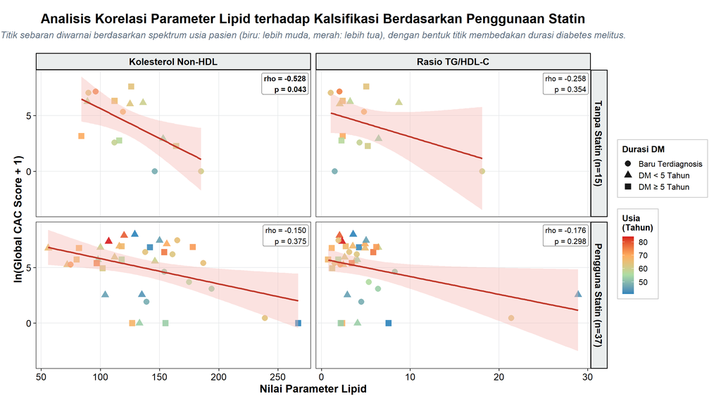

Gambar 31. Analisis korelasi kolesterol non-HDL dan Rasio TG/HDL-C terhadap kalsifikasi berdasarkan penggunaan Statin. Titik sebaran diwarnai berdasarkan usia pasien (spektrum biru untuk usia lebih muda, hingga merah untuk usia lebih tua), sementara bentuk titik membedakan durasi diabetes mellitus.

```r
library(ggplot2)
library(dplyr)
library(tidyr)

# 1. Menyiapkan data untuk facet (Durasi DM Kat)
df_strat <- df_clean %>%
  mutate(
    Durasi_DM_Kat = case_when(
      Durasi_DM_Bulan == 0 ~ "Baru Terdiagnosis",
      Durasi_DM_Bulan > 0 & Durasi_DM_Bulan < 60 ~ "DM < 5 Tahun",
      Durasi_DM_Bulan >= 60 ~ "DM \u2265 5 Tahun",
      TRUE ~ NA_character_
    ),
    Durasi_DM_Kat = factor(Durasi_DM_Kat, levels = c("Baru Terdiagnosis", "DM < 5 Tahun", "DM \u2265 5 Tahun"))
  ) %>%
  select(log_CAC, Statin, Non_HDL, TG_HDL_Ratio, Usia, Durasi_DM_Kat) %>%
  mutate(
    Statin = factor(Statin, levels = c("No-Statin", "On-Statin"), labels = c("Tanpa Statin (n=15)", "Pengguna Statin (n=37)")),
    `Kolesterol Non-HDL` = Non_HDL,
    `Rasio TG/HDL-C` = TG_HDL_Ratio
  ) %>%
  select(-Non_HDL, -TG_HDL_Ratio) %>%
  pivot_longer(cols = c(`Kolesterol Non-HDL`, `Rasio TG/HDL-C`), names_to = "Variable", values_to = "Value") %>%
  mutate(Variable = factor(Variable, levels = c("Kolesterol Non-HDL", "Rasio TG/HDL-C")))

# 2. Menghitung statistik untuk text label (Spearman)
df_strat_stats <- df_strat %>%
  filter(!is.na(Value) & !is.na(log_CAC)) %>%
  group_by(Variable, Statin) %>%
  summarise(
    rho = suppressWarnings(cor(Value, log_CAC, method = "spearman")),
    p_val = suppressWarnings(cor.test(Value, log_CAC, method = "spearman", exact = FALSE)$p.value),
    .groups = "drop"
  ) %>%
  mutate(
    p_text = ifelse(p_val < 0.001, "< 0.001", sprintf("= %.3f", p_val)),
    label_text = sprintf("rho = %.3f\np %s", rho, p_text),
    font_style = ifelse(p_val < 0.05, "bold", "plain")
  )

# 3. Membuat Plot Stratifikasi dengan Title & Subtitle Lengkap
p_strat <- ggplot(df_strat, aes(x = Value, y = log_CAC)) +

  geom_point(aes(color = Usia, shape = Durasi_DM_Kat), size = 3.8, alpha = 0.9) +

  scale_color_gradientn(
    colors = c("#2b83ba", "#abdda4", "#fdae61", "#d7191c"),
    name = "Usia\n(Tahun)"
  ) +

  scale_shape_manual(
    values = c(16, 17, 15),
    name = "Durasi DM"
  ) +

  geom_smooth(method = "lm", se = TRUE, color = "#c0392b", fill = "#f5b7b1", linewidth = 1.2) +

  geom_label(data = df_strat_stats, aes(x = Inf, y = Inf, label = label_text, fontface = font_style),
             hjust = 1.05, vjust = 1.15, size = 4, color = "black",
             fill = alpha("#ffffff", 0.85), label.size = 0.3, inherit.aes = FALSE) +

  facet_grid(Statin ~ Variable, scales = "free_x") +

  # PENAMBAHAN TITLE & SUBTITLE BERDASARKAN CAPTION
  labs(
    title = "Analisis Korelasi Parameter Lipid terhadap Kalsifikasi Berdasarkan Penggunaan Statin",
    subtitle = "Titik sebaran diwarnai berdasarkan spektrum usia pasien (biru: lebih muda, merah: lebih tua), dengan bentuk titik membedakan durasi diabetes melitus.",
    x = "Nilai Parameter Lipid",
    y = "ln(Global CAC Score + 1)"
  ) +

  theme_bw(base_size = 15) +
  theme(
    # Pengaturan Judul & Subjudul agar simetris dan elegan di layar 16:9
    plot.title = element_text(face = "bold", size = 20, hjust = 0.5, margin = margin(b = 8)),
    plot.subtitle = element_text(face = "italic", size = 14, color = "#5D6D7E", hjust = 0.5, margin = margin(b = 20)),

    strip.background = element_rect(fill = "#EAEDED", color = "black", linewidth = 1),
    strip.text = element_text(face = "bold", size = 14, color = "black"),

    panel.grid.minor = element_blank(),
    panel.grid.major = element_line(color = "#E5E7E9", linewidth = 0.5),

    axis.title = element_text(face = "bold", size = 16),
    axis.text = element_text(size = 14, color = "black"),

    legend.position = "right",
    legend.title = element_text(face = "bold", size = 13),
    legend.text = element_text(size = 12),
    legend.box = "vertical",
    legend.spacing.y = unit(0.6, "cm"),
    legend.background = element_rect(fill = alpha("white", 0.9), color = "gray80"),

    plot.margin = margin(t = 20, r = 20, b = 20, l = 20)
  )

p_strat
ggsave("Grafik/Gambar1_Stratifikasi_Statin_16x9.png", plot = p_strat, width = 15, height = 8.5, dpi = 300)
```

**Kode**

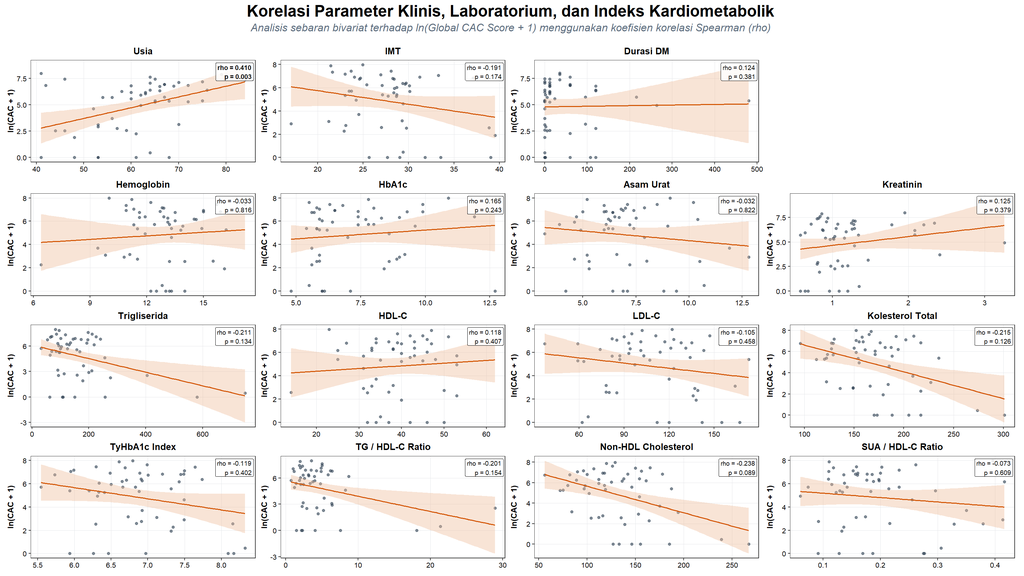

Gambar 32

```r
library(ggplot2)
library(tidyr)
library(dplyr)
library(patchwork)

# 1. Menyiapkan Data dan Variabel
df_prep <- df_clean %>%
  mutate(
    log_CAC = log(Global_CAC_score + 1),
    Usia = Usia,
    IMT = IMT,
    `Durasi DM` = if("Durasi_DM_Bulan" %in% names(.)) Durasi_DM_Bulan else if("Durasi_DM" %in% names(.)) Durasi_DM else 0,
    Hemoglobin = if("Hemoglobin" %in% names(.)) Hemoglobin else if("Hb" %in% names(.)) Hb else NA_real_,
    HbA1C = HbA1C,
    `Asam Urat` = if("Asam-Urat" %in% names(.)) `Asam-Urat` else Asam_Urat,
    Kreatinin = if("Kreatinin" %in% names(.)) Kreatinin else Kreatinin,
    Trigliserida = Trigliserida,
    `HDL-C` = HDL,
    `LDL-C` = LDL,
    `Kolesterol Total` = if("Kolesterol-Total" %in% names(.)) `Kolesterol-Total` else (`Kolesterol-Total`),
    `TyHbA1c Index` = log(Trigliserida * HbA1C),
    `TG / HDL-C Ratio` = Trigliserida / HDL,
    `Non-HDL Cholesterol` = `Kolesterol Total` - HDL,
    `SUA / HDL-C Ratio` = `Asam Urat` / HDL
  )

# 2. Fungsi Pembuat Scatter Plot Individual yang Kompak untuk 4 Kolom
create_scatter_plot <- function(data, x_var, x_label) {
  df_sub <- data %>% select(log_CAC, x_val = !!sym(x_var)) %>% filter(!is.na(x_val) & !is.na(log_CAC))

  rho <- suppressWarnings(cor(df_sub$x_val, df_sub$log_CAC, method = "spearman"))
  p_val <- suppressWarnings(cor.test(df_sub$x_val, df_sub$log_CAC, method = "spearman", exact = FALSE)$p.value)

  p_text <- ifelse(p_val < 0.001, "< 0.001", sprintf("= %.3f", p_val))
  label_text <- sprintf("rho = %.3f\np %s", rho, p_text)
  font_style <- ifelse(p_val < 0.05, "bold", "plain")

  stat_df <- data.frame(label_text = label_text, font_style = font_style)

  ggplot(data, aes(x = !!sym(x_var), y = log_CAC)) +
    geom_point(size = 1.2, alpha = 0.6, color = "#2c3e50") +
    geom_smooth(method = "lm", se = TRUE, color = "#d35400", fill = "#edbb99", linewidth = 0.6) +
    geom_label(data = stat_df, aes(x = Inf, y = Inf, label = label_text, fontface = font_style),
               hjust = 1.05, vjust = 1.15, size = 2.5, color = "black",
               fill = alpha("#ffffff", 0.85), label.size = 0.15, inherit.aes = FALSE) +
    labs(title = x_label, x = NULL, y = "ln(CAC + 1)") +
    theme_bw(base_size = 10) +
    theme(
      plot.title = element_text(face = "bold", size = 10, hjust = 0.5, color = "black"),
      panel.grid.minor = element_blank(),
      panel.grid.major = element_line(color = "#E5E7E9", linewidth = 0.3),
      axis.text = element_text(size = 8, color = "black"),
      axis.title = element_text(size = 9, face = "bold"),
      plot.margin = margin(t = 3, r = 3, b = 3, l = 3)
    )
}

# 3. Membuat List Plot dengan Menyisipkan plot_spacer() di Posisi ke-4
plots <- list(
  create_scatter_plot(df_prep, "Usia", "Usia"),
  create_scatter_plot(df_prep, "IMT", "IMT"),
  create_scatter_plot(df_prep, "Durasi DM", "Durasi DM"),
  plot_spacer(), # <--- Mengosongkan slot ke-4 di baris pertama

  create_scatter_plot(df_prep, "Hemoglobin", "Hemoglobin"),
  create_scatter_plot(df_prep, "HbA1C", "HbA1c"),
  create_scatter_plot(df_prep, "Asam Urat", "Asam Urat"),
  create_scatter_plot(df_prep, "Kreatinin", "Kreatinin"),

  create_scatter_plot(df_prep, "Trigliserida", "Trigliserida"),
  create_scatter_plot(df_prep, "HDL-C", "HDL-C"),
  create_scatter_plot(df_prep, "LDL-C", "LDL-C"),
  create_scatter_plot(df_prep, "Kolesterol Total", "Kolesterol Total"),

  create_scatter_plot(df_prep, "TyHbA1c Index", "TyHbA1c Index"),
  create_scatter_plot(df_prep, "TG / HDL-C Ratio", "TG / HDL-C Ratio"),
  create_scatter_plot(df_prep, "Non-HDL Cholesterol", "Non-HDL Cholesterol"),
  create_scatter_plot(df_prep, "SUA / HDL-C Ratio", "SUA / HDL-C Ratio")
)

# 4. Membungkus dengan ncol = 4 secara bersih
grid_layout <- wrap_plots(plots, ncol = 4) +
  plot_annotation(
    title = "Korelasi Parameter Klinis, Laboratorium, dan Indeks Kardiometabolik",
    subtitle = "Analisis sebaran bivariat terhadap ln(Global CAC Score + 1) menggunakan koefisien korelasi Spearman (rho)",
    theme = theme(
      plot.title = element_text(face = "bold", size = 18, hjust = 0.5, margin = margin(b = 4)),
      plot.subtitle = element_text(face = "italic", size = 12, color = "#5D6D7E", hjust = 0.5, margin = margin(b = 10)),
      plot.margin = margin(t = 5, r = 5, b = 5, l = 5)
    )
  )

grid_layout

ggsave("Grafik/Gambar3_Korelasi_CustomGrid_16x9.png", plot = grid_layout, width = 16, height = 9, dpi = 300)
```

**Kode**